# Polysubstance and tr. completion

Analyze the association between polysubstance at admission and tr. compleiton longitudinally along treatments, accounting for irregular observations.

Author

Andrés González Santa Cruz

Published

# Setup

```r
rm(list = ls())
folder_path <- ifelse(dir.exists("E:/Mi unidad/Alvacast/SISTRAT 2022 (github)/_proposal_grant/2023/"),
                      "E:/Mi unidad/Alvacast/SISTRAT 2022 (github)/_proposal_grant/2023/",
                      "C:/Users/CISS Fondecyt/Mi unidad/Alvacast/SISTRAT 2022 (github)/_proposal_grant/2023/")
load(paste0(folder_path,"an_grant_23_24_3.RData"))
```

# Packages

```r
system("fc-cache -f -v")
```

```
[1] 0
```

```r
pacman::p_unlock(lib.loc = .libPaths()) #para no tener problemas reinstalando paquetes


if (getRversion() != "4.1.2") { stop("Requires R version 4.1.2. Actual: ", getRversion()) }


if(!require(geepack)){install.packages("geepack");library(geepack)}
if(!require(geeM)){install.packages("geeM");library(geeM)}
if(!require(tidyverse)){install.packages("tidyverse");library(tidyverse)}
if(!require(MASS)){install.packages("MASS");library(MASS)}
if(!require(geeasy)){install.packages("geeasy");library(geeasy)}
if(!require(MuMIn)){remotes::install_version("MuMIn", "1.46.0");library(MuMIn)}
if(!require(tableone)){install.packages("tableone");library(tableone)}
if(!require(knitr)){install.packages("knitr");library(knitr)}
if(!require(emmeans)){install.packages("emmeans");library(emmeans)}
if(!require(biostat3)){install.packages("biostat3");library(biostat3)}
if(!require(rms)){install.packages("rms");library(rms)}
if(!require(meta)){install.packages("meta");library(meta)}
try(if(!require(dmetar)){install.packages("dmetar");library(dmetar)})
```

[output not shown]

```r
if(!require(metafor)){install.packages("metafor");library(metafor)}
try(if(!require(extrafont)){install.packages("extrafont");library(extrafont)})
try(if(!require(showtext)){install.packages("showtext");library(showtext)})

try(extrafont::font_import(pattern = "Times New Roman", prompt = FALSE))
```

```
Error in data.frame(fontfile = ttfiles, FontName = "", stringsAsFactors = FALSE) :
  arguments imply differing number of rows: 0, 1
```

```r
extrafont::loadfonts(device="win")
# Agregar la ruta a la fuente "Times New Roman"
font_add("Times New Roman", "C:/Windows/Fonts/times.ttf")

# Habilitar showtext para gráficos
showtext::showtext_auto()

#https://gist.github.com/avallecam/56af06f46e5544c3af0f46344df20989
#https://stackoverflow.com/questions/49089476/any-updates-to-model-negative-binomial-distribution-data-with-gee-in-r
#https://www.rdocumentation.org/packages/geepack/versions/1.3.4/topics/geese
#https://stackoverflow.com/questions/13946540/negative-binomial-in-gee?rq=1


#:#:#:#:#:#:#:#:#:#:#:#:#:#:#:#:#:#:#:#:#:#:#:#:#:#:#:#:#:#:#:#:#:#:#:#:#:#:#:#:#:#:#:#:#:#:#:#:#:#:#:#:#:#:#:
#:#:#:#:#:#:#:#:#:#:#:#:#:#:#:#:#:#:#:#:#:#:#:#:#:#:#:#:#:#:#:#:#:#:#:#:#:#:#:#:#:#:#:#:#:#:#:#:#:#:#:#:#:#:#:

summary2.geem <- function(object, exponentiate = FALSE, digits = 2, ...) {
  if (!is.list(object) || !"beta" %in% names(object)) {
    stop("Invalid object: Expected a model object with beta coefficients.")
  }

  # Initialize coefficients matrix
  Coefs <- matrix(NA, nrow = length(object$beta), ncol = 8)
  rownames(Coefs) <- object$coefnames
  colnames(Coefs) <- c("Term", "Estimates", "Model SE", "Robust SE", "Wald", "CI.lower", "CI.upper", "p.value")

  Coefs[, "Estimates"] <- object$beta

  # Handling the variance calculations
  naive <- is.null(object$var) || is.character(object$var) || any(diag(object$var) < 0)
  if (naive) {
    warning("Robust variance estimate not available or invalid. Using model-based SE.")
    Coefs[, "Robust SE"] <- sqrt(diag(object$naiv.var))
  } else {
    Coefs[, "Robust SE"] <- sqrt(diag(object$var))
  }

  Coefs[, "Model SE"] <- sqrt(diag(object$naiv.var))  # Model-based SE

  # Calculate Wald statistics
  Coefs[, "Wald"] <- Coefs[, "Estimates"] / Coefs[, "Robust SE"]

  # 95% CI calculations
  z_value <- qnorm((1 + 0.95) / 2)
  Coefs[, "CI.lower"] <- Coefs[, "Estimates"] - z_value * Coefs[, "Robust SE"]
  Coefs[, "CI.upper"] <- Coefs[, "Estimates"] + z_value * Coefs[, "Robust SE"]

  # P-value calculation
  Coefs[, "p.value"] <- round(2 * pnorm(-abs(Coefs[, "Wald"])), digits = 4)

  # Exponentiate estimates and CIs if specified
  if (exponentiate) {
    Coefs[, c("Estimates", "CI.lower", "CI.upper")] <- exp(Coefs[, c("Estimates", "CI.lower", "CI.upper")])
  }

  # Round numerical output
  decimal_format <- sprintf("%%1.%df", digits)

  Coefs[, c("Estimates", "Model SE", "Robust SE", "Wald", "CI.lower", "CI.upper")] <- round(Coefs[, c("Estimates", "Model SE", "Robust SE", "Wald", "CI.lower", "CI.upper")], digits = digits)
  Coefs[, c("Estimates", "Model SE", "Robust SE", "Wald", "CI.lower", "CI.upper")] <- sapply(Coefs[, c("Estimates", "Model SE", "Robust SE", "Wald", "CI.lower", "CI.upper")], function(col) {
    as.character(sprintf(decimal_format, as.numeric(col)))
  })
  # Convert matrix to data frame and keep row names
  result_df <- as.data.frame(Coefs)
  result_df[, "Term"] <- rownames(Coefs)
  row.names(result_df) <- NULL
  return(result_df)
}

#:#:#:#:#:#:#:#:#:#:#:#:#:#:#:#:#:#:#:#:#:#:#:#:#:#:#:#:#:#:#:#:#:#:#:#:#:#:#:#:#:#:#:#:#:#:#:#:#:#:#:#:#:#:#:
#:#:#:#:#:#:#:#:#:#:#:#:#:#:#:#:#:#:#:#:#:#:#:#:#:#:#:#:#:#:#:#:#:#:#:#:#:#:#:#:#:#:#:#:#:#:#:#:#:#:#:#:#:#:#:

tidy_geese_model <- function(geese_model, conf.level = 0.95) {
  # Extract coefficients and their names
  coefficients <- geese_model$beta
  coefficient_names <- names(coefficients)

  # Extract variance of beta coefficients and compute standard errors
  variance_beta <- geese_model$vbeta
  std_errors <- sqrt(diag(variance_beta))

  # Calculate z-values and p-values
  z_values <- coefficients / std_errors
  p_values <- 2 * pnorm(-abs(z_values), lower.tail = TRUE)

  # Calculate confidence intervals
  alpha <- 1 - conf.level
  z <- qnorm(1 - alpha / 2)
  lower_ci <- coefficients - z * std_errors
  upper_ci <- coefficients + z * std_errors

  # Exponentiate coefficients and confidence intervals for odds ratios
  exp_coefficients <- exp(coefficients)
  exp_lower_ci <- exp(lower_ci)
  exp_upper_ci <- exp(upper_ci)

  # Create a tidy data frame
  tidy_data <- tibble::tibble(
    Term = coefficient_names,
    Estimate = exp_coefficients,
    Std.Error = std_errors,
    z.value = z_values,
    p.value = p_values,
    CI.Lower = exp_lower_ci,
    CI.Upper = exp_upper_ci
  ) %>% dplyr::mutate_at(c("Estimate", "Std.Error", "z.value", "CI.Lower","CI.Upper"),~sprintf("%1.2f",.))%>% dplyr::mutate_at(c("p.value"),~sprintf("%1.4f",.))

  return(tidy_data)
}

options(knitr.kable.NA = '')


#:#:#:#:#:#:#:#:#:#:#:#:#:#:#:#:#:#:#:#:#:#:#:#:#:#:#:#:#:#:#:#:#:#:#:#:#:#:#:#:#:#:#:#:#:#:#:#:#:#:#:#:#:#:#:
#:#:#:#:#:#:#:#:#:#:#:#:#:#:#:#:#:#:#:#:#:#:#:#:#:#:#:#:#:#:#:#:#:#:#:#:#:#:#:#:#:#:#:#:#:#:#:#:#:#:#:#:#:#:#:

knitr::knit_hooks$set(time_it = local({
  now <- NULL
  function(before, options) {
    if (before) {
      # record the current time before each chunk
      now <<- Sys.time()
    } else {
      # calculate the time difference after a chunk
      res <- ifelse(difftime(Sys.time(), now)>(60^2),difftime(Sys.time(), now)/(60^2),difftime(Sys.time(), now)/(60^1))
      # return a character string to show the time
      x<-ifelse(difftime(Sys.time(), now)>(60^2),paste("Time for this code chunk to run:", round(res,1), "hours"),paste("Time for this code chunk to run:", round(res,1), "minutes"))
      paste('<div class="message">', gsub('##', '\n', x),'</div>', sep = '\n')
    }
  }
}))
knitr::opts_chunk$set(time_it = TRUE)

#:#:#:#:#:#:#:#:#:#:#:#:#:#:#:#:#:#:#:#:#:#:#:#:#:#:#:#:#:#:#:#:#:#:#:#:#:#:#:#:#:#:#:#:#:#:#:#:#:#:#:#:#:#:#:
#:#:#:#:#:#:#:#:#:#:#:#:#:#:#:#:#:#:#:#:#:#:#:#:#:#:#:#:#:#:#:#:#:#:#:#:#:#:#:#:#:#:#:#:#:#:#:#:#:#:#:#:#:#:#:

format_cells <- function(df, rows ,cols, value = c("italics", "bold", "strikethrough")){

  # select the correct markup
  # one * for italics, two ** for bold
  map <- setNames(c("*", "**", "~~"), c("italics", "bold", "strikethrough"))
  markup <- map[value]

  for (r in rows){
    for(c in cols){

      # Make sure values are not factors
      df[[c]] <- as.character( df[[c]])

      # Update formatting
      df[r, c] <- ifelse(nchar(df[r, c])==0,"",paste0(markup, gsub(" ", "", df[r, c]), markup))
    }
  }

  return(df)
}
#To produce line breaks in messages and warnings
knitr::knit_hooks$set(
  error = function(x, options) {
    paste('\n\n<div class="alert alert-danger">',
          gsub('##', '\n', gsub('^##\ Error', '**Error**', x)),
          '</div>', sep = '\n')
  },
  warning = function(x, options) {
    paste('\n\n<div class="alert alert-warning">',
          gsub('##', '\n', gsub('^##\ Warning:', '**Warning**', x)),
          '</div>', sep = '\n')
  },
  message = function(x, options) {
    paste('<div class="message">',
          gsub('##', '\n', x),
          '</div>', sep = '\n')
  }
)

#_#_#_#_#_#_#_#_#_#_#_#_#_
invisible("Function to format CreateTableOne into a database")

as.data.frame.TableOne <- function(x, ...) {capture.output(print(x,
                                                                 showAllLevels = TRUE, varLabels = T,...) -> x)
  y <- as.data.frame(x)
  y$characteristic <- dplyr::na_if(rownames(x), "")
  y <- y %>%
    fill(characteristic, .direction = "down") %>%
    dplyr::select(characteristic, everything())
  rownames(y) <- NULL
  y}
#_#_#_#_#_#_#_#_#_#_#_#_#_
# Austin, P. C. (2009). The Relative Ability of Different Propensity
# Score Methods to Balance Measured Covariates Between
# Treated and Untreated Subjects in Observational Studies. Medical
# Decision Making. https://doi.org/10.1177/0272989X09341755
smd_bin <- function(x,y){
  z <- x*(1-x)
  t <- y*(1-y)
  k <- sum(z,t)
  l <- k/2

  return((x-y)/sqrt(l))

}

#_#_#_#_#_#_#_#_#_#_#_#_#_
#_#_#_#_#_#_#_#_#_#_#_#_#_

counting_process_output<-
  function(object=NULL){
    broom::tidy(object$m, exponentiate=T, conf.int=T) %>%
      dplyr::mutate(across(c("estimate","std.error","robust.se","statistic","conf.low","conf.high"),~sprintf("%1.2f",.))) %>%
      dplyr::mutate(p.value= sprintf("%1.4f",p.value))
  }

#:#:#:#:#:#:#:#:#:#:#:#:#:#:#:#:#:#:#:#:#:#:#:#:#:#:#:#:#:#:#:#:#:#:#:#:#:#:#:#:#:#:#:#:#:#:#:#:#:#:#:#:#:#:#:
#:#:#:#:#:#:#:#:#:#:#:#:#:#:#:#:#:#:#:#:#:#:#:#:#:#:#:#:#:#:#:#:#:#:#:#:#:#:#:#:#:#:#:#:#:#:#:#:#:#:#:#:#:#:#:


if(.Platform$OS.type == "windows") withAutoprint({
  memory.size()
  memory.size(TRUE)
  memory.limit()
})
```

```
> memory.size()
[1] 7549.41
> memory.size(TRUE)
[1] 7573.75
> memory.limit()
[1] 32563
```

```r
memory.limit(size=56000)
```

```
[1] 56000
```

## 0.a. Descriptives

```r
invisible("2024-05-21: test different")
data_mine_miss_restr_proc2exp<-
data_mine_miss_restr_proc2 %>%
left_join(Base_fiscalia_v15f_grant_23_24[,c("hash_key","n_off_acq","n_off_vio","n_off_sud","n_off_oth", "n_prev_off")], by="hash_key") %>%
  {if (nrow(.) > nrow(data_mine_miss_restr_proc2)) {message("left join added rows"); .} else .} %>%
  dplyr::mutate(n_prev_off_bin= ifelse(n_prev_off>0,1,0)) %>%
  dplyr::mutate(
    susinidumrec_coc = ifelse(sus_ini_mod_mvv == "Cocaine hydrochloride", 1, 0),
    susinidumrec_pbc = ifelse(sus_ini_mod_mvv == "Cocaine paste", 1, 0),
    susinidumrec_mar = ifelse(sus_ini_mod_mvv == "Marijuana", 1, 0),
    susinidumrec_otr = ifelse(sus_ini_mod_mvv == "Other", 1, 0), #sus_principal_mod
    susprindumrec_coc = ifelse(sus_principal_mod == "Cocaine hydrochloride", 1, 0),
    susprindumrec_pbc = ifelse(sus_principal_mod == "Cocaine paste", 1, 0),
    susprindumrec_mar = ifelse(sus_principal_mod == "Marijuana", 1, 0),
    susprindumrec_otr = ifelse(sus_principal_mod == "Other", 1, 0) # "susprindum_coc", "susprindum_pbc", "susprindum_mar", "susprindum_oh
  )

#"susinidumrec_otr", "susinidum_coc", "susinidum_pbc", "susinidum_mar",

  #janitor::tabyl(n_off_acq)

#(Post-Treatment)
# n_post_off_acq
# n_post_off_vio
# n_post_off_sud
# n_post_off_ot
# n_post_off

invisible("To account for variability by treatment setting, we stratified the analysis by setting: basic ambulatory GP intensive ambulatory GP residential WO intensive ambulatory WO residential")
table(subset(Base_fiscalia_v15f_grant_23_24_long2_miss_proc_multtr, is_first_occurrence==1, select= "tipo_de_plan_2_mod"))
```

```
       basic ambulatory GP intensive ambulatory          GP residential
                   4360                    4998                    2178
WO intensive ambulatory          WO residential
                    745                    1036
```

```r
data_mine_miss_restr_proc2exp %>%
  group_by(hash_key) %>%
  summarise(min(fech_ing_num)) %>% nrow()
```

```
[1] 13317
```

```r
#13317
subset(data_mine_miss_restr_proc2 , is_first_occurrence==1) %>% nrow()
```

```
[1] 13317
```

```r
#13317
data_mine_miss_restr_proc2_baseline<-
  subset(data_mine_miss_restr_proc2exp , is_first_occurrence==1)


variables_vector <- c("tr_outcome", "policonsumo2", "comp_bpsc_y3_severe",
                      "less_90d_tr1", "log_dias_treat_imp_sin_na",
                      "edad_al_ing_1", "ano_nac_corr", "susinidumrec_coc",
                      "susinidumrec_pbc", "susinidumrec_mar", "susinidumrec_otr",
                      "psycom_dum_study", "psycom_dum_with", "freq_cons_dum_5day",
                      "cond_oc_dum_2inact", "cond_oc_dum_3unemp", "susprindumrec_coc",
                      "susprindumrec_pbc", "susprindumrec_mar", "susprindumrec_otr")#,"lag_comp_bpsc_y3_severe", "lag_less_90d_tr1", "log_lag_dias_treat_imp_sin_na", "lag_policonsumo2", "lag_tr_outcome")
```

Time for this code chunk to run: 0 minutes

```r
attr(data_mine_miss_restr_proc2_baseline$tr_outcome,"label") <- "Complete status of treatment (binary)"
attr(data_mine_miss_restr_proc2_baseline$tr_outcome,"label") <- "Complete status of treatment (binary)"
attr(data_mine_miss_restr_proc2_baseline$policonsumo2,"label") <- "Polysubstance use"
attr(data_mine_miss_restr_proc2_baseline$comp_bpsc_y3_severe,"label") <- "Biopsychosocial compromise (Severe)"
attr(data_mine_miss_restr_proc2_baseline$less_90d_tr1,"label") <- "Treatment duration (binary) (<90 days)"
attr(data_mine_miss_restr_proc2_baseline$log_dias_treat_imp_sin_na,"label") <- "Treatment duration (log-scaled days)"
attr(data_mine_miss_restr_proc2_baseline$edad_al_ing_1,"label") <- "Age at admission to treatment"
attr(data_mine_miss_restr_proc2_baseline$ano_nac_corr,"label") <- "Birth year"
attr(data_mine_miss_restr_proc2_baseline$susinidumrec_coc,"label") <- "Primary substance (initial diagnosis): cocaine hydrochloride"
attr(data_mine_miss_restr_proc2_baseline$susinidumrec_pbc,"label") <- "Primary substance (initial diagnosis): cocaine base paste"
attr(data_mine_miss_restr_proc2_baseline$susinidumrec_mar,"label") <- "Primary substance (initial diagnosis): marijuana"
attr(data_mine_miss_restr_proc2_baseline$susinidumrec_otr,"label") <- "Primary substance (initial diagnosis): other"
attr(data_mine_miss_restr_proc2_baseline$psycom_dum_study,"label") <- "Psychiatric comorbidity (ICD-10): In study"
attr(data_mine_miss_restr_proc2_baseline$psycom_dum_with,"label") <- "Psychiatric comorbidity (ICD-10): Diagnosed"
attr(data_mine_miss_restr_proc2_baseline$freq_cons_dum_5day,"label") <- "Daily frequence of primary substance use at admission"
attr(data_mine_miss_restr_proc2_baseline$cond_oc_dum_2inact,"label") <- "Occupational Status: Inactive"
attr(data_mine_miss_restr_proc2_baseline$cond_oc_dum_3unemp,"label") <- "Occupational Status: Unemployed"
attr(data_mine_miss_restr_proc2_baseline$susprindumrec_coc,"label") <- "Primary substance at admission to treatment: cocaine hydrochloride"
attr(data_mine_miss_restr_proc2_baseline$susprindumrec_pbc,"label") <- "Primary substance at admission to treatment: cocaine base paste"
attr(data_mine_miss_restr_proc2_baseline$susprindumrec_mar,"label") <- "Primary substance at admission to treatment: marijuana"
attr(data_mine_miss_restr_proc2_baseline$susprindumrec_otr,"label") <- "Primary substance at admission to treatment: other"
attr(data_mine_miss_restr_proc2_baseline$tipo_de_plan_2_mod,"label") <- "Treatment setting"

invisible("Table for imputed dataset with selected covariates")

library(tableone)

vars <- setdiff(c(variables_vector,"tipo_de_plan_2_mod"), "policonsumo2")
factorVars <- setdiff(variables_vector, c("policonsumo2", "edad_al_ing_1", "log_dias_treat_imp_sin_na", "ano_nac_corr"))

tableOne <- CreateTableOne(vars = vars, data = data_mine_miss_restr_proc2_baseline,
                           factorVars = factorVars, strata = "policonsumo2",
                           addOverall = TRUE,  # <-- This is the key addition
                           includeNA = TRUE,
                           test = TRUE) # Remove statistical tests for speed

print(tableOne, smd = TRUE) # Calculate SMD separately if needed
```

```
                                       Stratified by policonsumo2
                                        Overall         0
  n                                       13317            2383
  tr_outcome = 1 (%)                      10448 (78.5)     1833 (76.9)
  comp_bpsc_y3_severe = 1 (%)              5496 (41.3)      690 (29.0)
  less_90d_tr1 = 1 (%)                     3269 (24.5)      567 (23.8)
  log_dias_treat_imp_sin_na (mean (SD))    5.00 (1.07)     5.03 (0.93)
  edad_al_ing_1 (mean (SD))               33.80 (9.46)    38.29 (11.32)
  ano_nac_corr (mean (SD))              1979.02 (9.54)  1975.34 (11.02)
  susinidumrec_coc = 1 (%)                  627 ( 4.7)      108 ( 4.5)
  susinidumrec_pbc = 1 (%)                 1123 ( 8.4)      251 (10.5)
  susinidumrec_mar = 1 (%)                 4348 (32.6)      483 (20.3)
  susinidumrec_otr = 1 (%)                  295 ( 2.2)       57 ( 2.4)
  psycom_dum_study = 1 (%)                 2653 (19.9)      420 (17.6)
  psycom_dum_with = 1 (%)                  5836 (43.8)      986 (41.4)
  freq_cons_dum_5day = 1 (%)               6242 (46.9)     1013 (42.5)
  cond_oc_dum_2inact = 1 (%)               2410 (18.1)      468 (19.6)
  cond_oc_dum_3unemp = 1 (%)               5271 (39.6)      764 (32.1)
  susprindumrec_coc = 1 (%)                2370 (17.8)      292 (12.3)
  susprindumrec_pbc = 1 (%)                6898 (51.8)      902 (37.9)
  susprindumrec_mar = 1 (%)                 717 ( 5.4)       64 ( 2.7)
  susprindumrec_otr = 1 (%)                 188 ( 1.4)       43 ( 1.8)
  tipo_de_plan_2_mod (%)
     basic ambulatory                      4360 (32.7)     1040 (43.6)
     GP intensive ambulatory               4998 (37.5)      786 (33.0)
     GP residential                        2178 (16.4)      272 (11.4)
     WO intensive ambulatory                745 ( 5.6)      138 ( 5.8)
     WO residential                        1036 ( 7.8)      147 ( 6.2)
                                       Stratified by policonsumo2
                                        1               p      test SMD
  n                                       10934
  tr_outcome = 1 (%)                       8615 (78.8)   0.047       0.045
  comp_bpsc_y3_severe = 1 (%)              4806 (44.0)  <0.001       0.315
  less_90d_tr1 = 1 (%)                     2702 (24.7)   0.359       0.021
  log_dias_treat_imp_sin_na (mean (SD))    4.99 (1.10)   0.074       0.043
  edad_al_ing_1 (mean (SD))               32.82 (8.70)  <0.001       0.542
  ano_nac_corr (mean (SD))              1979.83 (8.99)  <0.001       0.446
  susinidumrec_coc = 1 (%)                  519 ( 4.7)   0.693       0.010
  susinidumrec_pbc = 1 (%)                  872 ( 8.0)  <0.001       0.088
  susinidumrec_mar = 1 (%)                 3865 (35.3)  <0.001       0.341
  susinidumrec_otr = 1 (%)                  238 ( 2.2)   0.569       0.014
  psycom_dum_study = 1 (%)                 2233 (20.4)   0.002       0.071
  psycom_dum_with = 1 (%)                  4850 (44.4)   0.008       0.060
  freq_cons_dum_5day = 1 (%)               5229 (47.8)  <0.001       0.107
  cond_oc_dum_2inact = 1 (%)               1942 (17.8)   0.033       0.048
  cond_oc_dum_3unemp = 1 (%)               4507 (41.2)  <0.001       0.191
  susprindumrec_coc = 1 (%)                2078 (19.0)  <0.001       0.187
  susprindumrec_pbc = 1 (%)                5996 (54.8)  <0.001       0.346
  susprindumrec_mar = 1 (%)                 653 ( 6.0)  <0.001       0.162
  susprindumrec_otr = 1 (%)                 145 ( 1.3)   0.090       0.039
  tipo_de_plan_2_mod (%)                                <0.001       0.298
     basic ambulatory                      3320 (30.4)
     GP intensive ambulatory               4212 (38.5)
     GP residential                        1906 (17.4)
     WO intensive ambulatory                607 ( 5.6)
     WO residential                         889 ( 8.1)
```

```r
smd_bin(
  prop.table(table(data_mine_miss_restr_proc2_baseline$susprindum_mar[data_mine_miss_restr_proc2_baseline$policonsumo==0]))[[2]],
  prop.table(table(data_mine_miss_restr_proc2_baseline$susprindum_mar[data_mine_miss_restr_proc2_baseline$policonsumo==1]))[[2]]
)
```

```
[1] -0.1630994
```

```r
smd_bin(
    prop.table(table(data_mine_miss_restr_proc2_baseline$comp_bpsc_y3_severe [data_mine_miss_restr_proc2_baseline$policonsumo==0]))[[2]],
    prop.table(table(data_mine_miss_restr_proc2_baseline$comp_bpsc_y3_severe [data_mine_miss_restr_proc2_baseline$policonsumo==1]))[[2]]
)
```

```
[1] -0.3140315
```

```r
folder_path <- ifelse(dir.exists("E:/Mi unidad/Alvacast/SISTRAT 2022 (github)/_proposal_grant/2023/"),
                      "E:/Mi unidad/Alvacast/SISTRAT 2022 (github)/_proposal_grant/2023/",
                      "C:/Users/CISS Fondecyt/Mi unidad/Alvacast/SISTRAT 2022 (github)/_proposal_grant/2023/")

as.data.frame.TableOne(tableOne, smd=T, nonnormal= T)%>%
    dplyr::mutate(char2=characteristic) %>%
    tidyr::fill(char2) %>%
    dplyr::select(char2,everything()) %>%
    dplyr::mutate(level=ifelse(is.na(level),"[Missing]",level)) %>%
    dplyr::mutate(char2=dplyr::case_when(characteristic=="NA"~NA_character_,TRUE~as.character(characteristic))) %>%
    format_cells(1, 1:length(names(.)), "bold") %>%
    dplyr::select(-1) %>%
    dplyr::mutate_all(~ str_replace_all(., pattern = "\\( ", replacement = "\\(")) %>%
    dplyr::mutate_all(~ str_trim(.)) %>%
    dplyr::select(characteristic, level, `0`, `1`, Overall, SMD)%>%
  {
    knitr::kable(.,size=10, format="html",caption= "Summary descriptives, Polysubstance(1) and no Polysubstance use (0)", escape=T)%>%
     kableExtra::kable_styling(bootstrap_options = c("striped", "hover"),font_size = 12) %>%
     kableExtra::scroll_box(width = "100%", height = "375px")
    write.table(.,paste0(folder_path,"baseline_psu_desc_subsamp_smd.csv"), dec=",", sep="\t")
  }
```

Time for this code chunk to run: 0 minutes

```r
  rbind.data.frame(
    cbind.data.frame(
      type= "PSU at admission and at least one dropout from the first admission",
    biostat3::survRate(Surv(cens_time, sum_tr_outcomes>0) ~ policonsumo2,
                       data= data_mine_miss_restr_proc2 %>%
                        dplyr::group_by(hash_key) %>%
                        dplyr::mutate(sum_tr_outcomes=sum(tr_outcome==1,na.rm=T)) %>%
                        dplyr::filter(is_first_occurrence==1) %>%
                        dplyr::ungroup())  %>%
      dplyr::mutate(across(c("rate", "lower", "upper"),~sprintf("%1.2f",.*1000)))
    ),
    cbind.data.frame(
      type= "PSU at admission and first dropout",
    biostat3::survRate(Surv(cens_time, tr_outcome==1) ~ policonsumo2,
                       data= data_mine_miss_restr_proc2 %>%
                        dplyr::group_by(hash_key) %>%
                        dplyr::mutate(sum_tr_outcomes=sum(tr_outcome==1,na.rm=T)) %>%
                        dplyr::filter(is_first_occurrence==1) %>%
                        dplyr::ungroup())  %>%
      dplyr::mutate(across(c("rate", "lower", "upper"),~sprintf("%1.2f",.*1000)))
    ),
    cbind.data.frame(
      type= "At least one treatment reporting PSU and at least one dropout from the first admission",
    biostat3::survRate(Surv(cens_time, sum_tr_outcomes>0) ~ policonsumo2,
                       data= data_mine_miss_restr_proc2 %>%
                        dplyr::group_by(hash_key) %>%
                        dplyr::mutate(sum_tr_outcomes=sum(tr_outcome==1,na.rm=T),
                                      sum_policonsumo2=sum(policonsumo2==1,na.rm=T)) %>%
                        dplyr::filter(is_first_occurrence==1) %>%
                        dplyr::ungroup() %>% dplyr::mutate(policonsumo2=ifelse(sum_policonsumo2>0,1,0)))  %>%
      dplyr::mutate(across(c("rate", "lower", "upper"),~sprintf("%1.2f",.*1000)))
    ),
    cbind.data.frame(
      type= "At least one treatment reporting PSU and first dropout",
    biostat3::survRate(Surv(cens_time, tr_outcome==1) ~ policonsumo2,
                       data= data_mine_miss_restr_proc2 %>%
                        dplyr::group_by(hash_key) %>%
                        dplyr::mutate(sum_tr_outcomes=sum(tr_outcome==1,na.rm=T),
                                      sum_policonsumo2=sum(policonsumo2==1,na.rm=T)) %>%
                        dplyr::filter(is_first_occurrence==1) %>%
                        dplyr::ungroup() %>% dplyr::mutate(policonsumo2=ifelse(sum_policonsumo2>0,1,0)))  %>%
      dplyr::mutate(across(c("rate", "lower", "upper"),~sprintf("%1.2f",.*1000)))
    )
  ) %>%
    dplyr::mutate(`IR (95% CI)`= paste0(rate, " (", lower,", ", upper,")")) %>%
    dplyr::select(-any_of(c("rate", "lower", "upper"))) %>%
    dplyr::mutate(across(c("tstop", "event"),~ format(as.numeric(.), big.mark=","))) %>%

  {
    copiar_nombres2(.)
    write.table(.,paste0(folder_path,"person_time_irrs.csv"), dec=",", sep="\t")
    knitr::kable(.,"html", caption= "Incidence rates (per 1.000 person-months)")%>%
     kableExtra::kable_styling(bootstrap_options = c("striped", "hover"),font_size = 12) %>%
     kableExtra::scroll_box(width = "100%", height = "375px")
  }
```

Incidence rates (per 1.000 person-months)

|  | type | policonsumo2 | tstop | event | IR (95% CI) |
| --- | --- | --- | --- | --- | --- |
| policonsumo2=0 | PSU at admission and at least one dropout from the first admission | 0 | 161,852.30 | 2,135 | 13.19 (12.64, 13.76) |
| policonsumo2=1 | PSU at admission and at least one dropout from the first admission | 1 | 872,863.25 | 10,085 | 11.55 (11.33, 11.78) |
| policonsumo2=01 | PSU at admission and first dropout | 0 | 161,852.30 | 1,833 | 11.33 (10.81, 11.86) |
| policonsumo2=11 | PSU at admission and first dropout | 1 | 872,863.25 | 8,615 | 9.87 (9.66, 10.08) |
| policonsumo2=02 | At least one treatment reporting PSU and at least one dropout from the first admission | 0 | 78,926.85 | 1,099 | 13.92 (13.11, 14.77) |
| policonsumo2=12 | At least one treatment reporting PSU and at least one dropout from the first admission | 1 | 955,788.69 | 11,121 | 11.64 (11.42, 11.85) |
| policonsumo2=03 | At least one treatment reporting PSU and first dropout | 0 | 78,926.85 | 936 | 11.86 (11.11, 12.64) |
| policonsumo2=13 | At least one treatment reporting PSU and first dropout | 1 | 955,788.69 | 9,512 | 9.95 (9.75, 10.15) |

Time for this code chunk to run: 0 minutes

## 0.b. IIWs

```r
rbind.data.frame(
  cbind.data.frame(model= "Primary (no corrections, lag=0)", t(matrix(summary(data_mine_miss_restr_proc2$iiw_nocorr_st)))),
  cbind.data.frame(model= "Alternative (no corrections, lag=1)", t(matrix(summary(data_mine_miss_restr_proc2$iiw_nocorr_alt_st)))),
  cbind.data.frame(model= "Primary (after PH, lag=0)", t(matrix(summary(data_mine_miss_restr_proc2_iiw_after_ph$iiw_after_ph_st)))),
  cbind.data.frame(model= "Alternative (after PH, lag=1)", t(matrix(summary(data_mine_miss_restr_proc2_iiw_after_ph_alt$iiw_after_ph_st)))),
  cbind.data.frame(model= "Primary (strata, lag=0)", t(matrix(summary(data_mine_miss_proc2_iiw_strata_alt$iiw_strata_st)))),
  cbind.data.frame(model= "Alternative (strata, lag=1)", t(matrix(summary(data_mine_miss_proc2_iiw_strata_alt_alt$iiw_strata_st))))
) %>%  #Min.    First quartile  Median  Mean    Third quartile  Max.
  dplyr::mutate_if(is.numeric, ~sprintf("%1.2f",.)) %>%
  dplyr::mutate(model= dplyr::case_when(model== "Primary (no corrections, lag=0)"~ "No time-varying coefficients, lagged covariates fixed in 0", model== "Alternative (no corrections, lag=1)"~ "No time-varying coefficients, lagged covariates fixed in 1", model== "Primary (after PH, lag=0)"~ "With time-varying coefficients, lagged covariates fixed in 0", model== "Alternative (after PH, lag=1)"~ "With time-varying coefficients, lagged covariates fixed in 1", model== "Primary (strata, lag=0)"~ "Stratified by follow-up intervals, lagged covariates fixed in 0", model== "Alternative (strata, lag=1)"~ "Stratified by follow-up intervals, lagged covariates fixed in 1")) %>%
  {
    copiar_nombres2(.)
    write.table(.,paste0(folder_path,"iiws_20240516.csv"), dec=",", sep="\t")
    knitr::kable(.,size=10, format="html",caption= "Descriptive characterization of inverse intensity weights", escape=T, col.names= c("Visit intensity model", "Min.", "First quartile",   "Median",   "Mean", "Third quartile",   "Max."))%>%
     kableExtra::kable_styling(bootstrap_options = c("striped", "hover"),font_size = 12) %>%
     kableExtra::scroll_box(width = "100%", height = "375px")
  }
```

Descriptive characterization of inverse intensity weights

| Visit intensity model | Min. | First quartile | Median | Mean | Third quartile | Max. |
| --- | --- | --- | --- | --- | --- | --- |
| No time-varying coefficients, lagged covariates fixed in 0 | 0.21 | 1.00 | 1.62 | 1.83 | 2.56 | 3.79 |
| No time-varying coefficients, lagged covariates fixed in 1 | 0.13 | 0.42 | 0.68 | 0.70 | 1.00 | 1.00 |
| With time-varying coefficients, lagged covariates fixed in 0 | 0.47 | 0.67 | 1.08 | 1.33 | 1.90 | 3.03 |
| With time-varying coefficients, lagged covariates fixed in 1 | 0.10 | 0.17 | 0.55 | 0.88 | 1.36 | 3.56 |
| Stratified by follow-up intervals, lagged covariates fixed in 0 | 0.29 | 0.60 | 0.86 | 0.99 | 1.18 | 3.02 |
| Stratified by follow-up intervals, lagged covariates fixed in 1 | 0.12 | 0.12 | 0.44 | 0.60 | 0.76 | 3.07 |

Time for this code chunk to run: 0 minutes

## 0.c. Intensity model

```r
#Cox Counting process


#https://rdrr.io/github/gforge/Greg/src/R/tidy.rms.R
source(paste0(folder_path,"tidy_rms.R"))

term_mapping <- data.frame(
  term = c("lag_tr_outcome", "lag_comp_bpsc_y3_severe", "lag_less_90d_tr1", "log_lag_dias_treat_imp_sin_na", "lag_policonsumo2", "edad_al_ing_1", "ano_nac_corr", "susinidumrec_coc", "susinidumrec_pbc", "susinidumrec_mar", "susinidumrec_otr", "psycom_dum_study", "psycom_dum_with", "freq_cons_dum_5day", "cond_oc_dum_2inact", "cond_oc_dum_3unemp", "susprindumrec_coc", "susprindumrec_pbc", "susprindumrec_mar", "susprindumrec_otr",  "lag_tr_outcome_rec", "lag_less_90d_tr1_rec", "lag_comp_bpsc_y3_severe_rec", "susinidum_coc_rec2", "psycom_dum_with_rec2"),
  term_label = c("Treatment outcome of the previous treatment", "Previous biopsychosocial compromise (severe)",
                 "Previous treatment duration (<90 days)", "Previous treatment duration (in logarithmic scaled days)",
                 "Polysubstance use status of the previous treatment", "Age at admission to treatment", "Birth year",
                  "Primary substance (initial diagnosis), cocaine", "Primary substance (initial diagnosis), cocaine base paste", "Primary substance (initial diagnosis), marijuana", "Primary substance (initial diagnosis), other", "Psychiatric comorbidity (diagnosis unknown or under study)", "Psychiatric comorbidity (confirmed comorbidity)", "Daily frequence of primary substance use at admission", "Occupational status (inactive)", "Occupational status (unemployed)", "Primary substance at admission to treatment (cocaine hydrochloride)", "Primary substance at admission to treatment (cocaine base paste)", "Primary substance at admission to treatment (marijuana)", "Primary substance at admission to treatment (other)", "Treatment outcome of the previous treatment (recoded for interaction with time)", "Previous biopsychosocial compromise (severe, recoded for interaction with time)", "Previous treatment duration (<90 days, recoded for interaction with time)", "Primary substance (initial diagnosis), cocaine (recoded for interaction with time)", "Psychiatric comorbidity (confirmed comorbidity, recoded for interaction with time)")
)

cph_nocorr<-
  cph(Surv(lag_time,time,event)~
        cluster(id)+
        lag_tr_outcome+
        lag_comp_bpsc_y3_severe+
        lag_less_90d_tr1+
        log_lag_dias_treat_imp_sin_na +
        lag_policonsumo2 +
        edad_al_ing_1 +
        ano_nac_corr +
        susinidumrec_otr +
        susinidumrec_coc +
        susinidumrec_pbc +
        susinidumrec_mar +
        psycom_dum_study +
        psycom_dum_with +
        freq_cons_dum_5day +
        cond_oc_dum_2inact +
        cond_oc_dum_3unemp +
        susprindumrec_coc +
        susprindumrec_pbc +
        susprindumrec_mar +
        susprindumrec_otr +
        strat(tipo_de_plan_2_mod),
      data= data_mine_miss_restr_proc2exp %>% data.table::as.data.table() %>% data.frame(),
      x=TRUE, y=TRUE, surv=TRUE, iter.max = 250*4, tol = 1e-6)

cph_after_ph<-
cph(Surv(lag_time,time,event==1)~
                  cluster(id)+
                  lag_tr_outcome_rec +
                  log_lag_dias_treat_imp_sin_na +
                  lag_less_90d_tr1_rec+
                  lag_comp_bpsc_y3_severe_rec +
                  lag_policonsumo2 +
                  edad_al_ing_1 +
                  ano_nac_corr +
                  susinidum_coc_rec2 +
                  susinidumrec_otr +
                  susinidumrec_pbc +
                  susinidumrec_mar +
                  psycom_dum_with_rec2 +
                  psycom_dum_study +
                  freq_cons_dum_5day +
                  cond_oc_dum_2inact +
                  cond_oc_dum_3unemp +
                  susprindumrec_coc +
                  susprindumrec_pbc +
                  susprindumrec_mar +
                  susprindumrec_otr +
                  strat(tipo_de_plan_2_mod),
                data=data_mine_miss_restr_proc2exp,
                x=TRUE, y=TRUE, surv=TRUE, iter.max = 250*4, tol = 1e-6)

model_after_time_strat<-
cph(Surv(lag_time,time,event)~
          cluster(id)+
          lag_tr_outcome+
          lag_comp_bpsc_y3_severe+
          lag_less_90d_tr1+
          log_lag_dias_treat_imp_sin_na +
          lag_policonsumo2 +
          edad_al_ing_1 +
          ano_nac_corr +
          susinidumrec_otr +
          susinidumrec_coc +
          susinidumrec_pbc +
          susinidumrec_mar +
          psycom_dum_study +
          psycom_dum_with +
          freq_cons_dum_5day +
          cond_oc_dum_2inact +
          cond_oc_dum_3unemp +
          susprindumrec_coc +
          susprindumrec_pbc +
          susprindumrec_mar +
          susprindumrec_otr +
          strat(tipo_de_plan_2_mod)+
          strat(time_interval3),
    data= data_mine_miss_restr_proc2exp %>% data.table::as.data.table() %>% data.frame(),
    x=TRUE, y=TRUE, surv=TRUE, iter.max = 250*4, tol = 1e-6)

model_after_time_strat_alt<-
cph(Surv(lag_time,time,event)~
          cluster(id)+
          lag_tr_outcome+
          lag_comp_bpsc_y3_severe+
          lag_less_90d_tr1+
          log_lag_dias_treat_imp_sin_na +
          lag_policonsumo2 +
          edad_al_ing_1 +
          ano_nac_corr +
          susinidumrec_otr +
          susinidumrec_coc +
          susinidumrec_pbc +
          susinidumrec_mar +
          psycom_dum_study +
          psycom_dum_with +
          freq_cons_dum_5day +
          cond_oc_dum_2inact +
          cond_oc_dum_3unemp +
          susprindumrec_otr +
          susprindumrec_coc +
          susprindumrec_pbc +
          susprindumrec_mar +
          strat(tipo_de_plan_2_mod)+
          strat(time_interval3_alt),
    data= data_mine_miss_restr_proc2exp %>% data.table::as.data.table() %>% data.frame(),
    x=TRUE, y=TRUE, surv=TRUE, iter.max = 250*4, tol = 1e-6)

invisible("Problemático")
# broom::tidy(coxph(Surv(lag_time,time,event==1)~
#         cluster(id)+
#         lag_tr_outcome_rec +
#         log_lag_dias_treat_imp_sin_na +
#         lag_less_90d_tr1_rec+
#         lag_comp_bpsc_y3_severe_rec +
#         lag_policonsumo2 +
#         edad_al_ing_1 +
#         ano_nac_corr +
#         susinidum_coc_rec2 +
#         susinidumrec_otr +
#         susinidum_pbc +
#         susinidum_mar +
#         psycom_dum_with_rec2 +
#         psycom_dum_study +
#         freq_cons_dum_5day +
#         cond_oc_dum_2inact +
#         cond_oc_dum_3unemp +
#         susprindum_oh +
#         susprindum_coc +
#         susprindum_pbc +
#         susprindum_mar+
#         strata(tipo_de_plan_2_mod),
#     data=data_mine_miss_restr_proc2), exponentiate=T, conf.int=T)

models_hr_table2<-
rbind.data.frame(
cbind.data.frame(model="No correction", tidy.rms(cph_nocorr, conf.int=T, exponentiate=T)[, c("term","estimate", "conf.low", "conf.high")]%>%
  dplyr::mutate_if(is.numeric, ~sprintf("%1.2f",.))),
cbind.data.frame(model="After PH", tidy.rms(cph_after_ph, conf.int=T, exponentiate=T)[, c("term","estimate", "conf.low", "conf.high")]%>%
  dplyr::mutate_if(is.numeric, ~sprintf("%1.2f",.))),
cbind.data.frame(model="Stratifying", tidy.rms(model_after_time_strat, conf.int=T, exponentiate=T)[, c("term","estimate", "conf.low", "conf.high")]%>%
  dplyr::mutate_if(is.numeric, ~sprintf("%1.2f",.))),
cbind.data.frame(model="Stratifying, alt strata", tidy.rms(model_after_time_strat_alt, conf.int=T, exponentiate=T)[, c("term","estimate", "conf.low", "conf.high")] %>%
  dplyr::mutate_if(is.numeric, ~sprintf("%1.2f",.)))
)

models_hr_table2$term_label <- term_mapping$term_label[match(models_hr_table2$term, term_mapping$term)]

models_hr_table2%>%
  dplyr::select(term_label, everything()) %>%
  {
    #copiar_nombres2(.)
    write.table(.,paste0(folder_path,"coxph_intensity_model_prev.csv"), dec=",", sep="\t")
    knitr::kable(.,size=10, format="html",caption= "Intensity model", escape=T)%>%
     kableExtra::kable_styling(bootstrap_options = c("striped", "hover"),font_size = 12) %>%
     kableExtra::scroll_box(width = "100%", height = "375px")
  }
```

Intensity model

[output not shown]

Time for this code chunk to run: 0.1 minutes

# GEE

## 1. No correction

```r
plan_names <- attr(table(data_mine_miss_restr_proc2$tipo_de_plan_2_mod),"dimnames")[[1]]
```

Time for this code chunk to run: 0 minutes

### 1.1. No correciton, no weight

Initialize a list to store models

```r
nocorr_nowgt_list <- list()
```

Time for this code chunk to run: 0 minutes

Loop over each unique plan name to fit a model

```r
for (i in seq_along(plan_names)) {
  # Subset the data for the current plan type
  current_data <- subset(data_mine_miss_restr_proc2exp, tipo_de_plan_2_mod == plan_names[i])

  # Fit the GEE model for the current subset
  model <- geese(tr_outcome ~ policonsumo2 +
                   comp_bpsc_y3_severe+
                   edad_al_ing_1 +
                   ano_nac_corr +
                   susinidumrec_otr +
                   susinidumrec_coc +
                   susinidumrec_pbc +
                   susinidumrec_mar +
                   psycom_dum_study +
                   psycom_dum_with +
                   freq_cons_dum_5day +
                   cond_oc_dum_2inact +
                   cond_oc_dum_3unemp +
                   susprindumrec_coc +
                   susprindumrec_pbc +
                   susprindumrec_mar +
                   susprindumrec_otr, #origen_ingreso_mod fis_comorbidity_icd_10 dg_trs_cons_sus_or
                 id = id,
                 data = current_data,
                 family = poisson(),
                 corstr = "independence",
                 jack = T)

  # Assign the model to the list with a name based on the plan name
  model_name <- gsub(" ", "_", plan_names[i])
  model_name <- gsub("[^[:alnum:]_]", "", model_name)  # Clean up non-alphanumeric characters
  nocorr_nowgt_list[[paste("model", model_name, sep = "_")]] <- model
}
```

Time for this code chunk to run: 0 minutes

#### 1.1.1 No correction, no weight, GEEM Poisson

Initialize a list to store models

```r
geem_nocorr_nowgt_list <- list()
```

Time for this code chunk to run: 0 minutes

Loop over each unique plan name to fit a model

```r
for (i in seq_along(plan_names)) {
  # Subset the data for the current plan type
  current_data <- subset(data_mine_miss_restr_proc2exp, tipo_de_plan_2_mod == plan_names[i])

  # Fit the GEE model for the current subset using geem
  model <- geem(tr_outcome ~ policonsumo2 +
                  comp_bpsc_y3_severe+
                  edad_al_ing_1 +
                  ano_nac_corr +
                  susinidumrec_otr +
                  susinidumrec_coc +
                  susinidumrec_pbc +
                  susinidumrec_mar +
                  psycom_dum_study +
                  psycom_dum_with +
                  freq_cons_dum_5day +
                  cond_oc_dum_2inact +
                  cond_oc_dum_3unemp +
                  susprindumrec_coc +
                  susprindumrec_pbc +
                  susprindumrec_mar+
                  susprindumrec_otr, # Include relevant predictors
                id = id,
                data = current_data,
                family = poisson("log"),
                corstr = "independence")

  # Assign the model to the list with a name based on the plan name
  model_name <- gsub(" ", "_", plan_names[i])
  model_name <- gsub("[^[:alnum:]_]", "", model_name)  # Clean up non-alphanumeric characters
  if(model$converged==FALSE){stop("model did not coverge")}
  cat(sprintf("QIC for plan %s = %.1f\n", plan_names[i], as.numeric(MuMIn::QIC(model))))
  geem_nocorr_nowgt_list[[paste("model", model_name, sep = "_")]] <- model
}
```

```
QIC for plan basic ambulatory = 19453.6
QIC for plan GP intensive ambulatory = 22261.9
QIC for plan GP residential = 9818.1
QIC for plan WO intensive ambulatory = 3424.2
QIC for plan WO residential = 4826.1
```

Time for this code chunk to run: 0 minutes

#### 1.1.2 No correction, no weight, GEEM Negative binomial

Define a sequence of x values

```r
x_values <- seq(0.2, 16, by = 0.1)
```

Time for this code chunk to run: 0 minutes

Initialize a list to store models and their QICs

```r
geem2_nocorr_nowgt_list <- list()
```

Time for this code chunk to run: 0 minutes

Loop over each unique plan name to fit models

```r
for (i in seq_along(plan_names)) {
  # Subset the data for the current plan type
  current_data <- subset(data_mine_miss_restr_proc2exp, tipo_de_plan_2_mod == plan_names[i])

  # Initialize variable to store the best QIC and associated model
  best_qic <- Inf
  best_model <- NULL
  best_x <- NA

  # Loop through each x value to find the one with the lowest QIC
  for (x in x_values) {
    # Fit the GEE model for the current subset using geem with negative binomial
    model <- geem(tr_outcome ~ policonsumo2 +
                    comp_bpsc_y3_severe+
                    edad_al_ing_1 +
                    ano_nac_corr +
                    susinidumrec_otr +
                    susinidumrec_coc +
                    susinidumrec_pbc +
                    susinidumrec_mar +
                    psycom_dum_study +
                    psycom_dum_with +
                    freq_cons_dum_5day +
                    cond_oc_dum_2inact +
                    cond_oc_dum_3unemp +
                    susprindumrec_coc +
                    susprindumrec_pbc +
                    susprindumrec_mar+
                    susprindumrec_otr, # Include relevant predictors
                  id = id,
                  data = current_data,
                  family = MASS::negative.binomial(x),
                  corstr = "independence")

    if (model$converged) {
      # Calculate QIC for the model
      model_qic <- MuMIn::QIC(model)

      # Check if this model has a better QIC
      if (model_qic < best_qic) {
        best_qic <- model_qic
        best_model <- model
        best_x <- x
      }
    }
  }

  # Store the best model and its details in the list
  model_name <- gsub(" ", "_", plan_names[i])
  model_name <- gsub("[^[:alnum:]_]", "", model_name)  # Clean up non-alphanumeric characters
  geem2_nocorr_nowgt_list[[paste("model", model_name, sep = "_")]] <- list(best_model = best_model, best_x = best_x, best_qic = best_qic)

  # Optional: Print out some information on progress
  cat(sprintf("Best QIC for plan %s with x = %.1f: %f\n", plan_names[i], best_x, best_qic))
}
```

```
Best QIC for plan basic ambulatory with x = 16.0: 19838.564776
Best QIC for plan GP intensive ambulatory with x = 16.0: 22686.829620
Best QIC for plan GP residential with x = 16.0: 9979.192804
Best QIC for plan WO intensive ambulatory with x = 16.0: 3487.845045
Best QIC for plan WO residential with x = 16.0: 4909.067252
```

Time for this code chunk to run: 0 minutes

### 1.2. No correction, weight

Initialize a list to store models

```r
nocorr_wgt_list <- list()
```

Time for this code chunk to run: 0 minutes

Loop over each unique plan name to fit a model

```r
for (i in seq_along(plan_names)) {
  # Subset the data for the current plan type
  current_data <- subset(data_mine_miss_restr_proc2exp, tipo_de_plan_2_mod == plan_names[i])

  # Fit the GEE model for the current subset
  model <- geese(tr_outcome ~ policonsumo2 +
                   comp_bpsc_y3_severe+
                   edad_al_ing_1 +
                   ano_nac_corr +
                   susinidumrec_otr +
                   susinidumrec_coc +
                   susinidumrec_pbc +
                   susinidumrec_mar +
                   psycom_dum_study +
                   psycom_dum_with +
                   freq_cons_dum_5day +
                   cond_oc_dum_2inact +
                   cond_oc_dum_3unemp +
                   susprindumrec_coc +
                   susprindumrec_pbc +
                   susprindumrec_mar +
                   susprindumrec_otr,
                 id = id,
                 data = current_data,
                 family = poisson(),
                 weight = current_data$iiw_nocorr_st,
                 corstr = "independence",
                 jack = T)

  # Assign the model to the list with a name based on the plan name
  model_name <- gsub(" ", "_", plan_names[i])
  model_name <- gsub("[^[:alnum:]_]", "", model_name)  # Clean up non-alphanumeric characters
  nocorr_wgt_list[[paste("model", model_name, sep = "_")]] <- model
}
```

Time for this code chunk to run: 0 minutes

Initialize a list to store models

```r
geem_nocorr_wgt_list <- list()
```

Time for this code chunk to run: 0 minutes

Loop over each unique plan name to fit a model

```r
for (i in seq_along(plan_names)) {
  # Subset the data for the current plan type
  current_data <- subset(data_mine_miss_restr_proc2exp, tipo_de_plan_2_mod == plan_names[i])

  # Fit the GEE model for the current subset using geem
  model <- geem(tr_outcome ~ policonsumo2 +
                  comp_bpsc_y3_severe+
                  edad_al_ing_1 +
                  ano_nac_corr +
                  susinidumrec_otr +
                  susinidumrec_coc +
                  susinidumrec_pbc +
                  susinidumrec_mar +
                  psycom_dum_study +
                  psycom_dum_with +
                  freq_cons_dum_5day +
                  cond_oc_dum_2inact +
                  cond_oc_dum_3unemp +
                  susprindumrec_coc +
                  susprindumrec_pbc +
                  susprindumrec_mar +
                  susprindumrec_otr, # Include relevant predictors
                id = id,
                data = current_data,
                weight = current_data$iiw_nocorr_st,
                family = poisson("log"),
                corstr = "independence")

  # Assign the model to the list with a name based on the plan name
  model_name <- gsub(" ", "_", plan_names[i])
  model_name <- gsub("[^[:alnum:]_]", "", model_name)  # Clean up non-alphanumeric characters
  if(model$converged==FALSE){stop("model did not coverge")}
  cat(sprintf("QIC for plan %s = %.1f\n", plan_names[i], as.numeric(MuMIn::QIC(model))))
  geem_nocorr_wgt_list[[paste("model", model_name, sep = "_")]] <- model
}
```

```
QIC for plan basic ambulatory = 19465.1
QIC for plan GP intensive ambulatory = 22275.9
QIC for plan GP residential = 9833.7
QIC for plan WO intensive ambulatory = 3434.7
QIC for plan WO residential = 4839.1
```

Time for this code chunk to run: 0 minutes

Define a sequence of x values

```r
x_values <- seq(158e4, 159e4, by = 100)
```

Time for this code chunk to run: 0 minutes

Initialize a list to store models and their QICs

```r
geem2_nocorr_wgt_list <- list()
```

Time for this code chunk to run: 0 minutes

Loop over each unique plan name to fit models

```r
for (i in seq_along(plan_names)) {
  # Subset the data for the current plan type
  current_data <- subset(data_mine_miss_restr_proc2exp, tipo_de_plan_2_mod == plan_names[i])

  # Initialize variable to store the best QIC and associated model
  best_qic <- Inf
  best_model <- NULL
  best_x <- NA

  # Loop through each x value to find the one with the lowest QIC
  for (x in x_values) {
    # Fit the GEE model for the current subset using geem with negative binomial
    model <- geem(tr_outcome ~ policonsumo2 +
                    comp_bpsc_y3_severe+
                    edad_al_ing_1 +
                    ano_nac_corr +
                    susinidumrec_otr +
                    susinidumrec_coc +
                    susinidumrec_pbc +
                    susinidumrec_mar +
                    psycom_dum_study +
                    psycom_dum_with +
                    freq_cons_dum_5day +
                    cond_oc_dum_2inact +
                    cond_oc_dum_3unemp +
                    susprindumrec_coc +
                    susprindumrec_pbc +
                    susprindumrec_mar +
                    susprindumrec_otr, # Include relevant predictors
                  id = id,
                  data = current_data,
                  weight = current_data$iiw_nocorr_st,
                  family = MASS::negative.binomial(x),
                  corstr = "independence")

    if (model$converged) {
      # Calculate QIC for the model
      model_qic <- MuMIn::QIC(model)

      # Check if this model has a better QIC
      if (model_qic < best_qic) {
        best_qic <- model_qic
        best_model <- model
        best_x <- x
      }
    }
  }

  # Store the best model and its details in the list
  model_name <- gsub(" ", "_", plan_names[i])
  model_name <- gsub("[^[:alnum:]_]", "", model_name)  # Clean up non-alphanumeric characters
  geem2_nocorr_wgt_list[[paste("model", model_name, sep = "_")]] <- list(best_model = best_model, best_x = best_x, best_qic = best_qic)

  # Optional: Print out some information on progress
  cat(sprintf("Best QIC for plan %s with x = %.1f: %f\n", plan_names[i], best_x, best_qic))
}
```

```
Best QIC for plan basic ambulatory with x = 1588300.0: 19465.056444
Best QIC for plan GP intensive ambulatory with x = 1588300.0: 22275.954182
Best QIC for plan GP residential with x = 1588300.0: 9833.688227
Best QIC for plan WO intensive ambulatory with x = 1588300.0: 3434.680800
Best QIC for plan WO residential with x = 1588300.0: 4839.094573
```

Time for this code chunk to run: 0 minutes

Check the result for a particular plan

```r
print(geem2_nocorr_wgt_list[[1]])
```

```
$best_model
geem(formula = tr_outcome ~ policonsumo2 + comp_bpsc_y3_severe +
    edad_al_ing_1 + ano_nac_corr + susinidumrec_otr + susinidumrec_coc +
    susinidumrec_pbc + susinidumrec_mar + psycom_dum_study +
    psycom_dum_with + freq_cons_dum_5day + cond_oc_dum_2inact +
    cond_oc_dum_3unemp + susprindumrec_coc + susprindumrec_pbc +
    susprindumrec_mar + susprindumrec_otr, id = id, data = current_data,
    family = MASS::negative.binomial(x), corstr = "independence",
    weights = current_data$iiw_nocorr_st)

 Coefficients:
 (Intercept) policonsumo2 comp_bpsc_y3_severe edad_al_ing_1 ano_nac_corr
       -9.22      0.02195            -0.03892     -0.002341     0.004535
 susinidumrec_otr susinidumrec_coc susinidumrec_pbc susinidumrec_mar
          0.03033        -0.004384          0.09993          0.02421
 psycom_dum_study psycom_dum_with freq_cons_dum_5day cond_oc_dum_2inact
           0.1066         0.03428             0.0419           -0.05004
 cond_oc_dum_3unemp susprindumrec_coc susprindumrec_pbc susprindumrec_mar
           0.005096           0.01384           0.04043          0.002462
 susprindumrec_otr
           -0.1842

 Scale Parameter:  0.4019

 Correlation Model:  independence
 Estimated Correlation Parameter:  0

 Number of clusters:  4360   Maximum cluster size:  10
 Number of observations with nonzero weight:  9993

$best_x
[1] 1588300

$best_qic
     QIC
19465.06
```

Time for this code chunk to run: 0 minutes

### 1.3. No correction, alt. weight

Initialize a list to store models

```r
nocorr_alt_wgt_list <- list()
```

Time for this code chunk to run: 0 minutes

Loop over each unique plan name to fit a model

```r
for (i in seq_along(plan_names)) {
  # Subset the data for the current plan type
  current_data <- subset(data_mine_miss_restr_proc2exp, tipo_de_plan_2_mod == plan_names[i])

  # Fit the GEE model for the current subset
  model <- geese(tr_outcome ~ policonsumo2 +
                   comp_bpsc_y3_severe+
                   edad_al_ing_1 +
                   ano_nac_corr +
                   susinidumrec_otr +
                   susinidumrec_coc +
                   susinidumrec_pbc +
                   susinidumrec_mar +
                   psycom_dum_study +
                   psycom_dum_with +
                   freq_cons_dum_5day +
                   cond_oc_dum_2inact +
                   cond_oc_dum_3unemp +
                   susprindumrec_coc +
                   susprindumrec_pbc +
                   susprindumrec_mar +
                   susprindumrec_otr,
                 id = id,
                 data = current_data,
                 family = poisson(),
                 weight = current_data$iiw_nocorr_alt_st,
                 corstr = "independence",
                 jack = T)

  # Assign the model to the list with a name based on the plan name
  model_name <- gsub(" ", "_", plan_names[i])
  model_name <- gsub("[^[:alnum:]_]", "", model_name)  # Clean up non-alphanumeric characters
  nocorr_alt_wgt_list[[paste("model", model_name, sep = "_")]] <- model
}
```

Time for this code chunk to run: 0 minutes

#### 1.3.1 No correction, alt weight, GEEM Poisson

Initialize a list to store models

```r
geem_nocorr_alt_wgt_list <- list()
```

Time for this code chunk to run: 0 minutes

Loop over each unique plan name to fit a model

```r
for (i in seq_along(plan_names)) {
  # Subset the data for the current plan type
  current_data <- subset(data_mine_miss_restr_proc2exp, tipo_de_plan_2_mod == plan_names[i])

  # Fit the GEE model for the current subset using geem
  model <- geem(tr_outcome ~ policonsumo2 +
                  comp_bpsc_y3_severe+
                  edad_al_ing_1 +
                  ano_nac_corr +
                  susinidumrec_otr +
                  susinidumrec_coc +
                  susinidumrec_pbc +
                  susinidumrec_mar +
                  psycom_dum_study +
                  psycom_dum_with +
                  freq_cons_dum_5day +
                  cond_oc_dum_2inact +
                  cond_oc_dum_3unemp +
                  susprindumrec_coc +
                  susprindumrec_pbc +
                  susprindumrec_mar +
                  susprindumrec_otr, # Include relevant predictors
                id = id,
                data = current_data,
                weight = current_data$iiw_nocorr_alt_st,
                family = poisson("log"),
                corstr = "independence")

  # Assign the model to the list with a name based on the plan name
  model_name <- gsub(" ", "_", plan_names[i])
  model_name <- gsub("[^[:alnum:]_]", "", model_name)  # Clean up non-alphanumeric characters
  if(model$converged==FALSE){stop("model did not coverge")}
  cat(sprintf("QIC for plan %s = %.1f\n", plan_names[i], as.numeric(MuMIn::QIC(model))))
  geem_nocorr_alt_wgt_list[[paste("model", model_name, sep = "_")]] <- model
}
```

```
QIC for plan basic ambulatory = 19458.8
QIC for plan GP intensive ambulatory = 22271.9
QIC for plan GP residential = 9827.8
QIC for plan WO intensive ambulatory = 3431.3
QIC for plan WO residential = 4835.6
```

Time for this code chunk to run: 0 minutes

#### 1.3.2 No correction, alt weight, GEEM Negative binomial

```r
x_values <- seq(158e4, 159e4, by = 100)
```

Time for this code chunk to run: 0 minutes

Initialize a list to store models and their QICs

```r
geem2_nocorr_alt_wgt_list <- list()
```

Time for this code chunk to run: 0 minutes

Loop over each unique plan name to fit models

```r
for (i in seq_along(plan_names)) {
  # Subset the data for the current plan type
  current_data <- subset(data_mine_miss_restr_proc2exp, tipo_de_plan_2_mod == plan_names[i])

  # Initialize variable to store the best QIC and associated model
  best_qic <- Inf
  best_model <- NULL
  best_x <- NA

  # Loop through each x value to find the one with the lowest QIC
  for (x in x_values) {
    # Fit the GEE model for the current subset using geem with negative binomial
    model <- geem(tr_outcome ~ policonsumo2 +
                    comp_bpsc_y3_severe+
                    edad_al_ing_1 +
                    ano_nac_corr +
                    susinidumrec_otr +
                    susinidumrec_coc +
                    susinidumrec_pbc +
                    susinidumrec_mar +
                    psycom_dum_study +
                    psycom_dum_with +
                    freq_cons_dum_5day +
                    cond_oc_dum_2inact +
                    cond_oc_dum_3unemp +
                    susprindumrec_coc +
                    susprindumrec_pbc +
                    susprindumrec_mar +
                    susprindumrec_otr, # Include relevant predictors
                  id = id,
                  data = current_data,
                  weight = current_data$iiw_nocorr_alt_st,
                  family = MASS::negative.binomial(x),
                  corstr = "independence")

    if (model$converged) {
      # Calculate QIC for the model
      model_qic <- MuMIn::QIC(model)

      # Check if this model has a better QIC
      if (model_qic < best_qic) {
        best_qic <- model_qic
        best_model <- model
        best_x <- x
      }
    }
  }

  # Store the best model and its details in the list
  model_name <- gsub(" ", "_", plan_names[i])
  model_name <- gsub("[^[:alnum:]_]", "", model_name)  # Clean up non-alphanumeric characters
  geem2_nocorr_alt_wgt_list[[paste("model", model_name, sep = "_")]] <- list(best_model = best_model, best_x = best_x, best_qic = best_qic)

  # Optional: Print out some information on progress
  cat(sprintf("Best QIC for plan %s with x = %.1f: %f\n", plan_names[i], best_x, best_qic))
}
```

```
Best QIC for plan basic ambulatory with x = 1588300.0: 19458.771969
Best QIC for plan GP intensive ambulatory with x = 1588300.0: 22271.862242
Best QIC for plan GP residential with x = 1588300.0: 9827.753103
Best QIC for plan WO intensive ambulatory with x = 1588300.0: 3431.276563
Best QIC for plan WO residential with x = 1588300.0: 4835.575200
```

Time for this code chunk to run: 0 minutes

Check the result for a particular plan

```r
print(geem2_nocorr_alt_wgt_list[[1]])
```

```
$best_model
geem(formula = tr_outcome ~ policonsumo2 + comp_bpsc_y3_severe +
    edad_al_ing_1 + ano_nac_corr + susinidumrec_otr + susinidumrec_coc +
    susinidumrec_pbc + susinidumrec_mar + psycom_dum_study +
    psycom_dum_with + freq_cons_dum_5day + cond_oc_dum_2inact +
    cond_oc_dum_3unemp + susprindumrec_coc + susprindumrec_pbc +
    susprindumrec_mar + susprindumrec_otr, id = id, data = current_data,
    family = MASS::negative.binomial(x), corstr = "independence",
    weights = current_data$iiw_nocorr_alt_st)

 Coefficients:
 (Intercept) policonsumo2 comp_bpsc_y3_severe edad_al_ing_1 ano_nac_corr
       -19.1      0.02437            -0.03728      0.003479     0.009432
 susinidumrec_otr susinidumrec_coc susinidumrec_pbc susinidumrec_mar
          0.07601        -0.005822           0.0957          0.02467
 psycom_dum_study psycom_dum_with freq_cons_dum_5day cond_oc_dum_2inact
           0.1475         0.04159            0.03779           -0.04085
 cond_oc_dum_3unemp susprindumrec_coc susprindumrec_pbc susprindumrec_mar
            0.01445           0.01352           0.04788          0.007057
 susprindumrec_otr
           -0.1853

 Scale Parameter:  0.1465

 Correlation Model:  independence
 Estimated Correlation Parameter:  0

 Number of clusters:  4360   Maximum cluster size:  10
 Number of observations with nonzero weight:  9993

$best_x
[1] 1588300

$best_qic
     QIC
19458.77
```

Time for this code chunk to run: 0 minutes

## 2. After PH

### 2.1. After PH, no weight

Initialize a list to store models

```r
afterph_nowgt_list <- list()
```

Time for this code chunk to run: 0 minutes

Loop over each unique plan name to fit a model

```r
data_mine_miss_restr_proc2exp_iiw_after_ph <-
  data_mine_miss_restr_proc2_iiw_after_ph %>%
left_join(Base_fiscalia_v15f_grant_23_24[,c("hash_key","n_off_acq","n_off_vio","n_off_sud","n_off_oth", "n_prev_off")], by="hash_key") %>%
  {if (nrow(.) > nrow(data_mine_miss_restr_proc2_iiw_after_ph)) {message("left join added rows"); .} else .} %>%
  dplyr::mutate(n_prev_off_bin= ifelse(n_prev_off>0,1,0)) %>%
  dplyr::mutate(
    susinidumrec_coc = ifelse(sus_ini_mod_mvv == "Cocaine hydrochloride", 1, 0),
    susinidumrec_pbc = ifelse(sus_ini_mod_mvv == "Cocaine paste", 1, 0),
    susinidumrec_mar = ifelse(sus_ini_mod_mvv == "Marijuana", 1, 0),
    susinidumrec_otr = ifelse(sus_ini_mod_mvv == "Other", 1, 0), #sus_principal_mod
    susprindumrec_coc = ifelse(sus_principal_mod == "Cocaine hydrochloride", 1, 0),
    susprindumrec_pbc = ifelse(sus_principal_mod == "Cocaine paste", 1, 0),
    susprindumrec_mar = ifelse(sus_principal_mod == "Marijuana", 1, 0),
    susprindumrec_otr = ifelse(sus_principal_mod == "Other", 1, 0) # "susprindum_coc", "susprindum_pbc", "susprindum_mar", "susprindum_oh
  )

for (i in seq_along(plan_names)) {
  # Subset the data for the current plan type
  current_data <- subset(data_mine_miss_restr_proc2exp_iiw_after_ph, tipo_de_plan_2_mod == plan_names[i])

  # Fit the GEE model for the current subset
  model <- geese(tr_outcome ~ policonsumo2 +
                   comp_bpsc_y3_severe+
                   edad_al_ing_1 +
                   ano_nac_corr +
                   susinidumrec_otr +
                   susinidumrec_coc +
                   susinidumrec_pbc +
                   susinidumrec_mar +
                   psycom_dum_study +
                   psycom_dum_with +
                   freq_cons_dum_5day +
                   cond_oc_dum_2inact +
                   cond_oc_dum_3unemp +
                   susprindumrec_coc +
                   susprindumrec_pbc +
                   susprindumrec_mar +
                   susprindumrec_otr,
                 id = id,
                 data = current_data,
                 family = poisson(),
                 #weight= current_data$iiw_nocorr_alt_st,
                 corstr = "independence",
                 jack = T)

  # Assign the model to the list with a name based on the plan name
  model_name <- gsub(" ", "_", plan_names[i])
  model_name <- gsub("[^[:alnum:]_]", "", model_name)  # Clean up non-alphanumeric characters
  afterph_nowgt_list[[paste("model", model_name, sep = "_")]] <- model
}
```

Time for this code chunk to run: 0 minutes

##### 2.1.1 After PH, no weight, GEEM Poisson

Initialize a list to store models

```r
geem_afterph_nowgt_list <- list()
```

Time for this code chunk to run: 0 minutes

Loop over each unique plan name to fit a model

```r
for (i in seq_along(plan_names)) {
  # Subset the data for the current plan type
  current_data <- subset(data_mine_miss_restr_proc2exp_iiw_after_ph, tipo_de_plan_2_mod == plan_names[i])

  # Fit the GEE model for the current subset using geem
  model <- geem(tr_outcome ~ policonsumo2 +
                  comp_bpsc_y3_severe+
                  edad_al_ing_1 +
                  ano_nac_corr +
                  susinidumrec_otr +
                  susinidumrec_coc +
                  susinidumrec_pbc +
                  susinidumrec_mar +
                  psycom_dum_study +
                  psycom_dum_with +
                  freq_cons_dum_5day +
                  cond_oc_dum_2inact +
                  cond_oc_dum_3unemp +
                  susprindumrec_coc +
                  susprindumrec_pbc +
                  susprindumrec_mar +
                  susprindumrec_otr, # Include relevant predictors
                id = id,
                data = current_data,
                family = poisson("log"),
                corstr = "independence")

  # Assign the model to the list with a name based on the plan name
  model_name <- gsub(" ", "_", plan_names[i])
  model_name <- gsub("[^[:alnum:]_]", "", model_name)  # Clean up non-alphanumeric characters
  if(model$converged==FALSE){stop("model did not coverge")}
  cat(sprintf("QIC for plan %s = %.1f\n", plan_names[i], as.numeric(MuMIn::QIC(model))))
  geem_afterph_nowgt_list[[paste("model", model_name, sep = "_")]] <- model
}
```

```
QIC for plan basic ambulatory = 19453.6
QIC for plan GP intensive ambulatory = 22261.9
QIC for plan GP residential = 9818.1
QIC for plan WO intensive ambulatory = 3424.2
QIC for plan WO residential = 4826.1
```

Time for this code chunk to run: 0 minutes

##### 2.1.2 After PH, no weight, GEEM Negative binomial

Define a sequence of x values

```r
x_values <- seq(158e4, 159e4, by = 100)
```

Time for this code chunk to run: 0 minutes

Initialize a list to store models and their QICs

```r
geem2_afterph_nowgt_list <- list()
```

Time for this code chunk to run: 0 minutes

Loop over each unique plan name to fit models

```r
for (i in seq_along(plan_names)) {
  # Subset the data for the current plan type
  current_data <- subset(data_mine_miss_restr_proc2exp_iiw_after_ph, tipo_de_plan_2_mod == plan_names[i])

  # Initialize variable to store the best QIC and associated model
  best_qic <- Inf
  best_model <- NULL
  best_x <- NA

  # Loop through each x value to find the one with the lowest QIC
  for (x in x_values) {
    # Fit the GEE model for the current subset using geem with negative binomial
    model <- geem(tr_outcome ~ policonsumo2 +
                    comp_bpsc_y3_severe+
                    edad_al_ing_1 +
                    ano_nac_corr +
                    susinidumrec_otr +
                    susinidumrec_coc +
                    susinidumrec_pbc +
                    susinidumrec_mar +
                    psycom_dum_study +
                    psycom_dum_with +
                    freq_cons_dum_5day +
                    cond_oc_dum_2inact +
                    cond_oc_dum_3unemp +
                    susprindumrec_coc +
                    susprindumrec_pbc +
                    susprindumrec_mar +
                    susprindumrec_otr, # Include relevant predictors
                  id = id,
                  data = current_data,
                  family = MASS::negative.binomial(x),
                  corstr = "independence")

    if (model$converged) {
      # Calculate QIC for the model
      model_qic <- MuMIn::QIC(model)

      # Check if this model has a better QIC
      if (model_qic < best_qic) {
        best_qic <- model_qic
        best_model <- model
        best_x <- x
      }
    }
  }

  # Store the best model and its details in the list
  model_name <- gsub(" ", "_", plan_names[i])
  model_name <- gsub("[^[:alnum:]_]", "", model_name)  # Clean up non-alphanumeric characters
  geem2_afterph_nowgt_list[[paste("model", model_name, sep = "_")]] <- list(best_model = best_model, best_x = best_x, best_qic = best_qic)

  # Optional: Print out some information on progress
  cat(sprintf("Best QIC for plan %s with x = %.1f: %f\n", plan_names[i], best_x, best_qic))
}
```

```
Best QIC for plan basic ambulatory with x = 1588300.0: 19453.628013
Best QIC for plan GP intensive ambulatory with x = 1588300.0: 22261.947187
Best QIC for plan GP residential with x = 1588300.0: 9818.145865
Best QIC for plan WO intensive ambulatory with x = 1588300.0: 3424.239894
Best QIC for plan WO residential with x = 1588300.0: 4826.145839
```

Time for this code chunk to run: 0 minutes

Check the result for a particular plan

```r
print(geem2_nocorr_nowgt_list[[1]])
```

```
$best_model
geem(formula = tr_outcome ~ policonsumo2 + comp_bpsc_y3_severe +
    edad_al_ing_1 + ano_nac_corr + susinidumrec_otr + susinidumrec_coc +
    susinidumrec_pbc + susinidumrec_mar + psycom_dum_study +
    psycom_dum_with + freq_cons_dum_5day + cond_oc_dum_2inact +
    cond_oc_dum_3unemp + susprindumrec_coc + susprindumrec_pbc +
    susprindumrec_mar + susprindumrec_otr, id = id, data = current_data,
    family = MASS::negative.binomial(x), corstr = "independence")

 Coefficients:
 (Intercept) policonsumo2 comp_bpsc_y3_severe edad_al_ing_1 ano_nac_corr
      -12.32      0.02507            -0.03872     -0.000283     0.006061
 susinidumrec_otr susinidumrec_coc susinidumrec_pbc susinidumrec_mar
          0.05421        -0.003447          0.09881          0.02315
 psycom_dum_study psycom_dum_with freq_cons_dum_5day cond_oc_dum_2inact
           0.1383         0.04429            0.04057           -0.04427
 cond_oc_dum_3unemp susprindumrec_coc susprindumrec_pbc susprindumrec_mar
             0.0111           0.01587           0.04783          0.007784
 susprindumrec_otr
           -0.1904

 Scale Parameter:  0.2033

 Correlation Model:  independence
 Estimated Correlation Parameter:  0

 Number of clusters:  4360   Maximum cluster size:  10
 Number of observations with nonzero weight:  9993

$best_x
[1] 16

$best_qic
     QIC
19838.56
```

Time for this code chunk to run: 0 minutes

As expected, QIC is equal, because the covariates and observations were the same

#### 2.2. After PH, weight

Initialize a list to store models

```r
afterph_wgt_list <- list()
```

Time for this code chunk to run: 0 minutes

Loop over each unique plan name to fit a model

```r
for (i in seq_along(plan_names)) {
  # Subset the data for the current plan type
  current_data <- subset(data_mine_miss_restr_proc2exp_iiw_after_ph, tipo_de_plan_2_mod == plan_names[i])

  # Fit the GEE model for the current subset
  model <- geese(tr_outcome ~ policonsumo2 +
                   comp_bpsc_y3_severe+
                   edad_al_ing_1 +
                   ano_nac_corr +
                   susinidumrec_otr +
                   susinidumrec_coc +
                   susinidumrec_pbc +
                   susinidumrec_mar +
                   psycom_dum_study +
                   psycom_dum_with +
                   freq_cons_dum_5day +
                   cond_oc_dum_2inact +
                   cond_oc_dum_3unemp +
                   susprindumrec_coc +
                   susprindumrec_pbc +
                   susprindumrec_mar +
                   susprindumrec_otr,
                 id = id,
                 data = current_data,
                 family = poisson(),
                 weight = current_data$iiw_after_ph_st,
                 corstr = "independence",
                 jack = T)

  # Assign the model to the list with a name based on the plan name
  model_name <- gsub(" ", "_", plan_names[i])
  model_name <- gsub("[^[:alnum:]_]", "", model_name)  # Clean up non-alphanumeric characters
  afterph_wgt_list[[paste("model", model_name, sep = "_")]] <- model
}
```

Time for this code chunk to run: 0 minutes

##### 2.2.1 After PH, weight, GEEM Poisson

Initialize a list to store models

```r
geem_afterph_wgt_list <- list()
```

Time for this code chunk to run: 0 minutes

Loop over each unique plan name to fit a model

```r
for (i in seq_along(plan_names)) {
  # Subset the data for the current plan type
  current_data <- subset(data_mine_miss_restr_proc2exp_iiw_after_ph, tipo_de_plan_2_mod == plan_names[i])

  # Fit the GEE model for the current subset using geem
  model <- geem(tr_outcome ~ policonsumo2 +
                  comp_bpsc_y3_severe+
                  edad_al_ing_1 +
                  ano_nac_corr +
                  susinidumrec_otr +
                  susinidumrec_coc +
                  susinidumrec_pbc +
                  susinidumrec_mar +
                  psycom_dum_study +
                  psycom_dum_with +
                  freq_cons_dum_5day +
                  cond_oc_dum_2inact +
                  cond_oc_dum_3unemp +
                  susprindumrec_coc +
                  susprindumrec_pbc +
                  susprindum_mar +
                  susprindumrec_otr, # Include relevant predictors
                id = id,
                data = current_data,
                weight = current_data$iiw_after_ph_st,
                family = poisson("log"),
                corstr = "independence")

  # Assign the model to the list with a name based on the plan name
  model_name <- gsub(" ", "_", plan_names[i])
  model_name <- gsub("[^[:alnum:]_]", "", model_name)  # Clean up non-alphanumeric characters
  if(model$converged==FALSE){stop("model did not coverge")}
  cat(sprintf("QIC for plan %s = %.1f\n", plan_names[i], as.numeric(MuMIn::QIC(model))))
  geem_afterph_wgt_list[[paste("model", model_name, sep = "_")]] <- model
}
```

```
QIC for plan basic ambulatory = 19479.4
QIC for plan GP intensive ambulatory = 22284.4
QIC for plan GP residential = 9830.3
QIC for plan WO intensive ambulatory = 3445.9
QIC for plan WO residential = 4839.7
```

Time for this code chunk to run: 0 minutes

##### 2.2.2 After PH, weight, GEEM Negative binomial

Define a sequence of x values

```r
x_values <- seq(158e4, 159e4, by = 100)
```

Time for this code chunk to run: 0 minutes

Initialize a list to store models and their QICs

```r
geem2_afterph_wgt_list <- list()
```

Time for this code chunk to run: 0 minutes

Loop over each unique plan name to fit models

```r
for (i in seq_along(plan_names)) {
  # Subset the data for the current plan type
  current_data <- subset(data_mine_miss_restr_proc2exp_iiw_after_ph, tipo_de_plan_2_mod == plan_names[i])

  # Initialize variable to store the best QIC and associated model
  best_qic <- Inf
  best_model <- NULL
  best_x <- NA

  # Loop through each x value to find the one with the lowest QIC
  for (x in x_values) {
    # Fit the GEE model for the current subset using geem with negative binomial
    model <- geem(tr_outcome ~ policonsumo2 +
                    comp_bpsc_y3_severe+
                    edad_al_ing_1 +
                    ano_nac_corr +
                    susinidumrec_otr +
                    susinidumrec_coc +
                    susinidumrec_pbc +
                    susinidumrec_mar +
                    psycom_dum_study +
                    psycom_dum_with +
                    freq_cons_dum_5day +
                    cond_oc_dum_2inact +
                    cond_oc_dum_3unemp +
                    susprindumrec_coc +
                    susprindumrec_pbc +
                    susprindumrec_mar +
                    susprindumrec_otr, # Include relevant predictors
                  id = id,
                  data = current_data,
                  weight = current_data$iiw_after_ph_st,
                  family = MASS::negative.binomial(x),
                  corstr = "independence")

    if (model$converged) {
      # Calculate QIC for the model
      model_qic <- MuMIn::QIC(model)

      # Check if this model has a better QIC
      if (model_qic < best_qic) {
        best_qic <- model_qic
        best_model <- model
        best_x <- x
      }
    }
  }

  # Store the best model and its details in the list
  model_name <- gsub(" ", "_", plan_names[i])
  model_name <- gsub("[^[:alnum:]_]", "", model_name)  # Clean up non-alphanumeric characters
  geem2_afterph_wgt_list[[paste("model", model_name, sep = "_")]] <- list(best_model = best_model, best_x = best_x, best_qic = best_qic)

  # Optional: Print out some information on progress
  cat(sprintf("Best QIC for plan %s with x = %.1f: %f\n", plan_names[i], best_x, best_qic))
}
```

```
Best QIC for plan basic ambulatory with x = 1588300.0: 19479.434224
Best QIC for plan GP intensive ambulatory with x = 1588300.0: 22284.436679
Best QIC for plan GP residential with x = 1588300.0: 9830.254882
Best QIC for plan WO intensive ambulatory with x = 1588300.0: 3445.890741
Best QIC for plan WO residential with x = 1588300.0: 4839.713265
```

Time for this code chunk to run: 0 minutes

Check the result for a particular plan

```r
print(geem2_afterph_wgt_list[[1]])
```

```
$best_model
geem(formula = tr_outcome ~ policonsumo2 + comp_bpsc_y3_severe +
    edad_al_ing_1 + ano_nac_corr + susinidumrec_otr + susinidumrec_coc +
    susinidumrec_pbc + susinidumrec_mar + psycom_dum_study +
    psycom_dum_with + freq_cons_dum_5day + cond_oc_dum_2inact +
    cond_oc_dum_3unemp + susprindumrec_coc + susprindumrec_pbc +
    susprindumrec_mar + susprindumrec_otr, id = id, data = current_data,
    family = MASS::negative.binomial(x), corstr = "independence",
    weights = current_data$iiw_after_ph_st)

 Coefficients:
 (Intercept) policonsumo2 comp_bpsc_y3_severe edad_al_ing_1 ano_nac_corr
      -5.745      0.02667            -0.04339     -0.004904      0.00281
 susinidumrec_otr susinidumrec_coc susinidumrec_pbc susinidumrec_mar
           0.0327         -0.01607           0.1156          0.02389
 psycom_dum_study psycom_dum_with freq_cons_dum_5day cond_oc_dum_2inact
           0.1134          0.0387            0.04731           -0.05169
 cond_oc_dum_3unemp susprindumrec_coc susprindumrec_pbc susprindumrec_mar
           0.002699           0.01144           0.03865          0.003677
 susprindumrec_otr
           -0.1873

 Scale Parameter:  0.2933

 Correlation Model:  independence
 Estimated Correlation Parameter:  0

 Number of clusters:  4360   Maximum cluster size:  10
 Number of observations with nonzero weight:  9993

$best_x
[1] 1588300

$best_qic
     QIC
19479.43
```

Time for this code chunk to run: 0 minutes

#### 2.3. After PH, alt. weight

Initialize a list to store models

```r
afterph_alt_wgt_list <- list()
```

Time for this code chunk to run: 0 minutes

Loop over each unique plan name to fit a model

```r
data_mine_miss_restr_proc2exp_iiw_after_ph_alt <-
  data_mine_miss_restr_proc2_iiw_after_ph_alt %>%
left_join(Base_fiscalia_v15f_grant_23_24[,c("hash_key","n_off_acq","n_off_vio","n_off_sud","n_off_oth", "n_prev_off")], by="hash_key") %>%
  {if (nrow(.) > nrow(data_mine_miss_restr_proc2_iiw_after_ph_alt)) {message("left join added rows"); .} else .} %>%
  dplyr::mutate(n_prev_off_bin= ifelse(n_prev_off>0,1,0)) %>%
  dplyr::mutate(
    susinidumrec_coc = ifelse(sus_ini_mod_mvv == "Cocaine hydrochloride", 1, 0),
    susinidumrec_pbc = ifelse(sus_ini_mod_mvv == "Cocaine paste", 1, 0),
    susinidumrec_mar = ifelse(sus_ini_mod_mvv == "Marijuana", 1, 0),
    susinidumrec_otr = ifelse(sus_ini_mod_mvv == "Other", 1, 0), #sus_principal_mod
    susprindumrec_coc = ifelse(sus_principal_mod == "Cocaine hydrochloride", 1, 0),
    susprindumrec_pbc = ifelse(sus_principal_mod == "Cocaine paste", 1, 0),
    susprindumrec_mar = ifelse(sus_principal_mod == "Marijuana", 1, 0),
    susprindumrec_otr = ifelse(sus_principal_mod == "Other", 1, 0) # "susprindum_coc", "susprindum_pbc", "susprindum_mar", "susprindum_oh
  )


for (i in seq_along(plan_names)) {
  # Subset the data for the current plan type
  current_data <- subset(data_mine_miss_restr_proc2exp_iiw_after_ph_alt, tipo_de_plan_2_mod == plan_names[i])

  # Fit the GEE model for the current subset
  model <- geese(tr_outcome ~ policonsumo2 +
                   comp_bpsc_y3_severe+
                   edad_al_ing_1 +
                   ano_nac_corr +
                   susinidumrec_otr +
                   susinidumrec_coc +
                   susinidumrec_pbc +
                   susinidumrec_mar +
                   psycom_dum_study +
                   psycom_dum_with +
                   freq_cons_dum_5day +
                   cond_oc_dum_2inact +
                   cond_oc_dum_3unemp +
                   susprindumrec_coc +
                   susprindumrec_pbc +
                   susprindumrec_mar +
                   susprindumrec_otr,
                 id = id,
                 data = current_data,
                 family = poisson(),
                 weight = current_data$iiw_after_ph_st,
                 corstr = "independence",
                 jack = T)

  # Assign the model to the list with a name based on the plan name
  model_name <- gsub(" ", "_", plan_names[i])
  model_name <- gsub("[^[:alnum:]_]", "", model_name)  # Clean up non-alphanumeric characters
  afterph_alt_wgt_list[[paste("model", model_name, sep = "_")]] <- model
}
```

Time for this code chunk to run: 0 minutes

##### 2.3.1 After PH, alt weight, GEEM Poisson

Initialize a list to store models

```r
geem_afterph_alt_wgt_list <- list()
```

Time for this code chunk to run: 0 minutes

Loop over each unique plan name to fit a model

```r
for (i in seq_along(plan_names)) {
  # Subset the data for the current plan type
  current_data <- subset(data_mine_miss_restr_proc2exp_iiw_after_ph_alt, tipo_de_plan_2_mod == plan_names[i])

  # Fit the GEE model for the current subset using geem
  model <- geem(tr_outcome ~ policonsumo2 +
                  comp_bpsc_y3_severe+
                  edad_al_ing_1 +
                  ano_nac_corr +
                  susinidumrec_otr +
                  susinidumrec_coc +
                  susinidumrec_pbc +
                  susinidumrec_mar +
                  psycom_dum_study +
                  psycom_dum_with +
                  freq_cons_dum_5day +
                  cond_oc_dum_2inact +
                  cond_oc_dum_3unemp +
                  susprindumrec_coc +
                  susprindumrec_pbc +
                  susprindumrec_mar +
                  susprindumrec_otr, # Include relevant predictors
                id = id,
                data = current_data,
                weight = current_data$iiw_after_ph_st,
                family = poisson("log"),
                corstr = "independence")

  # Assign the model to the list with a name based on the plan name
  model_name <- gsub(" ", "_", plan_names[i])
  model_name <- gsub("[^[:alnum:]_]", "", model_name)  # Clean up non-alphanumeric characters
  if(model$converged==FALSE){stop("model did not coverge")}
  cat(sprintf("QIC for plan %s = %.1f\n", plan_names[i], as.numeric(MuMIn::QIC(model))))
  geem_afterph_alt_wgt_list[[paste("model", model_name, sep = "_")]] <- model
}
```

```
QIC for plan basic ambulatory = 19519.4
QIC for plan GP intensive ambulatory = 22324.6
QIC for plan GP residential = 9868.4
QIC for plan WO intensive ambulatory = 3468.6
QIC for plan WO residential = 4861.0
```

Time for this code chunk to run: 0 minutes

##### 2.3.2 After PH, alt weight, GEEM Negative binomial

Define a sequence of x values

```r
x_values <- seq(158e4, 159e4, by = 100)
```

Time for this code chunk to run: 0 minutes

Initialize a list to store models and their QICs

```r
geem2_afterph_alt_wgt_list <- list()
```

Time for this code chunk to run: 0 minutes

Loop over each unique plan name to fit models

```r
for (i in seq_along(plan_names)) {
  # Subset the data for the current plan type
  current_data <- subset(data_mine_miss_restr_proc2exp_iiw_after_ph_alt, tipo_de_plan_2_mod == plan_names[i])

  # Initialize variable to store the best QIC and associated model
  best_qic <- Inf
  best_model <- NULL
  best_x <- NA

  # Loop through each x value to find the one with the lowest QIC
  for (x in x_values) {
    # Fit the GEE model for the current subset using geem with negative binomial
    model <- geem(tr_outcome ~ policonsumo2 +
                    comp_bpsc_y3_severe+
                    edad_al_ing_1 +
                    ano_nac_corr +
                    susinidumrec_otr +
                    susinidumrec_coc +
                    susinidumrec_pbc +
                    susinidumrec_mar +
                    psycom_dum_study +
                    psycom_dum_with +
                    freq_cons_dum_5day +
                    cond_oc_dum_2inact +
                    cond_oc_dum_3unemp +
                    susprindumrec_coc +
                    susprindumrec_pbc +
                    susprindumrec_mar +
                    susprindumrec_otr, # Include relevant predictors
                  id = id,
                  data = current_data,
                  weight = current_data$iiw_after_ph_st,
                  family = MASS::negative.binomial(x),
                  corstr = "independence")

    if (model$converged) {
      # Calculate QIC for the model
      model_qic <- MuMIn::QIC(model)

      # Check if this model has a better QIC
      if (model_qic < best_qic) {
        best_qic <- model_qic
        best_model <- model
        best_x <- x
      }
    }
  }

  # Store the best model and its details in the list
  model_name <- gsub(" ", "_", plan_names[i])
  model_name <- gsub("[^[:alnum:]_]", "", model_name)  # Clean up non-alphanumeric characters
  geem2_afterph_alt_wgt_list[[paste("model", model_name, sep = "_")]] <- list(best_model = best_model, best_x = best_x, best_qic = best_qic)

  # Optional: Print out some information on progress
  cat(sprintf("Best QIC for plan %s with x = %.1f: %f\n", plan_names[i], best_x, best_qic))
}
```

```
Best QIC for plan basic ambulatory with x = 1588300.0: 19519.425246
Best QIC for plan GP intensive ambulatory with x = 1588300.0: 22324.624851
Best QIC for plan GP residential with x = 1588300.0: 9868.351832
Best QIC for plan WO intensive ambulatory with x = 1588300.0: 3468.579298
Best QIC for plan WO residential with x = 1588300.0: 4861.024120
```

Time for this code chunk to run: 0 minutes

Check the result for a particular plan

```r
print(geem2_afterph_alt_wgt_list[[1]])
```

```
$best_model
geem(formula = tr_outcome ~ policonsumo2 + comp_bpsc_y3_severe +
    edad_al_ing_1 + ano_nac_corr + susinidumrec_otr + susinidumrec_coc +
    susinidumrec_pbc + susinidumrec_mar + psycom_dum_study +
    psycom_dum_with + freq_cons_dum_5day + cond_oc_dum_2inact +
    cond_oc_dum_3unemp + susprindumrec_coc + susprindumrec_pbc +
    susprindumrec_mar + susprindumrec_otr, id = id, data = current_data,
    family = MASS::negative.binomial(x), corstr = "independence",
    weights = current_data$iiw_after_ph_st)

 Coefficients:
 (Intercept) policonsumo2 comp_bpsc_y3_severe edad_al_ing_1 ano_nac_corr
      0.7589      0.02652            -0.03843     -0.007929   -0.0004416
 susinidumrec_otr susinidumrec_coc susinidumrec_pbc susinidumrec_mar
          0.03431         -0.04666           0.1411          0.03227
 psycom_dum_study psycom_dum_with freq_cons_dum_5day cond_oc_dum_2inact
          0.09837         0.04042             0.0413           -0.06383
 cond_oc_dum_3unemp susprindumrec_coc susprindumrec_pbc susprindumrec_mar
           0.004229           0.03314            0.0559           0.03698
 susprindumrec_otr
           -0.1908

 Scale Parameter:  0.2291

 Correlation Model:  independence
 Estimated Correlation Parameter:  0

 Number of clusters:  4360   Maximum cluster size:  10
 Number of observations with nonzero weight:  9993

$best_x
[1] 1588300

$best_qic
     QIC
19519.43
```

Time for this code chunk to run: 0 minutes

## 3. Stratifying

### 3.1. Stratifying, no weight

Initialize a list to store models

```r
strata_nowgt_list <- list()
```

Time for this code chunk to run: 0 minutes

Loop over each unique plan name to fit a model

```r
data_mine_miss_proc2exp_iiw_strata <-
  data_mine_miss_proc2_iiw_strata %>%
left_join(Base_fiscalia_v15f_grant_23_24[,c("hash_key","n_off_acq","n_off_vio","n_off_sud","n_off_oth", "n_prev_off")], by="hash_key") %>%
  {if (nrow(.) > nrow(data_mine_miss_restr_proc2_iiw_after_ph_alt)) {message("left join added rows"); .} else .} %>%
  dplyr::mutate(n_prev_off_bin= ifelse(n_prev_off>0,1,0)) %>%
  dplyr::mutate(
    susinidumrec_coc = ifelse(sus_ini_mod_mvv == "Cocaine hydrochloride", 1, 0),
    susinidumrec_pbc = ifelse(sus_ini_mod_mvv == "Cocaine paste", 1, 0),
    susinidumrec_mar = ifelse(sus_ini_mod_mvv == "Marijuana", 1, 0),
    susinidumrec_otr = ifelse(sus_ini_mod_mvv == "Other", 1, 0), #sus_principal_mod
    susprindumrec_coc = ifelse(sus_principal_mod == "Cocaine hydrochloride", 1, 0),
    susprindumrec_pbc = ifelse(sus_principal_mod == "Cocaine paste", 1, 0),
    susprindumrec_mar = ifelse(sus_principal_mod == "Marijuana", 1, 0),
    susprindumrec_otr = ifelse(sus_principal_mod == "Other", 1, 0) # "susprindum_coc", "susprindum_pbc", "susprindum_mar", "susprindum_oh
  )

for (i in seq_along(plan_names)) {
  # Subset the data for the current plan type
  current_data <- subset(data_mine_miss_proc2exp_iiw_strata, tipo_de_plan_2_mod == plan_names[i])

  # Fit the GEE model for the current subset
  model <- geese(tr_outcome ~ policonsumo2 +
                   comp_bpsc_y3_severe+
                   edad_al_ing_1 +
                   ano_nac_corr +
                   susinidumrec_otr +
                   susinidumrec_coc +
                   susinidumrec_pbc +
                   susinidumrec_mar +
                   psycom_dum_study +
                   psycom_dum_with +
                   freq_cons_dum_5day +
                   cond_oc_dum_2inact +
                   cond_oc_dum_3unemp +
                   susprindumrec_coc +
                   susprindumrec_pbc +
                   susprindumrec_mar +
                   susprindumrec_otr,
                 id = id,
                 data = current_data,
                 family = poisson(),
                 #weight= current_data$iiw_nocorr_alt_st,
                 corstr = "independence",
                 jack = T)

  # Assign the model to the list with a name based on the plan name
  model_name <- gsub(" ", "_", plan_names[i])
  model_name <- gsub("[^[:alnum:]_]", "", model_name)  # Clean up non-alphanumeric characters
  strata_nowgt_list[[paste("model", model_name, sep = "_")]] <- model
}
```

Time for this code chunk to run: 0 minutes

#### 3.1.1 Stratifying, no weight, GEEM Poisson

Initialize a list to store models

```r
geem_strata_nowgt_list <- list()
```

Time for this code chunk to run: 0 minutes

Loop over each unique plan name to fit a model

```r
for (i in seq_along(plan_names)) {
  # Subset the data for the current plan type
  current_data <- subset(data_mine_miss_proc2exp_iiw_strata, tipo_de_plan_2_mod == plan_names[i])

  # Fit the GEE model for the current subset using geem
  model <- geem(tr_outcome ~ policonsumo2 +
                  comp_bpsc_y3_severe+
                  edad_al_ing_1 +
                  ano_nac_corr +
                  susinidumrec_otr +
                  susinidumrec_coc +
                  susinidumrec_pbc +
                  susinidumrec_mar +
                  psycom_dum_study +
                  psycom_dum_with +
                  freq_cons_dum_5day +
                  cond_oc_dum_2inact +
                  cond_oc_dum_3unemp +
                  susprindumrec_coc +
                  susprindumrec_pbc +
                  susprindumrec_mar +
                  susprindumrec_otr, # Include relevant predictors
                id = id,
                data = current_data,
                family = poisson("log"),
                corstr = "independence")

  # Assign the model to the list with a name based on the plan name
  model_name <- gsub(" ", "_", plan_names[i])
  model_name <- gsub("[^[:alnum:]_]", "", model_name)  # Clean up non-alphanumeric characters
  if(model$converged==FALSE){stop("model did not coverge")}
  cat(sprintf("QIC for plan %s = %.1f\n", plan_names[i], as.numeric(MuMIn::QIC(model))))
  geem_strata_nowgt_list[[paste("model", model_name, sep = "_")]] <- model
}
```

```
QIC for plan basic ambulatory = 19453.6
QIC for plan GP intensive ambulatory = 22261.9
QIC for plan GP residential = 9818.1
QIC for plan WO intensive ambulatory = 3424.2
QIC for plan WO residential = 4826.1
```

Time for this code chunk to run: 0 minutes

#### 3.1.2 Stratifying, no weight, GEEM Negative binomial

Define a sequence of x values

```r
x_values <- seq(158e4, 159e4, by = 100)
```

Time for this code chunk to run: 0 minutes

Initialize a list to store models and their QICs

```r
geem2_strata_nowgt_list <- list()
```

Time for this code chunk to run: 0 minutes

Loop over each unique plan name to fit models

```r
for (i in seq_along(plan_names)) {
  # Subset the data for the current plan type
  current_data <- subset(data_mine_miss_proc2exp_iiw_strata, tipo_de_plan_2_mod == plan_names[i])

  # Initialize variable to store the best QIC and associated model
  best_qic <- Inf
  best_model <- NULL
  best_x <- NA

  # Loop through each x value to find the one with the lowest QIC
  for (x in x_values) {
    # Fit the GEE model for the current subset using geem with negative binomial
    model <- geem(tr_outcome ~ policonsumo2 +
                    comp_bpsc_y3_severe+
                    edad_al_ing_1 +
                    ano_nac_corr +
                    susinidumrec_otr +
                    susinidumrec_coc +
                    susinidumrec_pbc +
                    susinidumrec_mar +
                    psycom_dum_study +
                    psycom_dum_with +
                    freq_cons_dum_5day +
                    cond_oc_dum_2inact +
                    cond_oc_dum_3unemp +
                    susprindumrec_coc +
                    susprindumrec_pbc +
                    susprindumrec_mar +
                    susprindumrec_otr, # Include relevant predictors
                  id = id,
                  data = current_data,
                  family = MASS::negative.binomial(x),
                  corstr = "independence")

    if (model$converged) {
      # Calculate QIC for the model
      model_qic <- MuMIn::QIC(model)

      # Check if this model has a better QIC
      if (model_qic < best_qic) {
        best_qic <- model_qic
        best_model <- model
        best_x <- x
      }
    }
  }

  # Store the best model and its details in the list
  model_name <- gsub(" ", "_", plan_names[i])
  model_name <- gsub("[^[:alnum:]_]", "", model_name)  # Clean up non-alphanumeric characters
  geem2_strata_nowgt_list[[paste("model", model_name, sep = "_")]] <- list(best_model = best_model, best_x = best_x, best_qic = best_qic)

  # Optional: Print out some information on progress
  cat(sprintf("Best QIC for plan %s with x = %.1f: %f\n", plan_names[i], best_x, best_qic))
}
```

```
Best QIC for plan basic ambulatory with x = 1588300.0: 19453.628013
Best QIC for plan GP intensive ambulatory with x = 1588300.0: 22261.947187
Best QIC for plan GP residential with x = 1588300.0: 9818.145865
Best QIC for plan WO intensive ambulatory with x = 1588300.0: 3424.239894
Best QIC for plan WO residential with x = 1588300.0: 4826.145839
```

Time for this code chunk to run: 0 minutes

Check the result for a particular plan

```r
print(geem2_nocorr_nowgt_list[[1]])
```

```
$best_model
geem(formula = tr_outcome ~ policonsumo2 + comp_bpsc_y3_severe +
    edad_al_ing_1 + ano_nac_corr + susinidumrec_otr + susinidumrec_coc +
    susinidumrec_pbc + susinidumrec_mar + psycom_dum_study +
    psycom_dum_with + freq_cons_dum_5day + cond_oc_dum_2inact +
    cond_oc_dum_3unemp + susprindumrec_coc + susprindumrec_pbc +
    susprindumrec_mar + susprindumrec_otr, id = id, data = current_data,
    family = MASS::negative.binomial(x), corstr = "independence")

 Coefficients:
 (Intercept) policonsumo2 comp_bpsc_y3_severe edad_al_ing_1 ano_nac_corr
      -12.32      0.02507            -0.03872     -0.000283     0.006061
 susinidumrec_otr susinidumrec_coc susinidumrec_pbc susinidumrec_mar
          0.05421        -0.003447          0.09881          0.02315
 psycom_dum_study psycom_dum_with freq_cons_dum_5day cond_oc_dum_2inact
           0.1383         0.04429            0.04057           -0.04427
 cond_oc_dum_3unemp susprindumrec_coc susprindumrec_pbc susprindumrec_mar
             0.0111           0.01587           0.04783          0.007784
 susprindumrec_otr
           -0.1904

 Scale Parameter:  0.2033

 Correlation Model:  independence
 Estimated Correlation Parameter:  0

 Number of clusters:  4360   Maximum cluster size:  10
 Number of observations with nonzero weight:  9993

$best_x
[1] 16

$best_qic
     QIC
19838.56
```

Time for this code chunk to run: 0 minutes

### 3.2. Stratifying, weight

Initialize a list to store models

```r
strata_wgt_list <- list()
```

Time for this code chunk to run: 0 minutes

Loop over each unique plan name to fit a model

```r
for (i in seq_along(plan_names)) {
  # Subset the data for the current plan type
  current_data <- subset(data_mine_miss_proc2exp_iiw_strata, tipo_de_plan_2_mod == plan_names[i])

  # Fit the GEE model for the current subset
  model <- geese(tr_outcome ~ policonsumo2 +
                   comp_bpsc_y3_severe+
                   edad_al_ing_1 +
                   ano_nac_corr +
                   susinidumrec_otr +
                   susinidumrec_coc +
                   susinidumrec_pbc +
                   susinidumrec_mar +
                   psycom_dum_study +
                   psycom_dum_with +
                   freq_cons_dum_5day +
                   cond_oc_dum_2inact +
                   cond_oc_dum_3unemp +
                   susprindumrec_coc +
                   susprindumrec_pbc +
                   susprindumrec_mar +
                   susprindumrec_otr,
                 id = id,
                 data = current_data,
                 family = poisson(),
                 weight = current_data$iiw_strata_st,
                 corstr = "independence",
                 jack = T)

  # Assign the model to the list with a name based on the plan name
  model_name <- gsub(" ", "_", plan_names[i])
  model_name <- gsub("[^[:alnum:]_]", "", model_name)  # Clean up non-alphanumeric characters
  strata_wgt_list[[paste("model", model_name, sep = "_")]] <- model
}
```

Time for this code chunk to run: 0 minutes

#### 3.2.1 Stratifying, weight, GEEM Poisson

Initialize a list to store models

```r
geem_strata_wgt_list <- list()
```

Time for this code chunk to run: 0 minutes

Loop over each unique plan name to fit a model

```r
for (i in seq_along(plan_names)) {
  # Subset the data for the current plan type
  current_data <- subset(data_mine_miss_proc2exp_iiw_strata, tipo_de_plan_2_mod == plan_names[i])

  # Fit the GEE model for the current subset using geem
  model <- geem(tr_outcome ~ policonsumo2 +
                  comp_bpsc_y3_severe+
                  edad_al_ing_1 +
                  ano_nac_corr +
                  susinidumrec_otr +
                  susinidumrec_coc +
                  susinidumrec_pbc +
                  susinidumrec_mar +
                  psycom_dum_study +
                  psycom_dum_with +
                  freq_cons_dum_5day +
                  cond_oc_dum_2inact +
                  cond_oc_dum_3unemp +
                   susprindumrec_coc +
                   susprindumrec_pbc +
                   susprindumrec_mar +
                   susprindumrec_otr,
                id = id,
                data = current_data,
                weight = current_data$iiw_strata_st,
                family = poisson("log"),
                corstr = "independence")

  # Assign the model to the list with a name based on the plan name
  model_name <- gsub(" ", "_", plan_names[i])
  model_name <- gsub("[^[:alnum:]_]", "", model_name)  # Clean up non-alphanumeric characters
  if(model$converged==FALSE){stop("model did not coverge")}
  cat(sprintf("QIC for plan %s = %.1f\n", plan_names[i], as.numeric(MuMIn::QIC(model))))
  geem_strata_wgt_list[[paste("model", model_name, sep = "_")]] <- model
}
```

```
QIC for plan basic ambulatory = 19476.8
QIC for plan GP intensive ambulatory = 22283.0
QIC for plan GP residential = 9839.4
QIC for plan WO intensive ambulatory = 3453.0
QIC for plan WO residential = 4851.1
```

Time for this code chunk to run: 0 minutes

#### 3.2.2 Stratifying, weight, GEEM Negative binomial

Define a sequence of x values

```r
x_values <- seq(158e4, 159e4, by = 100)
```

Time for this code chunk to run: 0 minutes

Initialize a list to store models and their QICs

```r
geem2_strata_wgt_list <- list()
```

Time for this code chunk to run: 0 minutes

Loop over each unique plan name to fit models

```r
for (i in seq_along(plan_names)) {
  # Subset the data for the current plan type
  current_data <- subset(data_mine_miss_proc2exp_iiw_strata, tipo_de_plan_2_mod == plan_names[i])

  # Initialize variable to store the best QIC and associated model
  best_qic <- Inf
  best_model <- NULL
  best_x <- NA

  # Loop through each x value to find the one with the lowest QIC
  for (x in x_values) {
    # Fit the GEE model for the current subset using geem with negative binomial
    model <- geem(tr_outcome ~ policonsumo2 +
                    comp_bpsc_y3_severe+
                    edad_al_ing_1 +
                    ano_nac_corr +
                    susinidumrec_otr +
                    susinidumrec_coc +
                    susinidumrec_pbc +
                    susinidumrec_mar +
                    psycom_dum_study +
                    psycom_dum_with +
                    freq_cons_dum_5day +
                    cond_oc_dum_2inact +
                    cond_oc_dum_3unemp +
                   susprindumrec_coc +
                   susprindumrec_pbc +
                   susprindumrec_mar +
                   susprindumrec_otr,
                  id = id,
                  data = current_data,
                  weight= current_data$iiw_strata_st,
                  family = MASS::negative.binomial(x),
                  corstr = "independence")

    if (model$converged) {
      # Calculate QIC for the model
      model_qic <- MuMIn::QIC(model)

      # Check if this model has a better QIC
      if (model_qic < best_qic) {
        best_qic <- model_qic
        best_model <- model
        best_x <- x
      }
    }
  }

  # Store the best model and its details in the list
  model_name <- gsub(" ", "_", plan_names[i])
  model_name <- gsub("[^[:alnum:]_]", "", model_name)  # Clean up non-alphanumeric characters
  geem2_strata_wgt_list[[paste("model", model_name, sep = "_")]] <- list(best_model = best_model, best_x = best_x, best_qic = best_qic)

  # Optional: Print out some information on progress
  cat(sprintf("Best QIC for plan %s with x = %.1f: %f\n", plan_names[i], best_x, best_qic))
}
```

```
Best QIC for plan basic ambulatory with x = 1588300.0: 19476.842070
Best QIC for plan GP intensive ambulatory with x = 1588300.0: 22283.006125
Best QIC for plan GP residential with x = 1588300.0: 9839.424427
Best QIC for plan WO intensive ambulatory with x = 1588300.0: 3452.975453
Best QIC for plan WO residential with x = 1588300.0: 4851.130363
```

Time for this code chunk to run: 0 minutes

Check the result for a particular plan

```r
print(geem2_strata_wgt_list[[1]])
```

```
$best_model
geem(formula = tr_outcome ~ policonsumo2 + comp_bpsc_y3_severe +
    edad_al_ing_1 + ano_nac_corr + susinidumrec_otr + susinidumrec_coc +
    susinidumrec_pbc + susinidumrec_mar + psycom_dum_study +
    psycom_dum_with + freq_cons_dum_5day + cond_oc_dum_2inact +
    cond_oc_dum_3unemp + susprindumrec_coc + susprindumrec_pbc +
    susprindumrec_mar + susprindumrec_otr, id = id, data = current_data,
    family = MASS::negative.binomial(x), corstr = "independence",
    weights = current_data$iiw_strata_st)

 Coefficients:
 (Intercept) policonsumo2 comp_bpsc_y3_severe edad_al_ing_1 ano_nac_corr
      -15.18      0.01948            -0.05564     0.0002688       0.0075
 susinidumrec_otr susinidumrec_coc susinidumrec_pbc susinidumrec_mar
          0.05049         0.005513           0.1008          0.02269
 psycom_dum_study psycom_dum_with freq_cons_dum_5day cond_oc_dum_2inact
           0.1429         0.05033            0.05562           -0.05253
 cond_oc_dum_3unemp susprindumrec_coc susprindumrec_pbc susprindumrec_mar
            0.01156         -0.001358           0.04337           0.04282
 susprindumrec_otr
           -0.1754

 Scale Parameter:  0.3845

 Correlation Model:  independence
 Estimated Correlation Parameter:  0

 Number of clusters:  4360   Maximum cluster size:  10
 Number of observations with nonzero weight:  9993

$best_x
[1] 1588300

$best_qic
     QIC
19476.84
```

Time for this code chunk to run: 0 minutes

### 3.3. Stratifying, alt. weight

Initialize a list to store models

```r
strata_alt_wgt_list <- list()
```

Time for this code chunk to run: 0 minutes

Loop over each unique plan name to fit a model

```r
data_mine_miss_proc2exp_iiw_strata_alt <-
  data_mine_miss_proc2_iiw_strata_alt %>%
left_join(Base_fiscalia_v15f_grant_23_24[,c("hash_key","n_off_acq","n_off_vio","n_off_sud","n_off_oth", "n_prev_off")], by="hash_key") %>%
  {if (nrow(.) > nrow(data_mine_miss_restr_proc2_iiw_after_ph_alt)) {message("left join added rows"); .} else .} %>%
  dplyr::mutate(n_prev_off_bin= ifelse(n_prev_off>0,1,0)) %>%
  dplyr::mutate(
    susinidumrec_coc = ifelse(sus_ini_mod_mvv == "Cocaine hydrochloride", 1, 0),
    susinidumrec_pbc = ifelse(sus_ini_mod_mvv == "Cocaine paste", 1, 0),
    susinidumrec_mar = ifelse(sus_ini_mod_mvv == "Marijuana", 1, 0),
    susinidumrec_otr = ifelse(sus_ini_mod_mvv == "Other", 1, 0), #sus_principal_mod
    susprindumrec_coc = ifelse(sus_principal_mod == "Cocaine hydrochloride", 1, 0),
    susprindumrec_pbc = ifelse(sus_principal_mod == "Cocaine paste", 1, 0),
    susprindumrec_mar = ifelse(sus_principal_mod == "Marijuana", 1, 0),
    susprindumrec_otr = ifelse(sus_principal_mod == "Other", 1, 0) # "susprindum_coc", "susprindum_pbc", "susprindum_mar", "susprindum_oh
  )


for (i in seq_along(plan_names)) {
  # Subset the data for the current plan type
  current_data <- subset(data_mine_miss_proc2exp_iiw_strata_alt, tipo_de_plan_2_mod == plan_names[i])

  # Fit the GEE model for the current subset
  model <- geese(tr_outcome ~ policonsumo2 +
                   comp_bpsc_y3_severe+
                   edad_al_ing_1 +
                   ano_nac_corr +
                   susinidumrec_otr +
                   susinidumrec_coc +
                   susinidumrec_pbc +
                   susinidumrec_mar +
                   psycom_dum_study +
                   psycom_dum_with +
                   freq_cons_dum_5day +
                   cond_oc_dum_2inact +
                   cond_oc_dum_3unemp +
                   susprindumrec_coc +
                   susprindumrec_pbc +
                   susprindumrec_mar +
                   susprindumrec_otr,
                 id = id,
                 data = current_data,
                 family = poisson(),
                 weight = current_data$iiw_strata_st,
                 corstr = "independence",
                 jack = T)

  # Assign the model to the list with a name based on the plan name
  model_name <- gsub(" ", "_", plan_names[i])
  model_name <- gsub("[^[:alnum:]_]", "", model_name)  # Clean up non-alphanumeric characters
  strata_alt_wgt_list[[paste("model", model_name, sep = "_")]] <- model
}
```

Time for this code chunk to run: 0 minutes

#### 3.3.1 Stratifying, alt weight, GEEM Poisson

Initialize a list to store models

```r
geem_strata_alt_wgt_list <- list()
```

Time for this code chunk to run: 0 minutes

Loop over each unique plan name to fit a model

```r
for (i in seq_along(plan_names)) {
  # Subset the data for the current plan type
  current_data <- subset(data_mine_miss_proc2exp_iiw_strata_alt, tipo_de_plan_2_mod == plan_names[i])

  # Fit the GEE model for the current subset using geem
  model <- geem(tr_outcome ~ policonsumo2 +
                  comp_bpsc_y3_severe+
                  edad_al_ing_1 +
                  ano_nac_corr +
                  susinidumrec_otr +
                  susinidumrec_coc +
                  susinidumrec_pbc +
                  susinidumrec_mar +
                  psycom_dum_study +
                  psycom_dum_with +
                  freq_cons_dum_5day +
                  cond_oc_dum_2inact +
                  cond_oc_dum_3unemp +
                   susprindumrec_coc +
                   susprindumrec_pbc +
                   susprindumrec_mar +
                   susprindumrec_otr,
                id = id,
                data = current_data,
                weight = current_data$iiw_strata_st,
                family = poisson("log"),
                corstr = "independence")

  # Assign the model to the list with a name based on the plan name
  model_name <- gsub(" ", "_", plan_names[i])
  model_name <- gsub("[^[:alnum:]_]", "", model_name)  # Clean up non-alphanumeric characters
  if(model$converged==FALSE){stop("model did not coverge")}
  cat(sprintf("QIC for plan %s = %.1f\n", plan_names[i], as.numeric(MuMIn::QIC(model))))
  geem_strata_alt_wgt_list[[paste("model", model_name, sep = "_")]] <- model
}
```

```
QIC for plan basic ambulatory = 19467.2
QIC for plan GP intensive ambulatory = 22269.4
QIC for plan GP residential = 9837.5
QIC for plan WO intensive ambulatory = 3437.3
QIC for plan WO residential = 4841.8
```

```r
#Alternative, better than main
```

Time for this code chunk to run: 0 minutes

```r
print(geem_strata_alt_wgt_list[[1]])
```

```
geem(formula = tr_outcome ~ policonsumo2 + comp_bpsc_y3_severe +
    edad_al_ing_1 + ano_nac_corr + susinidumrec_otr + susinidumrec_coc +
    susinidumrec_pbc + susinidumrec_mar + psycom_dum_study +
    psycom_dum_with + freq_cons_dum_5day + cond_oc_dum_2inact +
    cond_oc_dum_3unemp + susprindumrec_coc + susprindumrec_pbc +
    susprindumrec_mar + susprindumrec_otr, id = id, data = current_data,
    family = poisson("log"), corstr = "independence", weights = current_data$iiw_strata_st)

 Coefficients:
 (Intercept) policonsumo2 comp_bpsc_y3_severe edad_al_ing_1 ano_nac_corr
       -9.62      0.03745             -0.0414     -0.001121     0.004702
 susinidumrec_otr susinidumrec_coc susinidumrec_pbc susinidumrec_mar
          0.09628         -0.01782           0.1065          0.02583
 psycom_dum_study psycom_dum_with freq_cons_dum_5day cond_oc_dum_2inact
           0.1531         0.05717            0.03588           -0.03803
 cond_oc_dum_3unemp susprindumrec_coc susprindumrec_pbc susprindumrec_mar
            0.01523           0.02253           0.04334           0.01237
 susprindumrec_otr
           -0.2359

 Scale Parameter:  0.1917

 Correlation Model:  independence
 Estimated Correlation Parameter:  0

 Number of clusters:  4360   Maximum cluster size:  10
 Number of observations with nonzero weight:  9993
```

Time for this code chunk to run: 0 minutes

Define a sequence of x values

```r
x_values <- seq(158e4, 159e4, by = 100)
```

Time for this code chunk to run: 0 minutes

Initialize a list to store models and their QICs

```r
geem2_strata_alt_wgt_list <- list()
```

Time for this code chunk to run: 0 minutes

Loop over each unique plan name to fit models

```r
for (i in seq_along(plan_names)) {
  # Subset the data for the current plan type
  current_data <- subset(data_mine_miss_proc2exp_iiw_strata_alt, tipo_de_plan_2_mod == plan_names[i])

  # Initialize variable to store the best QIC and associated model
  best_qic <- Inf
  best_model <- NULL
  best_x <- NA

  # Loop through each x value to find the one with the lowest QIC
  for (x in x_values) {
    # Fit the GEE model for the current subset using geem with negative binomial
    model <- geem(tr_outcome ~ policonsumo2 +
                    comp_bpsc_y3_severe+
                    edad_al_ing_1 +
                    ano_nac_corr +
                    susinidumrec_otr +
                    susinidumrec_coc +
                    susinidumrec_pbc +
                    susinidumrec_mar +
                    psycom_dum_study +
                    psycom_dum_with +
                    freq_cons_dum_5day +
                    cond_oc_dum_2inact +
                    cond_oc_dum_3unemp +
                   susprindumrec_coc +
                   susprindumrec_pbc +
                   susprindumrec_mar +
                   susprindumrec_otr,
                  id = id,
                  data = current_data,
                  weight = current_data$iiw_strata_st,
                  family = MASS::negative.binomial(x),
                  corstr = "independence")

    if (model$converged) {
      # Calculate QIC for the model
      model_qic <- MuMIn::QIC(model)

      # Check if this model has a better QIC
      if (model_qic < best_qic) {
        best_qic <- model_qic
        best_model <- model
        best_x <- x
      }
    }
  }

  # Store the best model and its details in the list
  model_name <- gsub(" ", "_", plan_names[i])
  model_name <- gsub("[^[:alnum:]_]", "", model_name)  # Clean up non-alphanumeric characters
  geem2_strata_alt_wgt_list[[paste("model", model_name, sep = "_")]] <- list(best_model = best_model, best_x = best_x, best_qic = best_qic)

  # Optional: Print out some information on progress
  cat(sprintf("Best QIC for plan %s with x = %.1f: %f\n", plan_names[i], best_x, best_qic))
}
```

```
Best QIC for plan basic ambulatory with x = 1588300.0: 19467.162599
Best QIC for plan GP intensive ambulatory with x = 1588300.0: 22269.414488
Best QIC for plan GP residential with x = 1588300.0: 9837.476338
Best QIC for plan WO intensive ambulatory with x = 1588300.0: 3437.325576
Best QIC for plan WO residential with x = 1588300.0: 4841.777059
```

Time for this code chunk to run: 0 minutes

Check the result for a particular plan

```r
print(geem2_strata_alt_wgt_list[[1]])
```

```
$best_model
geem(formula = tr_outcome ~ policonsumo2 + comp_bpsc_y3_severe +
    edad_al_ing_1 + ano_nac_corr + susinidumrec_otr + susinidumrec_coc +
    susinidumrec_pbc + susinidumrec_mar + psycom_dum_study +
    psycom_dum_with + freq_cons_dum_5day + cond_oc_dum_2inact +
    cond_oc_dum_3unemp + susprindumrec_coc + susprindumrec_pbc +
    susprindumrec_mar + susprindumrec_otr, id = id, data = current_data,
    family = MASS::negative.binomial(x), corstr = "independence",
    weights = current_data$iiw_strata_st)

 Coefficients:
 (Intercept) policonsumo2 comp_bpsc_y3_severe edad_al_ing_1 ano_nac_corr
       -9.62      0.03745             -0.0414     -0.001121     0.004702
 susinidumrec_otr susinidumrec_coc susinidumrec_pbc susinidumrec_mar
          0.09628         -0.01782           0.1065          0.02583
 psycom_dum_study psycom_dum_with freq_cons_dum_5day cond_oc_dum_2inact
           0.1531         0.05717            0.03588           -0.03803
 cond_oc_dum_3unemp susprindumrec_coc susprindumrec_pbc susprindumrec_mar
            0.01523           0.02253           0.04334           0.01237
 susprindumrec_otr
           -0.2359

 Scale Parameter:  0.1917

 Correlation Model:  independence
 Estimated Correlation Parameter:  0

 Number of clusters:  4360   Maximum cluster size:  10
 Number of observations with nonzero weight:  9993

$best_x
[1] 1588300

$best_qic
     QIC
19467.16
```

Time for this code chunk to run: 0 minutes

### 3.4. Stratifying, 2nd alt. weight

Initialize a list to store models

```r
strata_alt_alt_wgt_list <- list()
```

Time for this code chunk to run: 0 minutes

Loop over each unique plan name to fit a model

```r
data_mine_miss_proc2exp_iiw_strata_alt_alt <-
  data_mine_miss_proc2_iiw_strata_alt_alt %>%
left_join(Base_fiscalia_v15f_grant_23_24[,c("hash_key","n_off_acq","n_off_vio","n_off_sud","n_off_oth", "n_prev_off")], by="hash_key") %>%
  {if (nrow(.) > nrow(data_mine_miss_restr_proc2_iiw_after_ph_alt)) {message("left join added rows"); .} else .} %>%
  dplyr::mutate(n_prev_off_bin= ifelse(n_prev_off>0,1,0)) %>%
  dplyr::mutate(
    susinidumrec_coc = ifelse(sus_ini_mod_mvv == "Cocaine hydrochloride", 1, 0),
    susinidumrec_pbc = ifelse(sus_ini_mod_mvv == "Cocaine paste", 1, 0),
    susinidumrec_mar = ifelse(sus_ini_mod_mvv == "Marijuana", 1, 0),
    susinidumrec_otr = ifelse(sus_ini_mod_mvv == "Other", 1, 0), #sus_principal_mod
    susprindumrec_coc = ifelse(sus_principal_mod == "Cocaine hydrochloride", 1, 0),
    susprindumrec_pbc = ifelse(sus_principal_mod == "Cocaine paste", 1, 0),
    susprindumrec_mar = ifelse(sus_principal_mod == "Marijuana", 1, 0),
    susprindumrec_otr = ifelse(sus_principal_mod == "Other", 1, 0) # "susprindum_coc", "susprindum_pbc", "susprindum_mar", "susprindum_oh
  )


for (i in seq_along(plan_names)) {
  # Subset the data for the current plan type
  current_data <- subset(data_mine_miss_proc2exp_iiw_strata_alt_alt, tipo_de_plan_2_mod == plan_names[i])

  # Fit the GEE model for the current subset
  model <- geese(tr_outcome ~ policonsumo2 +
                   comp_bpsc_y3_severe+
                   edad_al_ing_1 +
                   ano_nac_corr +
                   susinidumrec_otr +
                   susinidumrec_coc +
                   susinidumrec_pbc +
                   susinidumrec_mar +
                   psycom_dum_study +
                   psycom_dum_with +
                   freq_cons_dum_5day +
                   cond_oc_dum_2inact +
                   cond_oc_dum_3unemp +
                   susprindumrec_coc +
                   susprindumrec_pbc +
                   susprindumrec_mar +
                   susprindumrec_otr,
                 id = id,
                 data = current_data,
                 family = poisson(),
                 weight = current_data$iiw_strata_st,
                 corstr = "independence",
                 jack = T)

  # Assign the model to the list with a name based on the plan name
  model_name <- gsub(" ", "_", plan_names[i])
  model_name <- gsub("[^[:alnum:]_]", "", model_name)  # Clean up non-alphanumeric characters
  strata_alt_alt_wgt_list[[paste("model", model_name, sep = "_")]] <- model
}
```

Time for this code chunk to run: 0.1 minutes

#### 3.4.1 Stratifying, alt weight, GEEM Poisson

Initialize a list to store models

```r
geem_strata_alt_alt_wgt_list <- list()
```

Time for this code chunk to run: 0 minutes

Loop over each unique plan name to fit a model

```r
for (i in seq_along(plan_names)) {
  # Subset the data for the current plan type
  current_data <- subset(data_mine_miss_proc2exp_iiw_strata_alt_alt, tipo_de_plan_2_mod == plan_names[i])

  # Fit the GEE model for the current subset using geem
  model <- geem(tr_outcome ~ policonsumo2 +
                  comp_bpsc_y3_severe+
                  edad_al_ing_1 +
                  ano_nac_corr +
                  susinidumrec_otr +
                  susinidumrec_coc +
                  susinidumrec_pbc +
                  susinidumrec_mar +
                  psycom_dum_study +
                  psycom_dum_with +
                  freq_cons_dum_5day +
                  cond_oc_dum_2inact +
                  cond_oc_dum_3unemp +
                   susprindumrec_coc +
                   susprindumrec_pbc +
                   susprindumrec_mar +
                   susprindumrec_otr,
                id = id,
                data = current_data,
                weight = current_data$iiw_strata_st,
                family = poisson("log"),
                corstr = "independence")

  # Assign the model to the list with a name based on the plan name
  model_name <- gsub(" ", "_", plan_names[i])
  model_name <- gsub("[^[:alnum:]_]", "", model_name)  # Clean up non-alphanumeric characters
  if(model$converged==FALSE){stop("model did not coverge")}
  cat(sprintf("QIC for plan %s = %.1f\n", plan_names[i], as.numeric(MuMIn::QIC(model))))
  geem_strata_alt_alt_wgt_list[[paste("model", model_name, sep = "_")]] <- model
}
```

```
QIC for plan basic ambulatory = 19505.4
QIC for plan GP intensive ambulatory = 22280.0
QIC for plan GP residential = 9885.3
QIC for plan WO intensive ambulatory = 3466.2
QIC for plan WO residential = 4874.2
```

Time for this code chunk to run: 0 minutes

```r
invisible("Alternative, worst model of strata")
```

Time for this code chunk to run: 0 minutes

#### 3.4.2 Stratifying, alt weight, GEEM Negative binomial

Define a sequence of x values

```r
x_values <- seq(158e4, 159e4, by = 100)
```

Time for this code chunk to run: 0 minutes

Initialize a list to store models and their QICs

```r
geem2_strata_alt_alt_wgt_list <- list()
```

Time for this code chunk to run: 0 minutes

Loop over each unique plan name to fit models

```r
for (i in seq_along(plan_names)) {
  # Subset the data for the current plan type
  current_data <- subset(data_mine_miss_proc2exp_iiw_strata_alt_alt, tipo_de_plan_2_mod == plan_names[i])

  # Initialize variable to store the best QIC and associated model
  best_qic <- Inf
  best_model <- NULL
  best_x <- NA

  # Loop through each x value to find the one with the lowest QIC
  for (x in x_values) {
    # Fit the GEE model for the current subset using geem with negative binomial
    model <- geem(tr_outcome ~ policonsumo2 +
                    comp_bpsc_y3_severe+
                    edad_al_ing_1 +
                    ano_nac_corr +
                    susinidumrec_otr +
                    susinidumrec_coc +
                    susinidumrec_pbc +
                    susinidumrec_mar +
                    psycom_dum_study +
                    psycom_dum_with +
                    freq_cons_dum_5day +
                    cond_oc_dum_2inact +
                    cond_oc_dum_3unemp +
                   susprindumrec_coc +
                   susprindumrec_pbc +
                   susprindumrec_mar +
                   susprindumrec_otr,
                  id = id,
                  data = current_data,
                  weight = current_data$iiw_strata_st,
                  family = MASS::negative.binomial(x),
                  corstr = "independence")

    if (model$converged) {
      # Calculate QIC for the model
      model_qic <- MuMIn::QIC(model)

      # Check if this model has a better QIC
      if (model_qic < best_qic) {
        best_qic <- model_qic
        best_model <- model
        best_x <- x
      }
    }
  }

  # Store the best model and its details in the list
  model_name <- gsub(" ", "_", plan_names[i])
  model_name <- gsub("[^[:alnum:]_]", "", model_name)  # Clean up non-alphanumeric characters
  geem2_strata_alt_alt_wgt_list[[paste("model", model_name, sep = "_")]] <- list(best_model = best_model, best_x = best_x, best_qic = best_qic)

  # Optional: Print out some information on progress
  cat(sprintf("Best QIC for plan %s with x = %.1f: %f\n", plan_names[i], best_x, best_qic))
}
```

```
Best QIC for plan basic ambulatory with x = 1588300.0: 19505.358265
Best QIC for plan GP intensive ambulatory with x = 1588300.0: 22279.986625
Best QIC for plan GP residential with x = 1588300.0: 9885.267664
Best QIC for plan WO intensive ambulatory with x = 1588300.0: 3466.220923
Best QIC for plan WO residential with x = 1588300.0: 4874.236495
```

Time for this code chunk to run: 0 minutes

Check the result for a particular plan

```r
print(geem2_strata_alt_alt_wgt_list[[1]])
```

```
$best_model
geem(formula = tr_outcome ~ policonsumo2 + comp_bpsc_y3_severe +
    edad_al_ing_1 + ano_nac_corr + susinidumrec_otr + susinidumrec_coc +
    susinidumrec_pbc + susinidumrec_mar + psycom_dum_study +
    psycom_dum_with + freq_cons_dum_5day + cond_oc_dum_2inact +
    cond_oc_dum_3unemp + susprindumrec_coc + susprindumrec_pbc +
    susprindumrec_mar + susprindumrec_otr, id = id, data = current_data,
    family = MASS::negative.binomial(x), corstr = "independence",
    weights = current_data$iiw_strata_st)

 Coefficients:
 (Intercept) policonsumo2 comp_bpsc_y3_severe edad_al_ing_1 ano_nac_corr
      -12.83      0.02767            -0.05236      0.001664      0.00628
 susinidumrec_otr susinidumrec_coc susinidumrec_pbc susinidumrec_mar
           0.1033          -0.0514           0.1021          0.01249
 psycom_dum_study psycom_dum_with freq_cons_dum_5day cond_oc_dum_2inact
           0.1768         0.06588            0.02143           -0.03881
 cond_oc_dum_3unemp susprindumrec_coc susprindumrec_pbc susprindumrec_mar
            0.02918           0.01468           0.04859          0.005722
 susprindumrec_otr
           -0.2477

 Scale Parameter:  0.1097

 Correlation Model:  independence
 Estimated Correlation Parameter:  0

 Number of clusters:  4360   Maximum cluster size:  10
 Number of observations with nonzero weight:  9993

$best_x
[1] 1588300

$best_qic
     QIC
19505.36
```

Time for this code chunk to run: 0 minutes

# Model output

```r
types_of_model<-
  c("No time-varying coefficients, no weight",
    "No time-varying coefficients, lag=0",
    "No time-varying coefficients, lag=1",
    "With time-varying coefficients, no weight",
    "With time-varying coefficients, lag=0",
    "With time-varying coefficients, lag=1",
    "Stratified by follow-up intervals, no weight",
    "Stratified by follow-up intervals, lag=0",
    "Stratified by follow-up intervals, lag=1",
    "Stratified by follow-up intervals, 2nd, lag=0"
)
types_of_model2<-
  c("No time-varying coefficients, no weight",
    "No time-varying coefficients, no weight, NB",
    "No time-varying coefficients, lag=0",
    "No time-varying coefficients, lag=0, NB",
    "No time-varying coefficients, lag=1",
    "No time-varying coefficients, lag=1, NB",
    "With time-varying coefficients, no weight",
    "With time-varying coefficients, no weight, NB",
    "With time-varying coefficients, lag=0",
    "With time-varying coefficients, lag=0, NB",
    "With time-varying coefficients, lag=1",
    "With time-varying coefficients, lag=1, NB",
    "Stratified by follow-up intervals, no weight",
    "Stratified by follow-up intervals, no weight, NB",
    "Stratified by follow-up intervals, lag=0",
    "Stratified by follow-up intervals, lag=0, NB",
    "Stratified by follow-up intervals, lag=1",
    "Stratified by follow-up intervals, lag=1, NB",
    "Stratified by follow-up intervals, 2nd, lag=1",
    "Stratified by follow-up intervals, 2nd, lag=1, NB"
  )

plan_names[1]
```

```
[1] "basic ambulatory"
```

```r
cbind.data.frame(model= types_of_model,
rbind.data.frame(
dplyr::filter(tidy_geese_model(nocorr_nowgt_list[[1]]), Term=="policonsumo2"),
dplyr::filter(tidy_geese_model(nocorr_wgt_list[[1]]), Term=="policonsumo2"),
dplyr::filter(tidy_geese_model(nocorr_alt_wgt_list[[1]]), Term=="policonsumo2"),
dplyr::filter(tidy_geese_model(afterph_nowgt_list[[1]]), Term=="policonsumo2"),
dplyr::filter(tidy_geese_model(afterph_wgt_list[[1]]), Term=="policonsumo2"),
dplyr::filter(tidy_geese_model(afterph_alt_wgt_list[[1]]), Term=="policonsumo2"),
dplyr::filter(tidy_geese_model(strata_nowgt_list[[1]]), Term=="policonsumo2"),
dplyr::filter(tidy_geese_model(strata_wgt_list[[1]]), Term=="policonsumo2"),
dplyr::filter(tidy_geese_model(strata_alt_wgt_list[[1]]), Term=="policonsumo2"),
dplyr::filter(tidy_geese_model(strata_alt_alt_wgt_list[[1]]), Term=="policonsumo2")))%>%
  {
    copiar_nombres2(.)
    assign(paste0("result_data_geese_", gsub(" ","_",plan_names[1])), ., envir = .GlobalEnv)
    print(.)
  }
```

```
                                           model         Term Estimate
1        No time-varying coefficients, no weight policonsumo2     1.03
2            No time-varying coefficients, lag=0 policonsumo2     1.02
3            No time-varying coefficients, lag=1 policonsumo2     1.02
4      With time-varying coefficients, no weight policonsumo2     1.03
5          With time-varying coefficients, lag=0 policonsumo2     1.03
6          With time-varying coefficients, lag=1 policonsumo2     1.03
7   Stratified by follow-up intervals, no weight policonsumo2     1.03
8       Stratified by follow-up intervals, lag=0 policonsumo2     1.03
9       Stratified by follow-up intervals, lag=1 policonsumo2     1.02
10 Stratified by follow-up intervals, 2nd, lag=0 policonsumo2     1.04
   Std.Error z.value p.value CI.Lower CI.Upper
1       0.01    1.82  0.0689     1.00     1.05
2       0.02    1.39  0.1648     0.99     1.05
3       0.01    1.76  0.0779     1.00     1.05
4       0.01    1.82  0.0689     1.00     1.05
5       0.02    1.50  0.1328     0.99     1.06
6       0.02    1.21  0.2275     0.98     1.07
7       0.01    1.82  0.0693     1.00     1.05
8       0.02    1.31  0.1913     0.99     1.06
9       0.02    1.38  0.1681     0.99     1.06
10      0.02    1.58  0.1145     0.99     1.09
```

```r
cbind.data.frame(model= types_of_model2,
     QIC= c(as.numeric(QIC(geem_nocorr_nowgt_list[[1]])),
            as.numeric(geem2_nocorr_nowgt_list[[1]]$best_qic),
            as.numeric(QIC(geem_nocorr_wgt_list[[1]])),
            as.numeric(geem2_nocorr_wgt_list[[1]]$best_qic),
            as.numeric(QIC(geem_nocorr_alt_wgt_list[[1]])),
            as.numeric(geem2_nocorr_alt_wgt_list[[1]]$best_qic),
            as.numeric(QIC(geem_afterph_nowgt_list[[1]])),
            as.numeric(geem2_afterph_nowgt_list[[1]]$best_qic),
            as.numeric(QIC(geem_afterph_wgt_list[[1]])),
            as.numeric(geem2_afterph_wgt_list[[1]]$best_qic),
            as.numeric(QIC(geem_afterph_alt_wgt_list[[1]])),
            as.numeric(geem2_afterph_alt_wgt_list[[1]]$best_qic),

            as.numeric(QIC(geem_strata_nowgt_list[[1]])),
            as.numeric(geem2_strata_nowgt_list[[1]]$best_qic),
            as.numeric(QIC(geem_strata_wgt_list[[1]])),
            as.numeric(geem2_strata_wgt_list[[1]]$best_qic),
            as.numeric(QIC(geem_strata_alt_wgt_list[[1]])),
            as.numeric(geem2_strata_alt_wgt_list[[1]]$best_qic),
            as.numeric(QIC(geem_strata_alt_alt_wgt_list[[1]])),
            as.numeric(geem2_strata_alt_alt_wgt_list[[1]]$best_qic)
            ),
     rbind.data.frame(
       dplyr::filter(summary2.geem(geem_nocorr_nowgt_list[[1]],exponentiate=T, digits=2),Term=="policonsumo2"),
       dplyr::filter(summary2.geem(geem2_nocorr_nowgt_list[[1]]$best_model,exponentiate=T, digits=2),Term=="policonsumo2"),
       dplyr::filter(summary2.geem(geem_nocorr_wgt_list[[1]],exponentiate=T, digits=2),Term=="policonsumo2"),
       dplyr::filter(summary2.geem(geem2_nocorr_wgt_list[[1]]$best_model,exponentiate=T, digits=2),Term=="policonsumo2"),
       dplyr::filter(summary2.geem(geem_nocorr_alt_wgt_list[[1]],exponentiate=T, digits=2),Term=="policonsumo2"),
       dplyr::filter(summary2.geem(geem2_nocorr_alt_wgt_list[[1]]$best_model,exponentiate=T, digits=2),Term=="policonsumo2"),
       dplyr::filter(summary2.geem(geem_afterph_nowgt_list[[1]],exponentiate=T, digits=2),Term=="policonsumo2"),
       dplyr::filter(summary2.geem(geem2_afterph_nowgt_list[[1]]$best_model,exponentiate=T, digits=2),Term=="policonsumo2"),
       dplyr::filter(summary2.geem(geem_afterph_wgt_list[[1]],exponentiate=T, digits=2),Term=="policonsumo2"),
       dplyr::filter(summary2.geem(geem2_afterph_wgt_list[[1]]$best_model,exponentiate=T, digits=2),Term=="policonsumo2"),
       dplyr::filter(summary2.geem(geem_afterph_alt_wgt_list[[1]],exponentiate=T, digits=2),Term=="policonsumo2"),
       dplyr::filter(summary2.geem(geem2_afterph_alt_wgt_list[[1]]$best_model,exponentiate=T, digits=2),Term=="policonsumo2"),

       dplyr::filter(summary2.geem(geem_strata_nowgt_list[[1]],exponentiate=T, digits=2),Term=="policonsumo2"),
       dplyr::filter(summary2.geem(geem2_strata_nowgt_list[[1]]$best_model,exponentiate=T, digits=2),Term=="policonsumo2"),
       dplyr::filter(summary2.geem(geem_strata_wgt_list[[1]],exponentiate=T, digits=2),Term=="policonsumo2"),
       dplyr::filter(summary2.geem(geem2_strata_wgt_list[[1]]$best_model,exponentiate=T, digits=2),Term=="policonsumo2"),
       dplyr::filter(summary2.geem(geem_strata_alt_wgt_list[[1]],exponentiate=T, digits=2),Term=="policonsumo2"),
       dplyr::filter(summary2.geem(geem2_strata_alt_wgt_list[[1]]$best_model,exponentiate=T, digits=2),Term=="policonsumo2"),
       dplyr::filter(summary2.geem(geem_strata_alt_alt_wgt_list[[1]],exponentiate=T, digits=2),Term=="policonsumo2"),
       dplyr::filter(summary2.geem(geem2_strata_alt_alt_wgt_list[[1]]$best_model,exponentiate=T, digits=2),Term=="policonsumo2")
       ))%>%
  {
    copiar_nombres2(.)
    assign(paste0("result_data_geem_", gsub(" ","_",plan_names[1])), ., envir = .GlobalEnv)
    print(.)
  }
```

```
                                               model      QIC         Term
1            No time-varying coefficients, no weight 19453.62 policonsumo2
2        No time-varying coefficients, no weight, NB 19838.56 policonsumo2
3                No time-varying coefficients, lag=0 19465.05 policonsumo2
4            No time-varying coefficients, lag=0, NB 19465.06 policonsumo2
5                No time-varying coefficients, lag=1 19458.77 policonsumo2
6            No time-varying coefficients, lag=1, NB 19458.77 policonsumo2
7          With time-varying coefficients, no weight 19453.62 policonsumo2
8      With time-varying coefficients, no weight, NB 19453.63 policonsumo2
9              With time-varying coefficients, lag=0 19479.43 policonsumo2
10         With time-varying coefficients, lag=0, NB 19479.43 policonsumo2
11             With time-varying coefficients, lag=1 19519.42 policonsumo2
12         With time-varying coefficients, lag=1, NB 19519.43 policonsumo2
13      Stratified by follow-up intervals, no weight 19453.62 policonsumo2
14  Stratified by follow-up intervals, no weight, NB 19453.63 policonsumo2
```

[output cut: 27 more lines]

```r
i=2
plan_names[i]
```

```
[1] "GP intensive ambulatory"
```

```r
cbind.data.frame(model= types_of_model,
rbind.data.frame(
  dplyr::filter(tidy_geese_model(nocorr_nowgt_list[[i]]), Term=="policonsumo2"),
  dplyr::filter(tidy_geese_model(nocorr_wgt_list[[i]]), Term=="policonsumo2"),
  dplyr::filter(tidy_geese_model(nocorr_alt_wgt_list[[i]]), Term=="policonsumo2"),
  dplyr::filter(tidy_geese_model(afterph_nowgt_list[[i]]), Term=="policonsumo2"),
  dplyr::filter(tidy_geese_model(afterph_wgt_list[[i]]), Term=="policonsumo2"),
  dplyr::filter(tidy_geese_model(afterph_alt_wgt_list[[i]]), Term=="policonsumo2"),
  dplyr::filter(tidy_geese_model(strata_nowgt_list[[i]]), Term=="policonsumo2"),
  dplyr::filter(tidy_geese_model(strata_wgt_list[[i]]), Term=="policonsumo2"),
  dplyr::filter(tidy_geese_model(strata_alt_wgt_list[[i]]), Term=="policonsumo2"),
  dplyr::filter(tidy_geese_model(strata_alt_alt_wgt_list[[i]]), Term=="policonsumo2")))%>%
  {
    copiar_nombres2(.)
    print(.)
  }
```

```
                                           model         Term Estimate
1        No time-varying coefficients, no weight policonsumo2     1.04
2            No time-varying coefficients, lag=0 policonsumo2     1.04
3            No time-varying coefficients, lag=1 policonsumo2     1.04
4      With time-varying coefficients, no weight policonsumo2     1.04
5          With time-varying coefficients, lag=0 policonsumo2     1.06
6          With time-varying coefficients, lag=1 policonsumo2     1.05
7   Stratified by follow-up intervals, no weight policonsumo2     1.04
8       Stratified by follow-up intervals, lag=0 policonsumo2     1.05
9       Stratified by follow-up intervals, lag=1 policonsumo2     1.04
10 Stratified by follow-up intervals, 2nd, lag=0 policonsumo2     1.03
   Std.Error z.value p.value CI.Lower CI.Upper
1       0.01    2.65  0.0082     1.01     1.07
2       0.02    2.58  0.0100     1.01     1.08
3       0.02    2.53  0.0113     1.01     1.07
4       0.01    2.65  0.0082     1.01     1.07
5       0.02    2.94  0.0032     1.02     1.09
6       0.02    2.01  0.0443     1.00     1.10
7       0.01    2.65  0.0081     1.01     1.07
8       0.02    2.65  0.0081     1.01     1.09
9       0.02    2.35  0.0189     1.01     1.07
10      0.02    1.68  0.0934     0.99     1.07
```

```r
#[1] "GP intensive ambulatory". significativo
cbind.data.frame(model= types_of_model2,
         QIC= c(as.numeric(QIC(geem_nocorr_nowgt_list[[i]])),
                as.numeric(geem2_nocorr_nowgt_list[[i]]$best_qic),
                as.numeric(QIC(geem_nocorr_wgt_list[[i]])),
                as.numeric(geem2_nocorr_wgt_list[[i]]$best_qic),
                as.numeric(QIC(geem_nocorr_alt_wgt_list[[i]])),
                as.numeric(geem2_nocorr_alt_wgt_list[[i]]$best_qic),
                as.numeric(QIC(geem_afterph_nowgt_list[[i]])),
                as.numeric(geem2_afterph_nowgt_list[[i]]$best_qic),
                as.numeric(QIC(geem_afterph_wgt_list[[i]])),
                as.numeric(geem2_afterph_wgt_list[[i]]$best_qic),
                as.numeric(QIC(geem_afterph_alt_wgt_list[[i]])),
                as.numeric(geem2_afterph_alt_wgt_list[[i]]$best_qic),

                as.numeric(QIC(geem_strata_nowgt_list[[i]])),
                as.numeric(geem2_strata_nowgt_list[[i]]$best_qic),
                as.numeric(QIC(geem_strata_wgt_list[[i]])),
                as.numeric(geem2_strata_wgt_list[[i]]$best_qic),
                as.numeric(QIC(geem_strata_alt_wgt_list[[i]])),
                as.numeric(geem2_strata_alt_wgt_list[[i]]$best_qic),
                as.numeric(QIC(geem_strata_alt_alt_wgt_list[[i]])),
                as.numeric(geem2_strata_alt_alt_wgt_list[[i]]$best_qic)
         ),
         rbind.data.frame(
           dplyr::filter(summary2.geem(geem_nocorr_nowgt_list[[i]],exponentiate=T, digits=2),Term=="policonsumo2"),
           dplyr::filter(summary2.geem(geem2_nocorr_nowgt_list[[i]]$best_model,exponentiate=T, digits=2),Term=="policonsumo2"),
           dplyr::filter(summary2.geem(geem_nocorr_wgt_list[[i]],exponentiate=T, digits=2),Term=="policonsumo2"),
           dplyr::filter(summary2.geem(geem2_nocorr_wgt_list[[i]]$best_model,exponentiate=T, digits=2),Term=="policonsumo2"),
           dplyr::filter(summary2.geem(geem_nocorr_alt_wgt_list[[i]],exponentiate=T, digits=2),Term=="policonsumo2"),
           dplyr::filter(summary2.geem(geem2_nocorr_alt_wgt_list[[i]]$best_model,exponentiate=T, digits=2),Term=="policonsumo2"),
           dplyr::filter(summary2.geem(geem_afterph_nowgt_list[[i]],exponentiate=T, digits=2),Term=="policonsumo2"),
           dplyr::filter(summary2.geem(geem2_afterph_nowgt_list[[i]]$best_model,exponentiate=T, digits=2),Term=="policonsumo2"),
           dplyr::filter(summary2.geem(geem_afterph_wgt_list[[i]],exponentiate=T, digits=2),Term=="policonsumo2"),
           dplyr::filter(summary2.geem(geem2_afterph_wgt_list[[i]]$best_model,exponentiate=T, digits=2),Term=="policonsumo2"),
           dplyr::filter(summary2.geem(geem_afterph_alt_wgt_list[[i]],exponentiate=T, digits=2),Term=="policonsumo2"),
           dplyr::filter(summary2.geem(geem2_afterph_alt_wgt_list[[i]]$best_model,exponentiate=T, digits=2),Term=="policonsumo2"),

           dplyr::filter(summary2.geem(geem_strata_nowgt_list[[i]],exponentiate=T, digits=2),Term=="policonsumo2"),
           dplyr::filter(summary2.geem(geem2_strata_nowgt_list[[i]]$best_model,exponentiate=T, digits=2),Term=="policonsumo2"),
           dplyr::filter(summary2.geem(geem_strata_wgt_list[[i]],exponentiate=T, digits=2),Term=="policonsumo2"),
           dplyr::filter(summary2.geem(geem2_strata_wgt_list[[i]]$best_model,exponentiate=T, digits=2),Term=="policonsumo2"),
           dplyr::filter(summary2.geem(geem_strata_alt_wgt_list[[i]],exponentiate=T, digits=2),Term=="policonsumo2"),
           dplyr::filter(summary2.geem(geem2_strata_alt_wgt_list[[i]]$best_model,exponentiate=T, digits=2),Term=="policonsumo2"),
           dplyr::filter(summary2.geem(geem_strata_alt_alt_wgt_list[[i]],exponentiate=T, digits=2),Term=="policonsumo2"),
           dplyr::filter(summary2.geem(geem2_strata_alt_alt_wgt_list[[i]]$best_model,exponentiate=T, digits=2),Term=="policonsumo2")
         ))%>%
  {
    copiar_nombres2(.)
    assign(paste0("result_data_geem_", gsub(" ","_",plan_names[i])), ., envir = .GlobalEnv)
    print(.)
  }
```

```
                                               model      QIC         Term
1            No time-varying coefficients, no weight 22261.94 policonsumo2
2        No time-varying coefficients, no weight, NB 22686.83 policonsumo2
3                No time-varying coefficients, lag=0 22275.95 policonsumo2
4            No time-varying coefficients, lag=0, NB 22275.95 policonsumo2
5                No time-varying coefficients, lag=1 22271.86 policonsumo2
6            No time-varying coefficients, lag=1, NB 22271.86 policonsumo2
7          With time-varying coefficients, no weight 22261.94 policonsumo2
8      With time-varying coefficients, no weight, NB 22261.95 policonsumo2
9              With time-varying coefficients, lag=0 22284.43 policonsumo2
10         With time-varying coefficients, lag=0, NB 22284.44 policonsumo2
11             With time-varying coefficients, lag=1 22324.62 policonsumo2
12         With time-varying coefficients, lag=1, NB 22324.62 policonsumo2
13      Stratified by follow-up intervals, no weight 22261.94 policonsumo2
14  Stratified by follow-up intervals, no weight, NB 22261.95 policonsumo2
```

[output cut: 27 more lines]

```r
i=3
plan_names[i]
```

```
[1] "GP residential"
```

```r
cbind.data.frame(model= types_of_model,
rbind.data.frame(
  dplyr::filter(tidy_geese_model(nocorr_nowgt_list[[i]]), Term=="policonsumo2"),
  dplyr::filter(tidy_geese_model(nocorr_wgt_list[[i]]), Term=="policonsumo2"),
  dplyr::filter(tidy_geese_model(nocorr_alt_wgt_list[[i]]), Term=="policonsumo2"),
  dplyr::filter(tidy_geese_model(afterph_nowgt_list[[i]]), Term=="policonsumo2"),
  dplyr::filter(tidy_geese_model(afterph_wgt_list[[i]]), Term=="policonsumo2"),
  dplyr::filter(tidy_geese_model(afterph_alt_wgt_list[[i]]), Term=="policonsumo2"),
  dplyr::filter(tidy_geese_model(strata_nowgt_list[[i]]), Term=="policonsumo2"),
  dplyr::filter(tidy_geese_model(strata_wgt_list[[i]]), Term=="policonsumo2"),
  dplyr::filter(tidy_geese_model(strata_alt_wgt_list[[i]]), Term=="policonsumo2"),
  dplyr::filter(tidy_geese_model(strata_alt_alt_wgt_list[[i]]), Term=="policonsumo2"))) %>%
  {
    copiar_nombres2(.)
    print(.)
  }
```

```
                                           model         Term Estimate
1        No time-varying coefficients, no weight policonsumo2     0.97
2            No time-varying coefficients, lag=0 policonsumo2     0.97
3            No time-varying coefficients, lag=1 policonsumo2     0.95
4      With time-varying coefficients, no weight policonsumo2     0.97
5          With time-varying coefficients, lag=0 policonsumo2     0.98
6          With time-varying coefficients, lag=1 policonsumo2     1.00
7   Stratified by follow-up intervals, no weight policonsumo2     0.97
8       Stratified by follow-up intervals, lag=0 policonsumo2     0.97
9       Stratified by follow-up intervals, lag=1 policonsumo2     0.95
10 Stratified by follow-up intervals, 2nd, lag=0 policonsumo2     0.96
   Std.Error z.value p.value CI.Lower CI.Upper
1       0.03   -1.22  0.2207     0.92     1.02
2       0.03   -1.09  0.2773     0.92     1.02
3       0.03   -1.54  0.1236     0.90     1.01
4       0.03   -1.22  0.2207     0.92     1.02
5       0.03   -0.72  0.4692     0.93     1.04
6       0.03   -0.01  0.9910     0.94     1.07
7       0.03   -1.23  0.2189     0.92     1.02
8       0.03   -0.99  0.3229     0.91     1.03
9       0.03   -1.43  0.1535     0.90     1.02
10      0.04   -0.95  0.3421     0.89     1.04
```

```r
cbind.data.frame(model= types_of_model2,
           QIC= c(as.numeric(QIC(geem_nocorr_nowgt_list[[i]])),
                  as.numeric(geem2_nocorr_nowgt_list[[i]]$best_qic),
                  as.numeric(QIC(geem_nocorr_wgt_list[[i]])),
                  as.numeric(geem2_nocorr_wgt_list[[i]]$best_qic),
                  as.numeric(QIC(geem_nocorr_alt_wgt_list[[i]])),
                  as.numeric(geem2_nocorr_alt_wgt_list[[i]]$best_qic),
                  as.numeric(QIC(geem_afterph_nowgt_list[[i]])),
                  as.numeric(geem2_afterph_nowgt_list[[i]]$best_qic),
                  as.numeric(QIC(geem_afterph_wgt_list[[i]])),
                  as.numeric(geem2_afterph_wgt_list[[i]]$best_qic),
                  as.numeric(QIC(geem_afterph_alt_wgt_list[[i]])),
                  as.numeric(geem2_afterph_alt_wgt_list[[i]]$best_qic),

                  as.numeric(QIC(geem_strata_nowgt_list[[i]])),
                  as.numeric(geem2_strata_nowgt_list[[i]]$best_qic),
                  as.numeric(QIC(geem_strata_wgt_list[[i]])),
                  as.numeric(geem2_strata_wgt_list[[i]]$best_qic),
                  as.numeric(QIC(geem_strata_alt_wgt_list[[i]])),
                  as.numeric(geem2_strata_alt_wgt_list[[i]]$best_qic),
                  as.numeric(QIC(geem_strata_alt_alt_wgt_list[[i]])),
                  as.numeric(geem2_strata_alt_alt_wgt_list[[i]]$best_qic)
           ),
           rbind.data.frame(
             dplyr::filter(summary2.geem(geem_nocorr_nowgt_list[[i]],exponentiate=T, digits=2),Term=="policonsumo2"),
             dplyr::filter(summary2.geem(geem2_nocorr_nowgt_list[[i]]$best_model,exponentiate=T, digits=2),Term=="policonsumo2"),
             dplyr::filter(summary2.geem(geem_nocorr_wgt_list[[i]],exponentiate=T, digits=2),Term=="policonsumo2"),
             dplyr::filter(summary2.geem(geem2_nocorr_wgt_list[[i]]$best_model,exponentiate=T, digits=2),Term=="policonsumo2"),
             dplyr::filter(summary2.geem(geem_nocorr_alt_wgt_list[[i]],exponentiate=T, digits=2),Term=="policonsumo2"),
             dplyr::filter(summary2.geem(geem2_nocorr_alt_wgt_list[[i]]$best_model,exponentiate=T, digits=2),Term=="policonsumo2"),
             dplyr::filter(summary2.geem(geem_afterph_nowgt_list[[i]],exponentiate=T, digits=2),Term=="policonsumo2"),
             dplyr::filter(summary2.geem(geem2_afterph_nowgt_list[[i]]$best_model,exponentiate=T, digits=2),Term=="policonsumo2"),
             dplyr::filter(summary2.geem(geem_afterph_wgt_list[[i]],exponentiate=T, digits=2),Term=="policonsumo2"),
             dplyr::filter(summary2.geem(geem2_afterph_wgt_list[[i]]$best_model,exponentiate=T, digits=2),Term=="policonsumo2"),
             dplyr::filter(summary2.geem(geem_afterph_alt_wgt_list[[i]],exponentiate=T, digits=2),Term=="policonsumo2"),
             dplyr::filter(summary2.geem(geem2_afterph_alt_wgt_list[[i]]$best_model,exponentiate=T, digits=2),Term=="policonsumo2"),

             dplyr::filter(summary2.geem(geem_strata_nowgt_list[[i]],exponentiate=T, digits=2),Term=="policonsumo2"),
             dplyr::filter(summary2.geem(geem2_strata_nowgt_list[[i]]$best_model,exponentiate=T, digits=2),Term=="policonsumo2"),
             dplyr::filter(summary2.geem(geem_strata_wgt_list[[i]],exponentiate=T, digits=2),Term=="policonsumo2"),
             dplyr::filter(summary2.geem(geem2_strata_wgt_list[[i]]$best_model,exponentiate=T, digits=2),Term=="policonsumo2"),
             dplyr::filter(summary2.geem(geem_strata_alt_wgt_list[[i]],exponentiate=T, digits=2),Term=="policonsumo2"),
             dplyr::filter(summary2.geem(geem2_strata_alt_wgt_list[[i]]$best_model,exponentiate=T, digits=2),Term=="policonsumo2"),
             dplyr::filter(summary2.geem(geem_strata_alt_alt_wgt_list[[i]],exponentiate=T, digits=2),Term=="policonsumo2"),
             dplyr::filter(summary2.geem(geem2_strata_alt_alt_wgt_list[[i]]$best_model,exponentiate=T, digits=2),Term=="policonsumo2")
           ))%>%
  {
    copiar_nombres2(.)
    assign(paste0("result_data_geem_", gsub(" ","_",plan_names[i])), ., envir = .GlobalEnv)
    print(.)
  }
```

```
                                               model      QIC         Term
1            No time-varying coefficients, no weight 9818.144 policonsumo2
2        No time-varying coefficients, no weight, NB 9979.193 policonsumo2
3                No time-varying coefficients, lag=0 9833.687 policonsumo2
4            No time-varying coefficients, lag=0, NB 9833.688 policonsumo2
5                No time-varying coefficients, lag=1 9827.751 policonsumo2
6            No time-varying coefficients, lag=1, NB 9827.753 policonsumo2
7          With time-varying coefficients, no weight 9818.144 policonsumo2
8      With time-varying coefficients, no weight, NB 9818.146 policonsumo2
9              With time-varying coefficients, lag=0 9830.253 policonsumo2
10         With time-varying coefficients, lag=0, NB 9830.255 policonsumo2
11             With time-varying coefficients, lag=1 9868.350 policonsumo2
12         With time-varying coefficients, lag=1, NB 9868.352 policonsumo2
13      Stratified by follow-up intervals, no weight 9818.144 policonsumo2
14  Stratified by follow-up intervals, no weight, NB 9818.146 policonsumo2
```

[output cut: 27 more lines]

```r
i=4
plan_names[i]
```

```
[1] "WO intensive ambulatory"
```

```r
cbind.data.frame(model= types_of_model,
rbind.data.frame(
  dplyr::filter(tidy_geese_model(nocorr_nowgt_list[[i]]), Term=="policonsumo2"),
  dplyr::filter(tidy_geese_model(nocorr_wgt_list[[i]]), Term=="policonsumo2"),
  dplyr::filter(tidy_geese_model(nocorr_alt_wgt_list[[i]]), Term=="policonsumo2"),
  dplyr::filter(tidy_geese_model(afterph_nowgt_list[[i]]), Term=="policonsumo2"),
  dplyr::filter(tidy_geese_model(afterph_wgt_list[[i]]), Term=="policonsumo2"),
  dplyr::filter(tidy_geese_model(afterph_alt_wgt_list[[i]]), Term=="policonsumo2"),
  dplyr::filter(tidy_geese_model(strata_nowgt_list[[i]]), Term=="policonsumo2"),
  dplyr::filter(tidy_geese_model(strata_wgt_list[[i]]), Term=="policonsumo2"),
  dplyr::filter(tidy_geese_model(strata_alt_wgt_list[[i]]), Term=="policonsumo2"),
  dplyr::filter(tidy_geese_model(strata_alt_alt_wgt_list[[i]]), Term=="policonsumo2"))) %>%
  {
    copiar_nombres2(.)
    print(.)
  }
```

```
                                           model         Term Estimate
1        No time-varying coefficients, no weight policonsumo2     0.99
2            No time-varying coefficients, lag=0 policonsumo2     0.99
3            No time-varying coefficients, lag=1 policonsumo2     0.99
4      With time-varying coefficients, no weight policonsumo2     0.99
5          With time-varying coefficients, lag=0 policonsumo2     1.01
6          With time-varying coefficients, lag=1 policonsumo2     1.01
7   Stratified by follow-up intervals, no weight policonsumo2     0.99
8       Stratified by follow-up intervals, lag=0 policonsumo2     1.01
9       Stratified by follow-up intervals, lag=1 policonsumo2     0.94
10 Stratified by follow-up intervals, 2nd, lag=0 policonsumo2     0.94
   Std.Error z.value p.value CI.Lower CI.Upper
1       0.03   -0.37  0.7150     0.93     1.05
2       0.04   -0.14  0.8848     0.92     1.07
3       0.04   -0.33  0.7415     0.92     1.06
4       0.03   -0.37  0.7150     0.93     1.05
5       0.05    0.24  0.8115     0.92     1.11
6       0.05    0.19  0.8504     0.91     1.12
7       0.03   -0.36  0.7214     0.92     1.06
8       0.05    0.17  0.8616     0.91     1.12
9       0.04   -1.52  0.1293     0.87     1.02
10      0.05   -1.11  0.2656     0.85     1.04
```

```r
cbind.data.frame(model= types_of_model2,
           QIC= c(as.numeric(QIC(geem_nocorr_nowgt_list[[i]])),
                  as.numeric(geem2_nocorr_nowgt_list[[i]]$best_qic),
                  as.numeric(QIC(geem_nocorr_wgt_list[[i]])),
                  as.numeric(geem2_nocorr_wgt_list[[i]]$best_qic),
                  as.numeric(QIC(geem_nocorr_alt_wgt_list[[i]])),
                  as.numeric(geem2_nocorr_alt_wgt_list[[i]]$best_qic),
                  as.numeric(QIC(geem_afterph_nowgt_list[[i]])),
                  as.numeric(geem2_afterph_nowgt_list[[i]]$best_qic),
                  as.numeric(QIC(geem_afterph_wgt_list[[i]])),
                  as.numeric(geem2_afterph_wgt_list[[i]]$best_qic),
                  as.numeric(QIC(geem_afterph_alt_wgt_list[[i]])),
                  as.numeric(geem2_afterph_alt_wgt_list[[i]]$best_qic),

                  as.numeric(QIC(geem_strata_nowgt_list[[i]])),
                  as.numeric(geem2_strata_nowgt_list[[i]]$best_qic),
                  as.numeric(QIC(geem_strata_wgt_list[[i]])),
                  as.numeric(geem2_strata_wgt_list[[i]]$best_qic),
                  as.numeric(QIC(geem_strata_alt_wgt_list[[i]])),
                  as.numeric(geem2_strata_alt_wgt_list[[i]]$best_qic),
                  as.numeric(QIC(geem_strata_alt_alt_wgt_list[[i]])),
                  as.numeric(geem2_strata_alt_alt_wgt_list[[i]]$best_qic)
           ),
           rbind.data.frame(
             dplyr::filter(summary2.geem(geem_nocorr_nowgt_list[[i]],exponentiate=T, digits=2),Term=="policonsumo2"),
             dplyr::filter(summary2.geem(geem2_nocorr_nowgt_list[[i]]$best_model,exponentiate=T, digits=2),Term=="policonsumo2"),
             dplyr::filter(summary2.geem(geem_nocorr_wgt_list[[i]],exponentiate=T, digits=2),Term=="policonsumo2"),
             dplyr::filter(summary2.geem(geem2_nocorr_wgt_list[[i]]$best_model,exponentiate=T, digits=2),Term=="policonsumo2"),
             dplyr::filter(summary2.geem(geem_nocorr_alt_wgt_list[[i]],exponentiate=T, digits=2),Term=="policonsumo2"),
             dplyr::filter(summary2.geem(geem2_nocorr_alt_wgt_list[[i]]$best_model,exponentiate=T, digits=2),Term=="policonsumo2"),
             dplyr::filter(summary2.geem(geem_afterph_nowgt_list[[i]],exponentiate=T, digits=2),Term=="policonsumo2"),
             dplyr::filter(summary2.geem(geem2_afterph_nowgt_list[[i]]$best_model,exponentiate=T, digits=2),Term=="policonsumo2"),
             dplyr::filter(summary2.geem(geem_afterph_wgt_list[[i]],exponentiate=T, digits=2),Term=="policonsumo2"),
             dplyr::filter(summary2.geem(geem2_afterph_wgt_list[[i]]$best_model,exponentiate=T, digits=2),Term=="policonsumo2"),
             dplyr::filter(summary2.geem(geem_afterph_alt_wgt_list[[i]],exponentiate=T, digits=2),Term=="policonsumo2"),
             dplyr::filter(summary2.geem(geem2_afterph_alt_wgt_list[[i]]$best_model,exponentiate=T, digits=2),Term=="policonsumo2"),

             dplyr::filter(summary2.geem(geem_strata_nowgt_list[[i]],exponentiate=T, digits=2),Term=="policonsumo2"),
             dplyr::filter(summary2.geem(geem2_strata_nowgt_list[[i]]$best_model,exponentiate=T, digits=2),Term=="policonsumo2"),
             dplyr::filter(summary2.geem(geem_strata_wgt_list[[i]],exponentiate=T, digits=2),Term=="policonsumo2"),
             dplyr::filter(summary2.geem(geem2_strata_wgt_list[[i]]$best_model,exponentiate=T, digits=2),Term=="policonsumo2"),
             dplyr::filter(summary2.geem(geem_strata_alt_wgt_list[[i]],exponentiate=T, digits=2),Term=="policonsumo2"),
             dplyr::filter(summary2.geem(geem2_strata_alt_wgt_list[[i]]$best_model,exponentiate=T, digits=2),Term=="policonsumo2"),
             dplyr::filter(summary2.geem(geem_strata_alt_alt_wgt_list[[i]],exponentiate=T, digits=2),Term=="policonsumo2"),
             dplyr::filter(summary2.geem(geem2_strata_alt_alt_wgt_list[[i]]$best_model,exponentiate=T, digits=2),Term=="policonsumo2")
           ))%>%
  {
    copiar_nombres2(.)
    assign(paste0("result_data_geem_", gsub(" ","_",plan_names[i])), ., envir = .GlobalEnv)
    print(.)
  }
```

```
                                               model      QIC         Term
1            No time-varying coefficients, no weight 3424.239 policonsumo2
2        No time-varying coefficients, no weight, NB 3487.845 policonsumo2
3                No time-varying coefficients, lag=0 3434.680 policonsumo2
4            No time-varying coefficients, lag=0, NB 3434.681 policonsumo2
5                No time-varying coefficients, lag=1 3431.276 policonsumo2
6            No time-varying coefficients, lag=1, NB 3431.277 policonsumo2
7          With time-varying coefficients, no weight 3424.239 policonsumo2
8      With time-varying coefficients, no weight, NB 3424.240 policonsumo2
9              With time-varying coefficients, lag=0 3445.890 policonsumo2
10         With time-varying coefficients, lag=0, NB 3445.891 policonsumo2
11             With time-varying coefficients, lag=1 3468.579 policonsumo2
12         With time-varying coefficients, lag=1, NB 3468.579 policonsumo2
13      Stratified by follow-up intervals, no weight 3424.239 policonsumo2
14  Stratified by follow-up intervals, no weight, NB 3424.240 policonsumo2
```

[output cut: 27 more lines]

```r
i=5
plan_names[i]
```

```
[1] "WO residential"
```

```r
cbind.data.frame(model= types_of_model,
rbind.data.frame(
  dplyr::filter(tidy_geese_model(nocorr_nowgt_list[[i]]), Term=="policonsumo2"),
  dplyr::filter(tidy_geese_model(nocorr_wgt_list[[i]]), Term=="policonsumo2"),
  dplyr::filter(tidy_geese_model(nocorr_alt_wgt_list[[i]]), Term=="policonsumo2"),
  dplyr::filter(tidy_geese_model(afterph_nowgt_list[[i]]), Term=="policonsumo2"),
  dplyr::filter(tidy_geese_model(afterph_wgt_list[[i]]), Term=="policonsumo2"),
  dplyr::filter(tidy_geese_model(afterph_alt_wgt_list[[i]]), Term=="policonsumo2"),
  dplyr::filter(tidy_geese_model(strata_nowgt_list[[i]]), Term=="policonsumo2"),
  dplyr::filter(tidy_geese_model(strata_wgt_list[[i]]), Term=="policonsumo2"),
  dplyr::filter(tidy_geese_model(strata_alt_wgt_list[[i]]), Term=="policonsumo2"),
  dplyr::filter(tidy_geese_model(strata_alt_alt_wgt_list[[i]]), Term=="policonsumo2"))) %>%
  {
        copiar_nombres2(.)
        print(.)
  }
```

```
                                           model         Term Estimate
1        No time-varying coefficients, no weight policonsumo2     1.14
2            No time-varying coefficients, lag=0 policonsumo2     1.15
3            No time-varying coefficients, lag=1 policonsumo2     1.13
4      With time-varying coefficients, no weight policonsumo2     1.14
5          With time-varying coefficients, lag=0 policonsumo2     1.11
6          With time-varying coefficients, lag=1 policonsumo2     1.13
7   Stratified by follow-up intervals, no weight policonsumo2     1.14
8       Stratified by follow-up intervals, lag=0 policonsumo2     1.13
9       Stratified by follow-up intervals, lag=1 policonsumo2     1.10
10 Stratified by follow-up intervals, 2nd, lag=0 policonsumo2     1.13
   Std.Error z.value p.value CI.Lower CI.Upper
1       0.04    3.43  0.0006     1.06     1.23
2       0.04    3.28  0.0010     1.06     1.25
3       0.04    3.00  0.0027     1.04     1.22
4       0.04    3.43  0.0006     1.06     1.23
5       0.04    2.47  0.0134     1.02     1.21
6       0.05    2.51  0.0120     1.03     1.25
7       0.04    3.43  0.0006     1.06     1.23
8       0.05    2.58  0.0099     1.03     1.25
9       0.05    2.01  0.0445     1.00     1.21
10      0.06    1.96  0.0505     1.00     1.28
```

```r
cbind.data.frame(model= types_of_model2,
           QIC= c(as.numeric(QIC(geem_nocorr_nowgt_list[[i]])),
                  as.numeric(geem2_nocorr_nowgt_list[[i]]$best_qic),
                  as.numeric(QIC(geem_nocorr_wgt_list[[i]])),
                  as.numeric(geem2_nocorr_wgt_list[[i]]$best_qic),
                  as.numeric(QIC(geem_nocorr_alt_wgt_list[[i]])),
                  as.numeric(geem2_nocorr_alt_wgt_list[[i]]$best_qic),
                  as.numeric(QIC(geem_afterph_nowgt_list[[i]])),
                  as.numeric(geem2_afterph_nowgt_list[[i]]$best_qic),
                  as.numeric(QIC(geem_afterph_wgt_list[[i]])),
                  as.numeric(geem2_afterph_wgt_list[[i]]$best_qic),
                  as.numeric(QIC(geem_afterph_alt_wgt_list[[i]])),
                  as.numeric(geem2_afterph_alt_wgt_list[[i]]$best_qic),

                  as.numeric(QIC(geem_strata_nowgt_list[[i]])),
                  as.numeric(geem2_strata_nowgt_list[[i]]$best_qic),
                  as.numeric(QIC(geem_strata_wgt_list[[i]])),
                  as.numeric(geem2_strata_wgt_list[[i]]$best_qic),
                  as.numeric(QIC(geem_strata_alt_wgt_list[[i]])),
                  as.numeric(geem2_strata_alt_wgt_list[[i]]$best_qic),
                  as.numeric(QIC(geem_strata_alt_alt_wgt_list[[i]])),
                  as.numeric(geem2_strata_alt_alt_wgt_list[[i]]$best_qic)
           ),
           rbind.data.frame(
             dplyr::filter(summary2.geem(geem_nocorr_nowgt_list[[i]],exponentiate=T, digits=2),Term=="policonsumo2"),
             dplyr::filter(summary2.geem(geem2_nocorr_nowgt_list[[i]]$best_model,exponentiate=T, digits=2),Term=="policonsumo2"),
             dplyr::filter(summary2.geem(geem_nocorr_wgt_list[[i]],exponentiate=T, digits=2),Term=="policonsumo2"),
             dplyr::filter(summary2.geem(geem2_nocorr_wgt_list[[i]]$best_model,exponentiate=T, digits=2),Term=="policonsumo2"),
             dplyr::filter(summary2.geem(geem_nocorr_alt_wgt_list[[i]],exponentiate=T, digits=2),Term=="policonsumo2"),
             dplyr::filter(summary2.geem(geem2_nocorr_alt_wgt_list[[i]]$best_model,exponentiate=T, digits=2),Term=="policonsumo2"),
             dplyr::filter(summary2.geem(geem_afterph_nowgt_list[[i]],exponentiate=T, digits=2),Term=="policonsumo2"),
             dplyr::filter(summary2.geem(geem2_afterph_nowgt_list[[i]]$best_model,exponentiate=T, digits=2),Term=="policonsumo2"),
             dplyr::filter(summary2.geem(geem_afterph_wgt_list[[i]],exponentiate=T, digits=2),Term=="policonsumo2"),
             dplyr::filter(summary2.geem(geem2_afterph_wgt_list[[i]]$best_model,exponentiate=T, digits=2),Term=="policonsumo2"),
             dplyr::filter(summary2.geem(geem_afterph_alt_wgt_list[[i]],exponentiate=T, digits=2),Term=="policonsumo2"),
             dplyr::filter(summary2.geem(geem2_afterph_alt_wgt_list[[i]]$best_model,exponentiate=T, digits=2),Term=="policonsumo2"),

             dplyr::filter(summary2.geem(geem_strata_nowgt_list[[i]],exponentiate=T, digits=2),Term=="policonsumo2"),
             dplyr::filter(summary2.geem(geem2_strata_nowgt_list[[i]]$best_model,exponentiate=T, digits=2),Term=="policonsumo2"),
             dplyr::filter(summary2.geem(geem_strata_wgt_list[[i]],exponentiate=T, digits=2),Term=="policonsumo2"),
             dplyr::filter(summary2.geem(geem2_strata_wgt_list[[i]]$best_model,exponentiate=T, digits=2),Term=="policonsumo2"),
             dplyr::filter(summary2.geem(geem_strata_alt_wgt_list[[i]],exponentiate=T, digits=2),Term=="policonsumo2"),
             dplyr::filter(summary2.geem(geem2_strata_alt_wgt_list[[i]]$best_model,exponentiate=T, digits=2),Term=="policonsumo2"),
             dplyr::filter(summary2.geem(geem_strata_alt_alt_wgt_list[[i]],exponentiate=T, digits=2),Term=="policonsumo2"),
             dplyr::filter(summary2.geem(geem2_strata_alt_alt_wgt_list[[i]]$best_model,exponentiate=T, digits=2),Term=="policonsumo2")
           ))%>%
  {
    copiar_nombres2(.)
    assign(paste0("result_data_geem_", gsub(" ","_",plan_names[i])), ., envir = .GlobalEnv)
    print(.)
  }
```

```
                                               model      QIC         Term
1            No time-varying coefficients, no weight 4826.145 policonsumo2
2        No time-varying coefficients, no weight, NB 4909.067 policonsumo2
3                No time-varying coefficients, lag=0 4839.094 policonsumo2
4            No time-varying coefficients, lag=0, NB 4839.095 policonsumo2
5                No time-varying coefficients, lag=1 4835.574 policonsumo2
6            No time-varying coefficients, lag=1, NB 4835.575 policonsumo2
7          With time-varying coefficients, no weight 4826.145 policonsumo2
8      With time-varying coefficients, no weight, NB 4826.146 policonsumo2
9              With time-varying coefficients, lag=0 4839.712 policonsumo2
10         With time-varying coefficients, lag=0, NB 4839.713 policonsumo2
11             With time-varying coefficients, lag=1 4861.023 policonsumo2
12         With time-varying coefficients, lag=1, NB 4861.024 policonsumo2
13      Stratified by follow-up intervals, no weight 4826.145 policonsumo2
14  Stratified by follow-up intervals, no weight, NB 4826.146 policonsumo2
```

[output cut: 27 more lines]

```r
rbind.data.frame(cbind.data.frame(setting=plan_names[1],result_data_geem_basic_ambulatory),
                 cbind.data.frame(setting=plan_names[2],result_data_geem_GP_intensive_ambulatory),
                 cbind.data.frame(setting=plan_names[3],result_data_geem_GP_residential),
                 cbind.data.frame(setting=plan_names[4],result_data_geem_WO_intensive_ambulatory),
                 cbind.data.frame(setting=plan_names[5],result_data_geem_WO_residential)
                 ) %>%
  dplyr::group_by(setting) %>%
  dplyr::mutate(min_qic_setting=ifelse(QIC==min(QIC),1,0)) %>%
  dplyr::mutate(QIC= format(as.numeric(sprintf("%1.1f",QIC)), big.mark=",")) %>%
  dplyr::ungroup() %>%
  dplyr::mutate(`RR (95% IC)`= paste0(Estimates, " (", `CI.lower`, ", ", CI.upper, ")")) %>%
  dplyr::select(setting, model, QIC, `RR (95% IC)`, p.value) %>%
  {
  #copiar_nombres2()
    write.table(., file = paste0(folder_path,"gee_240515.csv"), dec=",", sep="\t")
    knitr::kable(., size=10, format="html", caption="Relative risk of treatment non-completion status by reported polysubstance use") %>%
    kableExtra::kable_styling(bootstrap_options = c("striped", "hover"),font_size = 12) %>%
    kableExtra::scroll_box(width = "100%", height = "375px")
  }
```

Relative risk of treatment non-completion status by reported polysubstance use

| setting | model | QIC | RR (95% IC) | p.value |
| --- | --- | --- | --- | --- |
| basic ambulatory | No time-varying coefficients, no weight | 19,453.6 | 1.03 (1.00, 1.05) | 0.0689 |
| basic ambulatory | No time-varying coefficients, no weight, NB | 19,838.6 | 1.03 (1.00, 1.05) | 0.0698 |
| basic ambulatory | No time-varying coefficients, lag=0 | 19,465.1 | 1.02 (0.99, 1.05) | 0.1648 |
| basic ambulatory | No time-varying coefficients, lag=0, NB | 19,465.1 | 1.02 (0.99, 1.05) | 0.1648 |
| basic ambulatory | No time-varying coefficients, lag=1 | 19,458.8 | 1.02 (1.00, 1.05) | 0.0779 |
| basic ambulatory | No time-varying coefficients, lag=1, NB | 19,458.8 | 1.02 (1.00, 1.05) | 0.0779 |
| basic ambulatory | With time-varying coefficients, no weight | 19,453.6 | 1.03 (1.00, 1.05) | 0.0689 |
| basic ambulatory | With time-varying coefficients, no weight, NB | 19,453.6 | 1.03 (1.00, 1.05) | 0.0689 |
| basic ambulatory | With time-varying coefficients, lag=0 | 19,479.4 | 1.03 (0.99, 1.06) | 0.1328 |
| basic ambulatory | With time-varying coefficients, lag=0, NB | 19,479.4 | 1.03 (0.99, 1.06) | 0.1328 |
| basic ambulatory | With time-varying coefficients, lag=1 | 19,519.4 | 1.03 (0.98, 1.07) | 0.2275 |
| basic ambulatory | With time-varying coefficients, lag=1, NB | 19,519.4 | 1.03 (0.98, 1.07) | 0.2275 |
| basic ambulatory | Stratified by follow-up intervals, no weight | 19,453.6 | 1.03 (1.00, 1.05) | 0.0689 |
| basic ambulatory | Stratified by follow-up intervals, no weight, NB | 19,453.6 | 1.03 (1.00, 1.05) | 0.0689 |
| basic ambulatory | Stratified by follow-up intervals, lag=0 | 19,476.8 | 1.02 (0.99, 1.06) | 0.2682 |
| basic ambulatory | Stratified by follow-up intervals, lag=0, NB | 19,476.8 | 1.02 (0.99, 1.06) | 0.2682 |
| basic ambulatory | Stratified by follow-up intervals, lag=1 | 19,467.2 | 1.04 (1.01, 1.07) | 0.0202 |
| basic ambulatory | Stratified by follow-up intervals, lag=1, NB | 19,467.2 | 1.04 (1.01, 1.07) | 0.0202 |
| basic ambulatory | Stratified by follow-up intervals, 2nd, lag=1 | 19,505.4 | 1.03 (0.99, 1.07) | 0.1745 |
| basic ambulatory | Stratified by follow-up intervals, 2nd, lag=1, NB | 19,505.4 | 1.03 (0.99, 1.07) | 0.1745 |
| GP intensive ambulatory | No time-varying coefficients, no weight | 22,261.9 | 1.04 (1.01, 1.07) | 0.0082 |
| GP intensive ambulatory | No time-varying coefficients, no weight, NB | 22,686.8 | 1.04 (1.01, 1.07) | 0.008 |
| GP intensive ambulatory | No time-varying coefficients, lag=0 | 22,275.9 | 1.04 (1.01, 1.08) | 0.01 |
| GP intensive ambulatory | No time-varying coefficients, lag=0, NB | 22,276.0 | 1.04 (1.01, 1.08) | 0.01 |
| GP intensive ambulatory | No time-varying coefficients, lag=1 | 22,271.9 | 1.04 (1.01, 1.07) | 0.0113 |
| GP intensive ambulatory | No time-varying coefficients, lag=1, NB | 22,271.9 | 1.04 (1.01, 1.07) | 0.0113 |
| GP intensive ambulatory | With time-varying coefficients, no weight | 22,261.9 | 1.04 (1.01, 1.07) | 0.0082 |
| GP intensive ambulatory | With time-varying coefficients, no weight, NB | 22,261.9 | 1.04 (1.01, 1.07) | 0.0082 |
| GP intensive ambulatory | With time-varying coefficients, lag=0 | 22,284.4 | 1.06 (1.02, 1.09) | 0.0032 |
| GP intensive ambulatory | With time-varying coefficients, lag=0, NB | 22,284.4 | 1.06 (1.02, 1.09) | 0.0032 |

[output cut: 70 more lines]

Time for this code chunk to run: 0 minutes

# Stratifying by presence of alcohol among poly-substance use

```r
data_mine_miss_restr_proc2exp2<-
  data_mine_miss_restr_proc2 %>%
  left_join(Base_fiscalia_v15f_grant_23_24[,c("hash_key","n_off_acq","n_off_vio","n_off_sud","n_off_oth", "n_prev_off")], by="hash_key") %>%
  tidylog::left_join(Base_fiscalia_v15f_grant_23_24[,c("hash_key","fech_ing_num","otras_sus1_mod","otras_sus2_mod","otras_sus3_mod")], by=c("hash_key"="hash_key","fech_ing_num"="fech_ing_num")) %>%
  {if (nrow(.) > nrow(data_mine_miss_restr_proc2)) {message("left join added rows"); .} else .} %>%
  dplyr::mutate(n_prev_off_bin= ifelse(n_prev_off>0,1,0)) %>%
  dplyr::mutate(
    susinidumrec_coc = ifelse(sus_ini_mod_mvv == "Cocaine hydrochloride", 1, 0),
    susinidumrec_pbc = ifelse(sus_ini_mod_mvv == "Cocaine paste", 1, 0),
    susinidumrec_mar = ifelse(sus_ini_mod_mvv == "Marijuana", 1, 0),
    susinidumrec_otr = ifelse(sus_ini_mod_mvv == "Other", 1, 0), #sus_principal_mod
    susprindumrec_coc = ifelse(sus_principal_mod == "Cocaine hydrochloride", 1, 0),
    susprindumrec_pbc = ifelse(sus_principal_mod == "Cocaine paste", 1, 0),
    susprindumrec_mar = ifelse(sus_principal_mod == "Marijuana", 1, 0),
    susprindumrec_otr = ifelse(sus_principal_mod == "Other", 1, 0) # "susprindum_coc", "susprindum_pbc", "susprindum_mar", "susprindum_oh
  ) %>%
  rowwise() %>%
  #Condition
  dplyr::mutate(oh_otras_sus = if_else("Alcohol" %in% c(otras_sus1_mod, otras_sus2_mod, otras_sus3_mod),1,0)) %>%
  dplyr::mutate(policonsumo2_rec= dplyr::case_when(policonsumo2==1 & oh_otras_sus==1~"2.both",policonsumo2==1 & oh_otras_sus==0~"1.only PSU",T~"0.no PSU")) %>%
  ungroup()
```

left_join: added 3 columns (otras_sus1_mod, otras_sus2_mod, otras_sus3_mod)

```
       > rows only in x   18,026
```

```
       > rows only in y  (72,086)
```

```
       > matched rows     12,962
```

```
       >                 ========
```

```
       > rows total       30,988
```

```r
#_#_#_#_#_#_#_#_#_#_#_#_#_#_#_#_#_#_#_#_#_#_#_#_#_#_#_#_#_#_
#_#_#_#_#_#_#_#_#_#_#_#_#_#_#_#_#_#_#_#_#_#_#_#_#_#_#_#_#_#_#_#_#_#_#_#_#_#_#_#_
#_#_#_#_#_#_#_#_#_#_#_#_#_#_#_#_#_#_#_#_#_#_#_#_#_#_#_#_#_#_
#

nocorr_nowgt_int_list<-list()
nocorr_nowgt_int_probs_list<-list()
nocor_nowgt_int_tab <-list()
for (i in seq_along(plan_names)) {
  # Subset the data for the current plan type
  current_data <- subset(data_mine_miss_restr_proc2exp2, tipo_de_plan_2_mod == plan_names[i])

  # Fit the GEE model for the current subset
  model <- geeglm(tr_outcome ~ policonsumo2_rec +
                   comp_bpsc_y3_severe+
                   edad_al_ing_1 +
                   ano_nac_corr +
                   susinidumrec_otr +
                   susinidumrec_coc +
                   susinidumrec_pbc +
                   susinidumrec_mar +
                   psycom_dum_study +
                   psycom_dum_with +
                   freq_cons_dum_5day +
                   cond_oc_dum_2inact +
                   cond_oc_dum_3unemp +
                   susprindumrec_coc +
                   susprindumrec_pbc +
                   susprindumrec_mar +
                   susprindumrec_otr, #origen_ingreso_mod fis_comorbidity_icd_10 dg_trs_cons_sus_or
                 id = id,
                 data = current_data,
                 family = poisson,
                 corstr = "independence")

  # Assign the model to the list with a name based on the plan name
  model_name <- gsub(" ", "_", plan_names[i])
  model_name <- gsub("[^[:alnum:]_]", "", model_name)  # Clean up non-alphanumeric characters

  nocor_nowgt_int_tab[[paste0("tab_", model_name)]] <- table(current_data$policonsumo2_rec, current_data$tr_outcome) %>% data.frame()
  nocorr_nowgt_int_list[[paste("model", model_name, sep = "_")]] <- model
  emmeans_response <- emmeans(model, ~policonsumo2_rec,  rg.limit=2e5, type = "response")
  nocorr_nowgt_int_probs_list[[paste0("emmeans_response_int_", model_name)]] <- emmeans_response
  assign(paste0("emmeans_response_int_", model_name), emmeans_response, envir = .GlobalEnv)
}

nocor_nowgt_int_tab[1]
```

```
$tab_basic_ambulatory
        Var1 Var2 Freq
1   0.no PSU    0  629
2 1.only PSU    0 1210
3     2.both    0  286
4   0.no PSU    1 1827
5 1.only PSU    1 4450
6     2.both    1 1591
```

```r
nocor_nowgt_int_tab[2]
```

```
$tab_GP_intensive_ambulatory
        Var1 Var2 Freq
1   0.no PSU    0  624
2 1.only PSU    0 1615
3     2.both    0  401
4   0.no PSU    1 1573
5 1.only PSU    1 5226
6     2.both    1 2058
```

```r
nocor_nowgt_int_tab[3]
```

```
$tab_GP_residential
        Var1 Var2 Freq
1   0.no PSU    0  261
2 1.only PSU    0  905
3     2.both    0  400
4   0.no PSU    1  572
5 1.only PSU    1 2360
6     2.both    1  706
```

```r
nocor_nowgt_int_tab[4]
```

```
$tab_WO_intensive_ambulatory
        Var1 Var2 Freq
1   0.no PSU    0  110
2 1.only PSU    0  253
3     2.both    0   61
4   0.no PSU    1  292
5 1.only PSU    1  726
6     2.both    1  318
```

```r
nocor_nowgt_int_tab[5]
```

```
$tab_WO_residential
        Var1 Var2 Freq
1   0.no PSU    0  172
2 1.only PSU    0  413
3     2.both    0  130
4   0.no PSU    1  289
5 1.only PSU    1 1147
6     2.both    1  383
```

```r
# > nocor_nowgt_int_tab[1]
# $tab_basic_ambulatory
# Var1 Var2 Freq
# 1   0.no PSU    0  629
# 2 1.only PSU    0 1210
# 3     2.both    0  286
# 4   0.no PSU    1 1827
# 5 1.only PSU    1 4450
# 6     2.both    1 1591
#
# > nocor_nowgt_int_tab[2]
# $tab_GP_intensive_ambulatory
# Var1 Var2 Freq
# 1   0.no PSU    0  624
# 2 1.only PSU    0 1615
# 3     2.both    0  401
# 4   0.no PSU    1 1573
# 5 1.only PSU    1 5226
# 6     2.both    1 2058
#
# > nocor_nowgt_int_tab[3]
# $tab_GP_residential
# Var1 Var2 Freq
# 1   0.no PSU    0  261
# 2 1.only PSU    0  905
# 3     2.both    0  400
# 4   0.no PSU    1  572
# 5 1.only PSU    1 2360
# 6     2.both    1  706
#
# > nocor_nowgt_int_tab[4]
# $tab_WO_intensive_ambulatory
# Var1 Var2 Freq
# 1   0.no PSU    0  110
# 2 1.only PSU    0  253
# 3     2.both    0   61
# 4   0.no PSU    1  292
# 5 1.only PSU    1  726
# 6     2.both    1  318
#
# > nocor_nowgt_int_tab[5]
# $tab_WO_residential
# Var1 Var2 Freq
# 1   0.no PSU    0  172
# 2 1.only PSU    0  413
# 3     2.both    0  130
# 4   0.no PSU    1  289
# 5 1.only PSU    1 1147
# 6     2.both    1  383
#
invisible("no hay tan pocos casos en un estrato, salvo en WO intensive ambulatory")



invisible("En el basic ambulatory, GP intensive-amb y GP residential, el sig es el ambos (consumo alcohol)")

#broom::tidy(nocorr_nowgt_int_list[[1]], exponentiate=T, conf.int=T)[1:3,]
#    term                         estimate std.error statistic     p.value conf.low conf.high
#   <chr>                           <dbl>     <dbl>     <dbl>       <dbl>    <dbl>     <dbl>
# 1 (Intercept)                0.00000870    4.83       5.81  0.0159      6.68e-10     0.113
# 2 policonsumo2_rec1.only PSU 1.01          0.0143     0.488 0.485       9.82e- 1     1.04
# 3 policonsumo2_rec2.both     1.08          0.0161    24.8   0.000000622 1.05e+ 0     1.12

#broom::tidy(nocorr_nowgt_int_list[[2]], exponentiate=T, conf.int=T)[1:3,]
#   term                         estimate std.error statistic       p.value conf.low conf.high
#   <chr>                           <dbl>     <dbl>     <dbl>         <dbl>    <dbl>     <dbl>
# 1 (Intercept)                0.00000655    4.81        6.15 0.0132        5.23e-10    0.0822
# 2 policonsumo2_rec1.only PSU 1.02          0.0153      1.98 0.160         9.92e- 1    1.05
# 3 policonsumo2_rec2.both     1.10          0.0162     35.1  0.00000000312 1.07e+ 0    1.14

invisible("Aunque GP residential es protector el policonsumo en both")
#broom::tidy(nocorr_nowgt_int_list[[3]], exponentiate=T, conf.int=T)[1:3,]
#   term                       estimate std.error statistic  p.value     conf.low    conf.high
#   <chr>                         <dbl>     <dbl>     <dbl>    <dbl>        <dbl>        <dbl>
# 1 (Intercept)                   1.14     9.06    0.000199 0.989    0.0000000221 58484383.
# 2 policonsumo2_rec1.only PSU    0.989    0.0275  0.175    0.676    0.937               1.04
# 3 policonsumo2_rec2.both        0.885    0.0332 13.5      0.000243 0.830               0.945


invisible("En WO intensive ambulatory, no tira ninguno")

#broom::tidy(nocorr_nowgt_int_list[[4]], exponentiate=T, conf.int=T)[1:3,]
# # A tibble: 3 x 7
#   term                       estimate std.error statistic p.value conf.low  conf.high
#   <chr>                         <dbl>     <dbl>     <dbl>   <dbl>    <dbl>      <dbl>
# 1 (Intercept)                0.000318   12.0        0.452  0.501  2.02e-14 4991312.
# 2 policonsumo2_rec1.only PSU 0.956       0.0357     1.62   0.203  8.91e- 1       1.02
# 3 policonsumo2_rec2.both     1.07        0.0376     3.13   0.0767 9.93e- 1       1.15
#
invisible("En WO residential, ambos mueven la aguja a mayor riesgo")
#
#broom::tidy(nocorr_nowgt_int_list[[5]], exponentiate=T, conf.int=T)[1:3,]
#   term                        estimate std.error statistic  p.value  conf.low conf.high
#   <chr>                          <dbl>     <dbl>     <dbl>    <dbl>     <dbl>     <dbl>
# 1 (Intercept)                249351.     11.6         1.15 0.284    0.0000331   1.88e15
# 2 policonsumo2_rec1.only PSU      1.14    0.0388     11.3  0.000775 1.06        1.23e 0
# 3 policonsumo2_rec2.both          1.14    0.0439      8.83 0.00297  1.05        1.24e 0
#
#
bind_rows(
    lapply(nocorr_nowgt_int_list[1:5], function(model) {
        broom::tidy(model, exponentiate = TRUE, conf.int = TRUE) %>%
            dplyr::select(term, estimate, conf.low, conf.high, p.value) %>%

            slice(2:3)
    }),
    .id = "model"
) %>%
  dplyr::mutate(term= gsub("policonsumo2_","", term)) %>%
  dplyr::mutate(across(c("estimate","conf.low", "conf.high"),~sprintf("%1.2f",.))) %>%
  dplyr::mutate(RR= paste0(estimate, " (", conf.low,"-", conf.high,")")) %>%
  dplyr::select(-estimate, -conf.low, -conf.high) %>%
  dplyr::select(model, term, RR, p.value) %>%
  dplyr::mutate(across(c("p.value"),~sprintf("%1.4f",.))) %>%
  {
  knitr::kable(., "markdown", caption= "Relative risk of treatment non-completion status by reported polysubstance use, whether ")
  }
```

| model | term | RR | p.value |
| --- | --- | --- | --- |
| model_basic_ambulatory | rec1.only PSU | 1.01 (0.98-1.04) | 0.4849 |
| model_basic_ambulatory | rec2.both | 1.08 (1.05-1.12) | 0.0000 |
| model_GP_intensive_ambulatory | rec1.only PSU | 1.02 (0.99-1.05) | 0.1599 |
| model_GP_intensive_ambulatory | rec2.both | 1.10 (1.07-1.14) | 0.0000 |
| model_GP_residential | rec1.only PSU | 0.99 (0.94-1.04) | 0.6761 |
| model_GP_residential | rec2.both | 0.89 (0.83-0.94) | 0.0002 |
| model_WO_intensive_ambulatory | rec1.only PSU | 0.96 (0.89-1.02) | 0.2034 |
| model_WO_intensive_ambulatory | rec2.both | 1.07 (0.99-1.15) | 0.0767 |
| model_WO_residential | rec1.only PSU | 1.14 (1.06-1.23) | 0.0008 |
| model_WO_residential | rec2.both | 1.14 (1.05-1.24) | 0.0030 |

Time for this code chunk to run: 0.3 minutes

```r
# bind_rows(
#   lapply(1:5, function(model) {
#     nocor_nowgt_int_tab[[model]]%>% dplyr::mutate(Var0=ifelse(grepl("no PSU",Var1),1,0)) %>% dplyr::group_by(Var0, Var2) %>% dplyr::summarise(n= sum(Freq))
#   }),
#   .id = "model"
# ) %>%
#   group_by(model) %>%
#   summarise(n=sum(n))
data_barplot <- bind_rows(
  lapply(1:5, function(model) {
    nocor_nowgt_int_tab[[model]] %>%
      dplyr::mutate(Var0 = ifelse(grepl("no PSU", Var1), "Single\nsubstance use", "Polysubstance\nuse")) %>%
      dplyr::group_by(Var0, Var2) %>%
      dplyr::summarise(n = sum(Freq))
  }),
  .id = "model"
) %>%
  group_by(model, Var0) %>%
  mutate(percentage = n / sum(n)) %>%
  ungroup()
```

```r
# Filter data for treatment non-completion only
data_non_completion <- data_barplot %>% filter(Var2 == "1")

# Create labels for the total counts and percentages for each group
labels <- data_barplot %>%
  group_by(model, Var0) %>%
  summarise(total = sum(n)) %>%
  mutate(label = scales::percent(total / sum(total), accuracy = 0.1))
```

`summarise()` has grouped output by ‘model’. You can override using the `.groups` argument.

```r
# Calculate overall percentages for PSU and no PSU
overall_percentages <- data_barplot %>%
  group_by(model, Var0) %>%
  summarise(total = sum(n)) %>%
  mutate(overall_percentage = total / sum(total))
```

`summarise()` has grouped output by ‘model’. You can override using the `.groups` argument.

```r
# Create a separate data frame for the labels
labels <- overall_percentages %>%
  mutate(label = scales::percent(overall_percentage, accuracy = 1))

data_barplot$Var0 <- factor(data_barplot$Var0, levels = c("Single\nsubstance use", "Polysubstance\nuse"))
labels$Var0 <- factor(labels$Var0, levels = c("Single\nsubstance use", "Polysubstance\nuse"))

# Generate the plot
ggplot(data_barplot, aes(x = factor(Var0), y = n, fill = factor(Var2))) +
  geom_bar(stat = "identity", position = position_stack(reverse = TRUE)) +
  #geom_bar(stat = "identity", position = "stack") +
  facet_wrap(~ model, ncol = 1, labeller = labeller(model = c(
    "1" = "Basic ambulatory (n= 9,993)",
    "2" = "General-population, intensive ambulatory (n= 11,497)",
    "3" = "General-population, residential (n= 5,204)",
    "4" = "Women-specific, intensive ambulatory (n= 1,760)",
    "5" = "Women-specific, residential (n= 2,534)"
  )), strip.position = "top") +
  scale_fill_manual(values = c("grey60", "grey20"), label=c("Treatment\ncompletion", "Treatment\nnon-completion")) +
  labs(x = "Polysubstance use (PSU)", y = "Count", fill = "Treatment\noutcome") +
  geom_label(data = data_non_completion, aes(label = scales::percent(percentage, accuracy = 0.1)),
             position = position_stack(vjust = 0.8, reverse = TRUE), size = 4, color = "white", fill = "black", label.size = 0.2, family = "Times New Roman") +
   geom_text(data = labels, aes(x = Var0, y = 9e3, label = label, fill="1"),
             size = 4, color = "black", hjust = 0.5, vjust = -0.5, fontface = "bold.italic", family = "Times New Roman") +
  ylim(0,1.1e4)+
  theme_minimal(base_size = 14, base_family = "Times New Roman") +
  theme(
    strip.text = element_text(size = 12, face = "bold"),
    axis.text.x = element_text(angle = 30, hjust = 1),
    axis.title.x = element_blank(),
    axis.text = element_text(size = 12, family = "Times New Roman"),
    text = element_text(family = "Times New Roman"),
    panel.grid.major = element_blank(),
    panel.grid.minor = element_blank(),
    panel.background = element_blank(),
    strip.text.x = element_text(angle = 0, hjust = 0.5, size = 12, face = "bold"),
    strip.background = element_blank(),
    axis.line = element_line(colour = "black"),
    legend.position = "bottom"
  )
```

Warning in geom_text(data = labels, aes(x = Var0, y = 9000, label = label, : Ignoring unknown aesthetics: fill

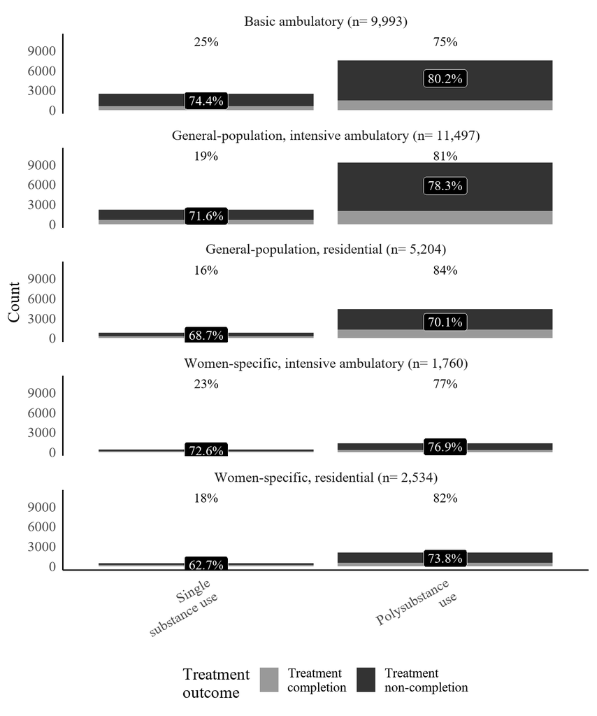

Figure 1: Percentage distribution of treatment outcomes by treatment setting and polysubstance use status

```r
ggsave("E:/Mi unidad/Alvacast/SISTRAT 2022 (github)/_proposal_grant/2023/_figs/barplot2.png", height=14*.7, width=10*.7, dpi=500)
ggsave("E:/Mi unidad/Alvacast/SISTRAT 2022 (github)/_proposal_grant/2023/_figs/barplot2.jpg", height=14*.7, width=10*.7, dpi=500)

#_#_#_#_#_#_#_#_#_#_#_#_#_#_
#
nocorr_nowgt_int2_list<-
bind_rows(
  lapply(nocorr_nowgt_int_list[1:5], function(model) {
    broom::tidy(model, exponentiate = TRUE, conf.int = TRUE) %>%
      dplyr::select(term, estimate, std.error, conf.low, conf.high, p.value) %>%
      dplyr::mutate(log_rr= log(estimate), log_lcl= log(conf.low), log_ucl= log(conf.high), variance= ((log_ucl-log_rr)/qnorm(0.975))^2)%>%
      dplyr::slice(2:3)
  }),
  .id = "model"
)

log_rr_int<- nocorr_nowgt_int2_list$log_rr
variances_int<- nocorr_nowgt_int2_list$variance


results_int <- expand.grid(i=1:5, j=1:5) %>%
  filter(i < j) %>%
  mutate(
    drrr = log_rr_int[i] - log_rr_int[j],
    var_drrr = variances_int[i] + variances_int[j],
    se_drrr = sqrt(var_drrr),
    z_value = drrr / se_drrr,
    p_value = 2 * (1 - pnorm(abs(z_value))),
    ratio_estimates = exp(drrr),
    lower_bound = exp(drrr - qnorm(0.975) * se_drrr),
    upper_bound = exp(drrr + qnorm(0.975) * se_drrr)
  ) %>%
  dplyr::mutate(i= dplyr::case_when(i==1~plan_names[1], i==2~plan_names[2],
                i==3~plan_names[3], i==4~plan_names[4], i==5~plan_names[5]),
                j= dplyr::case_when(j==1~plan_names[1], j==2~plan_names[2],
                j==3~plan_names[3], j==4~plan_names[4], j==5~plan_names[5]))
```

Time for this code chunk to run: 0.1 minutes

# Marginal probabilities

```r
df_marginal_plots<-
  cbind.data.frame(wgt= c("wgt", "iiw_nocorr_st", "iiw_nocorr_alt_st", "wgt", "iiw_after_ph_st", "iiw_after_ph_st"),
        df= c("data_mine_miss_restr_proc2exp","data_mine_miss_restr_proc2exp","data_mine_miss_restr_proc2exp","data_mine_miss_restr_proc2exp_iiw_after_ph","data_mine_miss_restr_proc2exp_iiw_after_ph","data_mine_miss_restr_proc2exp_iiw_after_ph_alt"),
        model= c("no corr no wgt","no corr main","no corr alt", "after ph no wgt", "after ph main", "after ph alt"))

# Loop over each unique plan name to fit a model
for (i in seq_along(df_marginal_plots$wgt)) {
  # Subset the data for the current plan type
  #current_data <- subset(data_mine_miss_restr_proc2, tipo_de_plan_2_mod == plan_names[i])
  geeglm( tr_outcome  ~ policonsumo2 * tipo_de_plan_2_mod +
                        edad_al_ing_1 +
                        ano_nac_corr +
                        susinidumrec_otr +
                        susinidumrec_coc +
                        susinidumrec_pbc +
                        susinidumrec_mar +
                        psycom_dum_study +
                        psycom_dum_with +
                        freq_cons_dum_5day +
                        cond_oc_dum_2inact +
                        cond_oc_dum_3unemp +
                       susprindumrec_coc +
                       susprindumrec_pbc +
                       susprindumrec_mar +
                       susprindumrec_otr,
                    id= id,
                    data= get(df_marginal_plots$df[i]) %>% dplyr::mutate(wgt=1),
                    weight= get(df_marginal_plots$df[i]) %>% dplyr::mutate(wgt=1) %>% pull(df_marginal_plots$wgt[i]),
                    family= poisson,
                    corstr= "independence") %>%
  assign(paste0("geeglm_", gsub(" ","_",df_marginal_plots$model[i])), ., envir = .GlobalEnv)
  print(message(paste0("Models: ",paste0("geeglm_", gsub(" ","_",df_marginal_plots$model[i])))))
  emmeans_response <- emmeans(get(paste0("geeglm_", gsub(" ","_",df_marginal_plots$model[i]))), ~policonsumo2+tipo_de_plan_2_mod,  rg.limit=2e5, type = "response")%>% assign(paste0("emmeans_response_", gsub(" ","_",df_marginal_plots$model[i])), ., envir = .GlobalEnv)
  print(message(paste0("Emmeans: ",paste0("emmeans_response_", gsub(" ","_",df_marginal_plots$model[i])))))
}
```

Time for this code chunk to run: 0.6 minutes

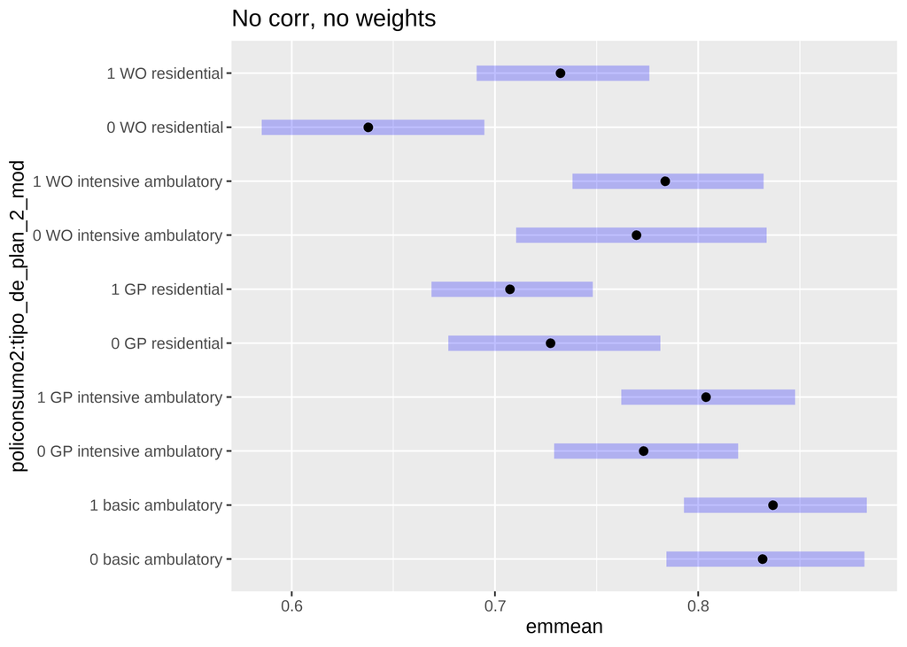

```r
plot(emmeans_response_no_corr_no_wgt)+ ggtitle("No corr, no weights")#+ geom_point(aes(x = percent, y = conc), data = pigs, pch = 2, color = "blue")
```

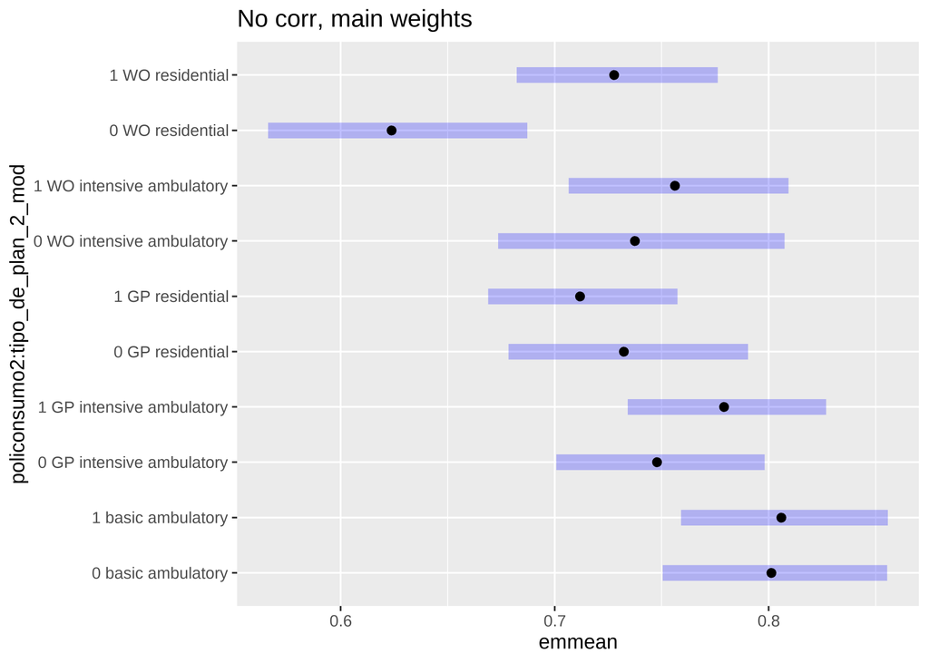

```r
plot(emmeans_response_no_corr_main)+ ggtitle("No corr, main weights")
```

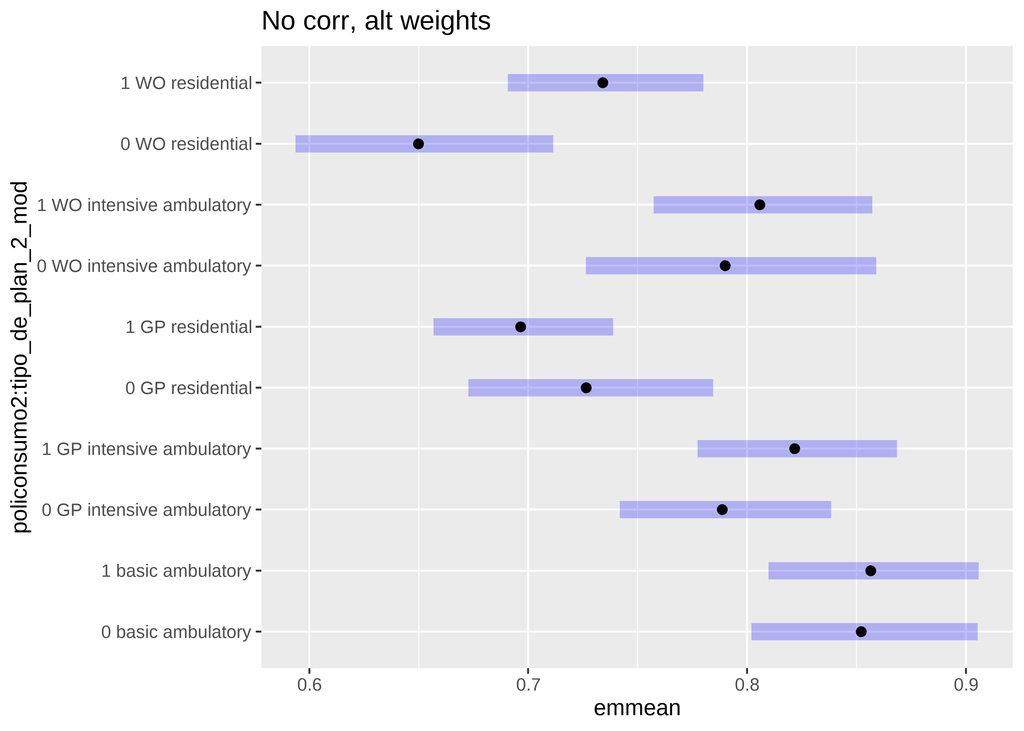

```r
plot(emmeans_response_no_corr_alt)+ ggtitle("No corr, alt weights")
```

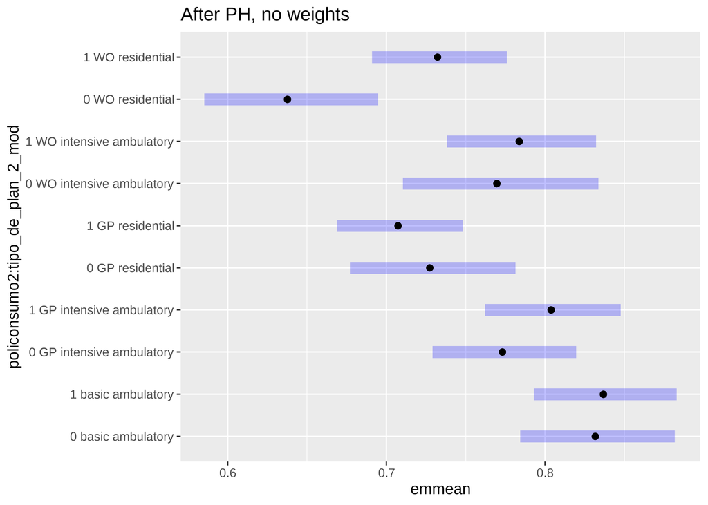

```r
plot(emmeans_response_after_ph_no_wgt)+ ggtitle("After PH, no weights")
```

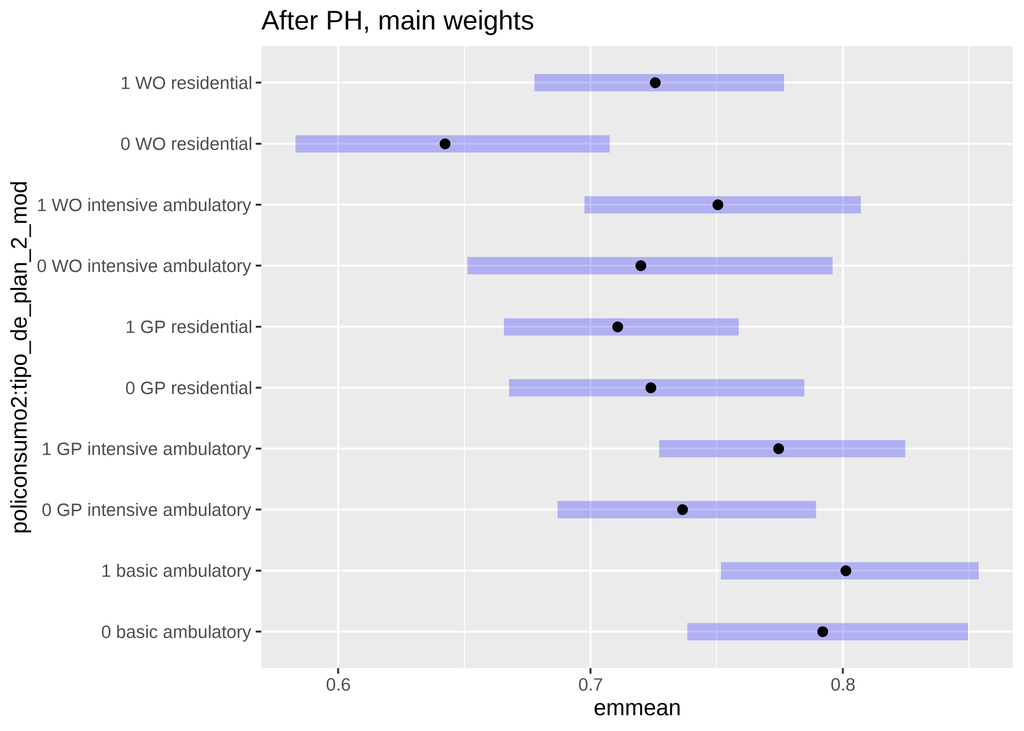

```r
plot(emmeans_response_after_ph_main)+ ggtitle("After PH, main weights")
```

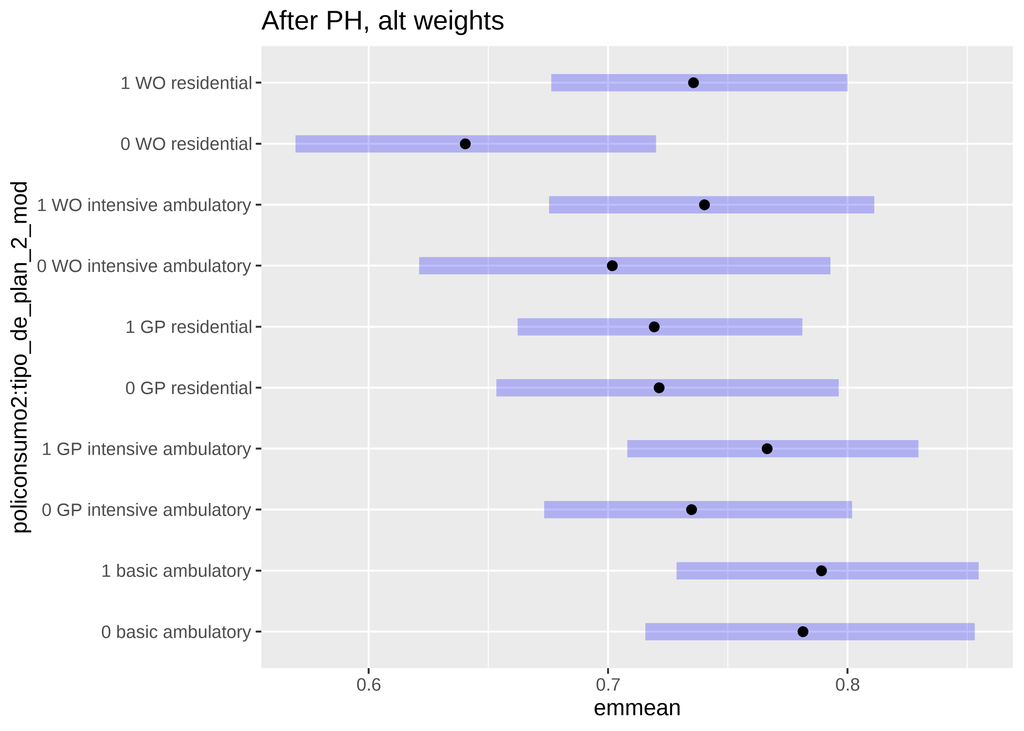

```r
plot(emmeans_response_after_ph_alt)+ ggtitle("After PH, alt weights")
```

Time for this code chunk to run: 0.4 minutes

# Heterogeneity

```r
library(meta)
try(library(dmetar))
```

```
Error in library(dmetar) : there is no package called 'dmetar'
```

```r
library(metafor)


#_#_#_#_#_#_#_#_#_#_#_#_#_#_#_#_#_#_#_#_#_#_#_#_
##_#_#_#_#_#_#_#_#_#_#_#_#_#_#_#_#_#_#_#_#_#_#_#_
##
# Define los valores de los Relative Risk Reductions (RRR) y sus intervalos de confianza
rrr <- rbind.data.frame(cbind.data.frame(setting=plan_names[1],result_data_geem_basic_ambulatory),
                 cbind.data.frame(setting=plan_names[2],result_data_geem_GP_intensive_ambulatory),
                 cbind.data.frame(setting=plan_names[3],result_data_geem_GP_residential),
                 cbind.data.frame(setting=plan_names[4],result_data_geem_WO_intensive_ambulatory),
                 cbind.data.frame(setting=plan_names[5],result_data_geem_WO_residential)
) %>%
    dplyr::group_by(setting) %>%
    dplyr::filter(model=="No time-varying coefficients, no weight") %>% pull(`Estimates`) %>% as.numeric()
lcl <- rbind.data.frame(cbind.data.frame(setting=plan_names[1],result_data_geem_basic_ambulatory),
                 cbind.data.frame(setting=plan_names[2],result_data_geem_GP_intensive_ambulatory),
                 cbind.data.frame(setting=plan_names[3],result_data_geem_GP_residential),
                 cbind.data.frame(setting=plan_names[4],result_data_geem_WO_intensive_ambulatory),
                 cbind.data.frame(setting=plan_names[5],result_data_geem_WO_residential)
) %>%
    dplyr::group_by(setting) %>%
    dplyr::filter(model=="No time-varying coefficients, no weight") %>% pull(`CI.lower`) %>% as.numeric()
ucl <- rbind.data.frame(cbind.data.frame(setting=plan_names[1],result_data_geem_basic_ambulatory),
                 cbind.data.frame(setting=plan_names[2],result_data_geem_GP_intensive_ambulatory),
                 cbind.data.frame(setting=plan_names[3],result_data_geem_GP_residential),
                 cbind.data.frame(setting=plan_names[4],result_data_geem_WO_intensive_ambulatory),
                 cbind.data.frame(setting=plan_names[5],result_data_geem_WO_residential)
) %>%
    dplyr::group_by(setting) %>%
    dplyr::filter(model=="No time-varying coefficients, no weight") %>% pull(`CI.upper`) %>% as.numeric()


# Calcula los logaritmos de los RRR y de los límites de sus intervalos de confianza
log_rrr <- log(rrr)
log_lcl <- log(lcl)
log_ucl <- log(ucl)

# Calcula las varianzas
variances <- ((log_ucl - log_rrr) / qnorm(0.975))^2

# Meta-análisis usando un modelo de efectos aleatorios
meta_analysis <- rma(yi=log_rrr, sei=sqrt(variances), method="REML")

# Prueba de Cochran Q para evaluar la heterogeneidad
cochrans_q <- meta_analysis$QE
p_value_q <- meta_analysis$QEp

cat(sprintf("No time-varying coefficients, no weight- Cochran's Q = %.2f, p-value = %.4f\n", cochrans_q, p_value_q))
```

```
No time-varying coefficients, no weight- Cochran's Q = 14.49, p-value = 0.0059
```

```r
#concuerda con el calculo de stata
#
#

#_#_#_#_#_#_#_#_#_#_#_#_#_#_#_#_#_#_#_#_#_#_#_#_#_#_#_#_#_#_#_#_#_#_#_#_
##_#_#_#_#_#_#_#_#_#_#_#_#_#_#_#_#_#_#_#_#_#_#_#_#_#_#_#_#_#_#_#_#_#_#_#_
###_#_#_#_#_#_#_#_#_#_#_#_#_#_#_#_#_#_#_#_#_#_#_#_#_#_#_#_#_#_#_#_#_#_#_#_
###
###

# Define los valores de los Relative Risk Reductions (RRR) y sus intervalos de confianza
rrr2 <- rbind.data.frame(cbind.data.frame(setting=plan_names[1],result_data_geem_basic_ambulatory),
                         cbind.data.frame(setting=plan_names[2],result_data_geem_GP_intensive_ambulatory),
                         cbind.data.frame(setting=plan_names[3],result_data_geem_GP_residential),
                         cbind.data.frame(setting=plan_names[4],result_data_geem_WO_intensive_ambulatory),
                         cbind.data.frame(setting=plan_names[5],result_data_geem_WO_residential)
) %>%
    dplyr::group_by(setting) %>%
    dplyr::filter(model=="No time-varying coefficients, lag=0") %>% pull(`Estimates`) %>% as.numeric()
lcl2 <- rbind.data.frame(cbind.data.frame(setting=plan_names[1],result_data_geem_basic_ambulatory),
                         cbind.data.frame(setting=plan_names[2],result_data_geem_GP_intensive_ambulatory),
                         cbind.data.frame(setting=plan_names[3],result_data_geem_GP_residential),
                         cbind.data.frame(setting=plan_names[4],result_data_geem_WO_intensive_ambulatory),
                         cbind.data.frame(setting=plan_names[5],result_data_geem_WO_residential)
) %>%
    dplyr::group_by(setting) %>%
    dplyr::filter(model=="No time-varying coefficients, lag=0") %>% pull(`CI.lower`) %>% as.numeric()
ucl2 <- rbind.data.frame(cbind.data.frame(setting=plan_names[1],result_data_geem_basic_ambulatory),
                         cbind.data.frame(setting=plan_names[2],result_data_geem_GP_intensive_ambulatory),
                         cbind.data.frame(setting=plan_names[3],result_data_geem_GP_residential),
                         cbind.data.frame(setting=plan_names[4],result_data_geem_WO_intensive_ambulatory),
                         cbind.data.frame(setting=plan_names[5],result_data_geem_WO_residential)
) %>%
    dplyr::group_by(setting) %>%
    dplyr::filter(model=="No time-varying coefficients, lag=0") %>% pull(`CI.upper`) %>% as.numeric()


# Calcula los logaritmos de los RRR y de los límites de sus intervalos de confianza
log_rrr2 <- log(rrr2)
log_lcl2 <- log(lcl2)
log_ucl2 <- log(ucl2)

# Calcula las varianzas
variances2 <- ((log_ucl2 - log_rrr2) / qnorm(0.975))^2

# Meta-análisis usando un modelo de efectos aleatorios
meta_analysis2 <- rma(yi=log_rrr2, sei=sqrt(variances2), method="REML")

# Prueba de Cochran Q para evaluar la heterogeneidad
cochrans_q2 <- meta_analysis2$QE
p_value_q2 <- meta_analysis2$QEp

cat(sprintf("No time-varying coefficients, lag=0, main- Cochran's Q = %.2f, p-value = %.4f\n", cochrans_q2, p_value_q2))
```

```
No time-varying coefficients, lag=0, main- Cochran's Q = 13.32, p-value = 0.0098
```

```r
#_#_#_#_#_#_#_#_#_#_#_#_#_#_#_#_#_#_#_#_#_#_#_#_#_#_#_#_#_#_#_#_#_#_#_#_
##_#_#_#_#_#_#_#_#_#_#_#_#_#_#_#_#_#_#_#_#_#_#_#_#_#_#_#_#_#_#_#_#_#_#_#_
###_#_#_#_#_#_#_#_#_#_#_#_#_#_#_#_#_#_#_#_#_#_#_#_#_#_#_#_#_#_#_#_#_#_#_#_

# Define los valores de los Relative Risk Reductions (RRR) y sus intervalos de confianza
rrr3 <- rbind.data.frame(cbind.data.frame(setting=plan_names[1],result_data_geem_basic_ambulatory),
                 cbind.data.frame(setting=plan_names[2],result_data_geem_GP_intensive_ambulatory),
                 cbind.data.frame(setting=plan_names[3],result_data_geem_GP_residential),
                 cbind.data.frame(setting=plan_names[4],result_data_geem_WO_intensive_ambulatory),
                 cbind.data.frame(setting=plan_names[5],result_data_geem_WO_residential)
) %>%
    dplyr::group_by(setting) %>%
    dplyr::filter(model=="No time-varying coefficients, lag=1") %>% pull(`Estimates`) %>% as.numeric()
lcl3 <- rbind.data.frame(cbind.data.frame(setting=plan_names[1],result_data_geem_basic_ambulatory),
                 cbind.data.frame(setting=plan_names[2],result_data_geem_GP_intensive_ambulatory),
                 cbind.data.frame(setting=plan_names[3],result_data_geem_GP_residential),
                 cbind.data.frame(setting=plan_names[4],result_data_geem_WO_intensive_ambulatory),
                 cbind.data.frame(setting=plan_names[5],result_data_geem_WO_residential)
) %>%
    dplyr::group_by(setting) %>%
    dplyr::filter(model=="No time-varying coefficients, lag=1") %>% pull(`CI.lower`) %>% as.numeric()
ucl3 <- rbind.data.frame(cbind.data.frame(setting=plan_names[1],result_data_geem_basic_ambulatory),
                 cbind.data.frame(setting=plan_names[2],result_data_geem_GP_intensive_ambulatory),
                 cbind.data.frame(setting=plan_names[3],result_data_geem_GP_residential),
                 cbind.data.frame(setting=plan_names[4],result_data_geem_WO_intensive_ambulatory),
                 cbind.data.frame(setting=plan_names[5],result_data_geem_WO_residential)
) %>%
    dplyr::group_by(setting) %>%
    dplyr::filter(model=="No time-varying coefficients, lag=1") %>% pull(`CI.upper`) %>% as.numeric()


# Calcula los logaritmos de los RRR y de los límites de sus intervalos de confianza
log_rrr3 <- log(rrr3)
log_lcl3 <- log(lcl3)
log_ucl3 <- log(ucl3)

# Calcula las varianzas
variances3 <- ((log_ucl3 - log_rrr3) / qnorm(0.975))^2

# Meta-análisis usando un modelo de efectos aleatorios
meta_analysis3 <- rma(yi=log_rrr3, sei=sqrt(variances3), method="REML")

# Prueba de Cochran Q para evaluar la heterogeneidad
cochrans_q3 <- meta_analysis3$QE
p_value_q3 <- meta_analysis3$QEp

cat(sprintf("No time-varying coefficients, lag=1- Cochran's Q = %.2f, p-value = %.4f\n", cochrans_q3, p_value_q3))
```

```
No time-varying coefficients, lag=1- Cochran's Q = 14.24, p-value = 0.0066
```

```r
#_#_#_#_#_#_#_#_#_#_#_#_#_#_#_#_#_#_#_#_
##_#_#_#_#_#_#_#_#_#_#_#_#_#_#_#_#_#_#_#_#_#_#_#_
###_#_#_#_#_#_#_#_#_#_#_#_#_#_#_#_#_#_#_#_#_#_#_#_#_#_#_#_
###

# Comparaciones de Altman para todas las combinaciones de RRR
results <- expand.grid(i=1:5, j=1:5) %>%
  filter(i < j) %>%
  mutate(
    drrr = log_rrr[i] - log_rrr[j],
    var_drrr = variances[i] + variances[j],
    se_drrr = sqrt(var_drrr),
    z_value = drrr / se_drrr,
    p_value = 2 * (1 - pnorm(abs(z_value))),
    ratio_estimates = exp(drrr),
    lower_bound = exp(drrr - qnorm(0.975) * se_drrr),
    upper_bound = exp(drrr + qnorm(0.975) * se_drrr)
  ) %>%
  dplyr::mutate(i= dplyr::case_when(i==1~plan_names[1], i==2~plan_names[2], i==3~plan_names[3], i==4~plan_names[4], i==5~plan_names[5]), j= dplyr::case_when(j==1~plan_names[1], j==2~plan_names[2], j==3~plan_names[3], j==4~plan_names[4], j==5~plan_names[5]))

results2 <- expand.grid(i=1:5, j=1:5) %>%
  filter(i < j) %>%
  mutate(
    drrr = log_rrr2[i] - log_rrr2[j],
    var_drrr = variances2[i] + variances2[j],
    se_drrr = sqrt(var_drrr),
    z_value = drrr / se_drrr,
    p_value = 2 * (1 - pnorm(abs(z_value))),
    ratio_estimates = exp(drrr),
    lower_bound = exp(drrr - qnorm(0.975) * se_drrr),
    upper_bound = exp(drrr + qnorm(0.975) * se_drrr)
  ) %>%
  dplyr::mutate(i= dplyr::case_when(i==1~plan_names[1], i==2~plan_names[2], i==3~plan_names[3], i==4~plan_names[4], i==5~plan_names[5]), j= dplyr::case_when(j==1~plan_names[1], j==2~plan_names[2], j==3~plan_names[3], j==4~plan_names[4], j==5~plan_names[5]))

results3 <- expand.grid(i=1:5, j=1:5) %>%
  filter(i < j) %>%
  mutate(
    drrr = log_rrr3[i] - log_rrr3[j],
    var_drrr = variances3[i] + variances3[j],
    se_drrr = sqrt(var_drrr),
    z_value = drrr / se_drrr,
    p_value = 2 * (1 - pnorm(abs(z_value))),
    ratio_estimates = exp(drrr),
    lower_bound = exp(drrr - qnorm(0.975) * se_drrr),
    upper_bound = exp(drrr + qnorm(0.975) * se_drrr)
  ) %>%
  dplyr::mutate(i= dplyr::case_when(i==1~plan_names[1], i==2~plan_names[2], i==3~plan_names[3], i==4~plan_names[4], i==5~plan_names[5]), j= dplyr::case_when(j==1~plan_names[1], j==2~plan_names[2], j==3~plan_names[3], j==4~plan_names[4], j==5~plan_names[5]))

# Imprime los resultados
#el 5 tiene el mayor efecto en omparación con el resto
#
bind_rows(cbind.data.frame(model= "No time-varying coefficients, no weight",results),
                 cbind.data.frame(model= "No time-varying coefficients, lag=0",results2),
                 cbind.data.frame(model= "No time-varying coefficients, lag=1",results3)
                 ) %>%
  dplyr::mutate(across(c("drrr","var_drrr", "se_drrr", "z_value", "ratio_estimates", "lower_bound", "upper_bound"),~sprintf("%1.2f",.))) %>%
  dplyr::mutate(across(c("p_value"),~sprintf("%1.4f",.))) %>%
  dplyr::mutate(`rrr (95% IC)`= paste0(ratio_estimates, " (", lower_bound, ", ", upper_bound,")")) %>%
  dplyr::select(-any_of(c("drrr", "var_drrr", "se_drrr", "z_value", "ratio_estimates", "lower_bound", "upper_bound"))) %>%
  {
  #copiar_nombres2()
    write.table(., file = paste0(folder_path,"rr_contrasts_240625.csv"), dec=",", sep="\t")
    knitr::kable(., size=10, format="html", caption="GEE Models, Heterogeneity & contrasts by setting") %>%
     kableExtra::kable_styling(bootstrap_options = c("striped", "hover"),font_size = 12) %>%
     kableExtra::scroll_box(width = "100%", height = "375px")
  }
```

GEE Models, Heterogeneity & contrasts by setting

| model | i | j | p_value | rrr (95% IC) |
| --- | --- | --- | --- | --- |
| No time-varying coefficients, no weight | basic ambulatory | GP intensive ambulatory | 0.5812 | 0.99 (0.96, 1.02) |
| No time-varying coefficients, no weight | basic ambulatory | GP residential | 0.0288 | 1.06 (1.01, 1.12) |
| No time-varying coefficients, no weight | GP intensive ambulatory | GP residential | 0.0180 | 1.07 (1.01, 1.14) |
| No time-varying coefficients, no weight | basic ambulatory | WO intensive ambulatory | 0.2098 | 1.04 (0.98, 1.11) |
| No time-varying coefficients, no weight | GP intensive ambulatory | WO intensive ambulatory | 0.1395 | 1.05 (0.98, 1.12) |
| No time-varying coefficients, no weight | GP residential | WO intensive ambulatory | 0.6052 | 0.98 (0.91, 1.06) |
| No time-varying coefficients, no weight | basic ambulatory | WO residential | 0.0112 | 0.90 (0.84, 0.98) |
| No time-varying coefficients, no weight | GP intensive ambulatory | WO residential | 0.0266 | 0.91 (0.84, 0.99) |
| No time-varying coefficients, no weight | GP residential | WO residential | 0.0005 | 0.85 (0.78, 0.93) |
| No time-varying coefficients, no weight | WO intensive ambulatory | WO residential | 0.0040 | 0.87 (0.79, 0.96) |
| No time-varying coefficients, lag=0 | basic ambulatory | GP intensive ambulatory | 0.4239 | 0.98 (0.94, 1.03) |
| No time-varying coefficients, lag=0 | basic ambulatory | GP residential | 0.0895 | 1.05 (0.99, 1.11) |
| No time-varying coefficients, lag=0 | GP intensive ambulatory | GP residential | 0.0298 | 1.07 (1.01, 1.14) |
| No time-varying coefficients, lag=0 | basic ambulatory | WO intensive ambulatory | 0.4805 | 1.03 (0.95, 1.12) |
| No time-varying coefficients, lag=0 | GP intensive ambulatory | WO intensive ambulatory | 0.2636 | 1.05 (0.96, 1.15) |
| No time-varying coefficients, lag=0 | GP residential | WO intensive ambulatory | 0.6656 | 0.98 (0.89, 1.07) |
| No time-varying coefficients, lag=0 | basic ambulatory | WO residential | 0.0077 | 0.89 (0.81, 0.97) |
| No time-varying coefficients, lag=0 | GP intensive ambulatory | WO residential | 0.0313 | 0.90 (0.83, 0.99) |
| No time-varying coefficients, lag=0 | GP residential | WO residential | 0.0006 | 0.84 (0.77, 0.93) |
| No time-varying coefficients, lag=0 | WO intensive ambulatory | WO residential | 0.0100 | 0.86 (0.77, 0.96) |
| No time-varying coefficients, lag=1 | basic ambulatory | GP intensive ambulatory | 0.3486 | 0.98 (0.94, 1.02) |
| No time-varying coefficients, lag=1 | basic ambulatory | GP residential | 0.0397 | 1.07 (1.00, 1.15) |
| No time-varying coefficients, lag=1 | GP intensive ambulatory | GP residential | 0.0086 | 1.09 (1.02, 1.17) |
| No time-varying coefficients, lag=1 | basic ambulatory | WO intensive ambulatory | 0.4305 | 1.03 (0.96, 1.11) |
| No time-varying coefficients, lag=1 | GP intensive ambulatory | WO intensive ambulatory | 0.1919 | 1.05 (0.98, 1.13) |
| No time-varying coefficients, lag=1 | GP residential | WO intensive ambulatory | 0.3783 | 0.96 (0.88, 1.05) |
| No time-varying coefficients, lag=1 | basic ambulatory | WO residential | 0.0143 | 0.90 (0.83, 0.98) |
| No time-varying coefficients, lag=1 | GP intensive ambulatory | WO residential | 0.0466 | 0.92 (0.85, 1.00) |
| No time-varying coefficients, lag=1 | GP residential | WO residential | 0.0005 | 0.84 (0.76, 0.93) |
| No time-varying coefficients, lag=1 | WO intensive ambulatory | WO residential | 0.0116 | 0.88 (0.79, 0.97) |

Time for this code chunk to run: 0 minutes

# Session info

```r
message(paste0("R library: ", Sys.getenv("R_LIBS_USER")))
```

R library: E:/Mi unidad/Alvacast/SISTRAT 2022 (github)/renv/library/R-4.1/x86_64-w64-mingw32

```r
message(paste0("Date: ",withr::with_locale(new = c('LC_TIME' = 'C'), code =Sys.time())))
```

Date: 2024-08-07 18:23:14

```r
message(paste0("Editor context: ", path))
```

Editor context: C:/Users/CISS Fondecyt/Mi unidad/Alvacast/SISTRAT 2022 (github)/env

Time for this code chunk to run: 0 minutes

```r
sesion_info <- devtools::session_info()
dplyr::select(
  tibble::as_tibble(sesion_info$packages),
  c(package, loadedversion, source)
) %>%
 knitr::kable(caption = "R packages", format = "html",
      col.names = c("Row number", "Package", "Version"),
    row.names = FALSE,
      align = c("c", "l", "r")) %>%
  kableExtra::kable_styling(bootstrap_options = c("striped", "hover"),font_size = 12) %>%
  kableExtra::scroll_box(width = "100%", height = "375px")
```

R packages

| Row number | Package | Version |
| --- | --- | --- |
| assertthat | 0.2.1 | CRAN (R 4.1.2) |
| backports | 1.4.1 | CRAN (R 4.1.2) |
| base64enc | 0.1-3 | CRAN (R 4.1.1) |
| BiocManager | 1.30.18 | CRAN (R 4.1.3) |
| biostat3 | 0.1.8 | CRAN (R 4.1.3) |
| boot | 1.3-28.1 | CRAN (R 4.1.3) |
| broom | 1.0.1 | CRAN (R 4.1.3) |
| cachem | 1.0.6 | CRAN (R 4.1.2) |
| callr | 3.7.2 | CRAN (R 4.1.3) |
| cellranger | 1.1.0 | CRAN (R 4.1.2) |
| checkmate | 2.1.0 | CRAN (R 4.1.3) |
| class | 7.3-20 | CRAN (R 4.1.3) |
| cli | 3.4.1 | CRAN (R 4.1.3) |
| clipr | 0.8.0 | CRAN (R 4.1.2) |
| clisymbols | 1.2.0 | CRAN (R 4.1.3) |
| cluster | 2.1.4 | CRAN (R 4.1.3) |
| coda | 0.19-4 | CRAN (R 4.1.2) |
| codetools | 0.2-19 | CRAN (R 4.1.3) |
| colorspace | 2.0-3 | CRAN (R 4.1.2) |
| CompQuadForm | 1.4.3 | CRAN (R 4.1.1) |
| cowplot | 1.1.1 | CRAN (R 4.1.2) |
| crayon | 1.5.2 | CRAN (R 4.1.3) |
| data.table | 1.14.2 | CRAN (R 4.1.2) |
| data.tree | 1.0.0 | CRAN (R 4.1.3) |
| DBI | 1.1.3 | CRAN (R 4.1.3) |
| dbplyr | 2.2.1 | CRAN (R 4.1.3) |
| deldir | 1.0-6 | CRAN (R 4.1.1) |
| devtools | 2.4.4 | CRAN (R 4.1.3) |
| digest | 0.6.29 | CRAN (R 4.1.3) |
| dplyr | 1.0.10 | CRAN (R 4.1.3) |

[output cut: 159 more lines]

Time for this code chunk to run: 0.3 minutes

```r
reticulate::py_list_packages()%>%
 knitr::kable(caption = "Python packages", format = "html",
      col.names = c("Package", "Version", "Requirement"),
    row.names = FALSE,
      align = c("c", "l", "r", "r"))%>%
  kableExtra::kable_styling(bootstrap_options = c("striped", "hover"),font_size = 12) %>%
  kableExtra::scroll_box(width = "100%", height = "375px")
```

Python packages

| Package | Version | Requirement |
| --- | --- | --- |
| absl-py | 2.1.0 | absl-py==2.1.0 |
| asttokens | 2.4.1 | asttokens==2.4.1 |
| astunparse | 1.6.3 | astunparse==1.6.3 |
| audioconverter | 2.0.3 | audioconverter==2.0.3 |
| autograd | 1.6.2 | autograd==1.6.2 |
| autograd-gamma | 0.5.0 | autograd-gamma==0.5.0 |
| beautifulsoup4 | 4.12.3 | beautifulsoup4==4.12.3 |
| Brotli | 1.1.0 | Brotli==1.1.0 |
| certifi | 2023.11.17 | certifi==2023.11.17 |
| cffi | 1.16.0 | cffi==1.16.0 |
| charset-normalizer | 3.3.2 | charset-normalizer==3.3.2 |
| clarabel | 0.9.0 | clarabel==0.9.0 |
| click | 8.1.7 | click==8.1.7 |
| cloudpickle | 3.0.0 | cloudpickle==3.0.0 |
| colorama | 0.4.6 | colorama==0.4.6 |
| comm | 0.2.1 | comm==0.2.1 |
| contourpy | 1.2.0 | contourpy==1.2.0 |
| cvxopt | 1.3.2 | cvxopt==1.3.2 |
| cvxpy | 1.5.2 | cvxpy==1.5.2 |
| cycler | 0.12.1 | cycler==0.12.1 |
| debugpy | 1.8.0 | debugpy==1.8.0 |
| decorator | 4.4.2 | decorator==4.4.2 |
| delete-chrome-history-py | 0.1.8 | delete-chrome-history-py==0.1.8 |
| easyocr | 1.7.1 | easyocr==1.7.1 |
| ecos | 2.0.13 | ecos==2.0.13 |
| editdistance | 0.8.1 | editdistance==0.8.1 |
| efficientnet | 1.0.0 | efficientnet==1.0.0 |
| essential-generators | 1.0 | essential-generators==1.0 |
| et-xmlfile | 1.1.0 | et-xmlfile==1.1.0 |
| executing | 2.0.1 | executing==2.0.1 |

[output cut: 153 more lines]

Time for this code chunk to run: 0 minutes

# Output

```r
invisible("Adicionales en E:/Mi unidad/Alvacast/SISTRAT 2022 (github)/_proposal_grant/2023/para_pres_cum_mean.R")
folder_path <- ifelse(dir.exists("E:/Mi unidad/Alvacast/SISTRAT 2022 (github)/_proposal_grant/2023/"),
                      "E:/Mi unidad/Alvacast/SISTRAT 2022 (github)/_proposal_grant/2023/",
                      "C:/Users/CISS Fondecyt/Mi unidad/Alvacast/SISTRAT 2022 (github)/_proposal_grant/2023/")
save.image(paste0(folder_path,"an_grant_23_24_4.RData"))
```

Time for this code chunk to run: 0.1 minutes